# **Raquel Marques - Projeto de Séries Temporais**

**Projeto de Previsão de Vendas: Previsão de Demanda Diária de Departamento Varejista**

Última Atualização: 2026-08-02

Legenda:

- Explicação: Fornece raciocínio detalhado ou contexto para conceitos e processos.
- Dicas: Oferece conselhos práticos ou melhores práticas para melhorar a eficiência ou os resultados.
- Prática: Destaca passos acionáveis ou exercícios para aplicar os conceitos.
- Contexto de Negócio: Conecta o trabalho técnico a objetivos ou cenários de negócio relevantes.

# Sumário

**Parte 0: Setup**

- Visão Geral do Projeto e Contexto de Negócio
- Configuração e Carregamento de Dados
- Funções Auxiliares

**Parte 1: Análise Exploratória de Dados e Preparação dos Dados**

- Dicionário de Dados e Limpeza
- Escolha do Departamento e Agregação ao Nível Diário
- Regras de Negócio derivadas para períodos futuros (`isClosed`, `Pagamento`, `Vale`)

**Parte 2: Análise de Séries Temporais**

- Passo A: Análise Visual da Série
- Passo B: Divisão Treino / Holdout
- Passo C: Verificação de Ruído Branco
- Passo D: Verificação de Estacionariedade
- Passo E: Identificação de Componentes (tendência, sazonalidade, ciclo)
- Passo F: Ajuste de Modelos
  - F1: Suavização Exponencial
  - F2: ARIMA / SARIMA (identificação, estimação, variáveis exógenas, coeficientes)
- Passo G: Seleção do Melhor Modelo
- Passo H: Diagnóstico de Resíduos
- Passo I: Métricas de Erro no Holdout
- Passo J: Previsão para os Próximos Períodos

**Parte 3: Conclusões**

- Recomendações de Negócio e Próximos Passos
- Conclusão

# 🔹**PARTE 0**: Setup

## 🔸Visão Geral do Projeto e Contexto de Negócio

### Problema de Negócio

No setor varejista competitivo, a previsão precisa de vendas diárias é crucial para otimizar níveis de estoque, dimensionamento de equipe e fluxo de caixa. A organização atualmente enfrenta desafios com rupturas de estoque e excesso de estoque devido a previsões imprecisas de demanda.

### Objetivos do Projeto

- Desenvolver um modelo robusto de previsão de séries temporais para vendas diárias de um departamento varejista específico
- Identificar os principais padrões (tendência, sazonalidade, ciclos) que impulsionam as vendas
- Gerar uma previsão de vendas de 30 dias para março de 2021
- Fornecer insights de negócio acionáveis com base em análise orientada por dados

### Descrição dos Dados

- Fonte: `Vendas_ASN.csv` (da plataforma ASN Jedi)
- Variável Alvo: `Vendas` (Vendas) - Departamento 2 ou 4
- Período: Dados diários, Treinamento: até `Dec/2020`, Holdout: `Jan-Feb/2021`
- Principais Características:
  - Variáveis de tempo: `Data` (Data), `Dia_da_semana` (Dia da Semana), `Dia` (Dia), `Mes` (Mês), `Ano` (Ano)
  - Categóricas: `Empresa` (Empresa), `Departamento` (Departamento), `Secao` (Seção)
  - Exógenas: `Feriado` (Feriado), `Pagamento` (Dia de Pagamento), `Vale` (Dia de Vale)

### Impacto no Negócio

- **Redução de Custos de Estoque**: 15-20% potencial de redução no excesso de estoque
- **Aumento de Receita**: Minimização de vendas perdidas por ruptura de estoque
- **Eficiência Operacional**: Melhor escala de mão de obra alinhada aos padrões de demanda

## 🔸Configuração e Carregamento de Dados

### Importação de Bibliotecas

```python
# BIBLIOTECAS
import os
import pandas as pd
import numpy as np
import seaborn as sns
import matplotlib.pyplot as plt

# Importações específicas de séries temporais
from statsmodels.graphics.tsaplots import plot_acf, plot_pacf
from statsmodels.tsa.seasonal import seasonal_decompose
import matplotlib.dates as mdates

from scipy.stats import mannwhitneyu, kruskal

from statsmodels.stats.diagnostic import acorr_ljungbox
from statsmodels.tsa.stattools import adfuller

from statsmodels.tsa.holtwinters import SimpleExpSmoothing, Holt, ExponentialSmoothing
from statsmodels.stats.diagnostic import acorr_ljungbox

import statsmodels.api as sm
import itertools
import warnings

from sklearn.metrics import mean_absolute_error, mean_squared_error
from scipy.stats import shapiro, jarque_bera
```

```python
## CAMINHO
main_dir = os.path.join(os.path.expanduser("~"),
                           "OneDrive",
                           "Project_Code")

project_dir = os.path.join(main_dir,
                           "ASN-DSA-T5",
                           "33-ST",
                           "Homework")
```

### Carregar Dataset

```python
# Dataset de feriados
df_holiday = pd.read_csv(os.path.join(project_dir, "data", "holidays.csv"))
```

```python
df = pd.read_csv(os.path.join(project_dir, "data", "Vendas ASN_Dados_Finais.csv"))
```

```python
# Explorar a estrutura do dataset
print("Formato do Dataset:", df.shape)
df.head()
df.info()
df.describe()
```

```
Formato do Dataset: (307015, 13)
<class 'pandas.core.frame.DataFrame'>
RangeIndex: 307015 entries, 0 to 307014
Data columns (total 13 columns):
 #   Column         Non-Null Count   Dtype
---  ------         --------------   -----
 0   Data           307015 non-null  object
 1   Data_new       307015 non-null  object
 2   Dia_da_semana  307015 non-null  int64
 3   Dia            307015 non-null  int64
 4   Mes            307015 non-null  int64
 5   Ano            307015 non-null  int64
 6   Empresa        307015 non-null  int64
 7   Feriado        307015 non-null  int64
 8   Pagamento      307015 non-null  int64
 9   Vale           307015 non-null  int64
 10  Vendas         307015 non-null  object
 11  Departamento   307015 non-null  object
 12  Seção          307015 non-null  object
dtypes: int64(8), object(5)
memory usage: 30.5+ MB
```

|  | Dia_da_semana | Dia | Mes | Ano | Empresa | Feriado | Pagamento | Vale |
| --- | --- | --- | --- | --- | --- | --- | --- | --- |
| count | 307015.000000 | 307015.000000 | 307015.000000 | 307015.000000 | 307015.000000 | 307015.000000 | 307015.000000 | 307015.000000 |
| mean | 4.141765 | 15.759302 | 6.341338 | 2019.172109 | 11.208794 | 0.025712 | 0.034790 | 0.034757 |
| std | 1.947121 | 8.754115 | 3.551850 | 0.913172 | 6.666851 | 0.158275 | 0.183247 | 0.183165 |
| min | 1.000000 | 1.000000 | 1.000000 | 2018.000000 | 1.000000 | 0.000000 | 0.000000 | 0.000000 |
| 25% | 2.000000 | 8.000000 | 3.000000 | 2018.000000 | 5.000000 | 0.000000 | 0.000000 | 0.000000 |
| 50% | 4.000000 | 16.000000 | 6.000000 | 2019.000000 | 12.000000 | 0.000000 | 0.000000 | 0.000000 |
| 75% | 6.000000 | 23.000000 | 9.000000 | 2020.000000 | 16.000000 | 0.000000 | 0.000000 | 0.000000 |
| max | 7.000000 | 31.000000 | 12.000000 | 2021.000000 | 23.000000 | 1.000000 | 1.000000 | 1.000000 |

## 🔸Funções Auxiliares

- `univariate_numeric_variable(data, variable)`
- `univariate_categorical_variable(data, variable)`
- `numeric_variable_analysis_percentile`

```python
def univariate_numeric_variable(data, variable):
    """
    Generates a matrix of charts (2x2) for a numeric continuous variable.

    [1,1] Histogram
    [1,2] Violin Plot
    [2,1] Box plot
    [2,2] Box plot with points overlaid

    Above the charts, shows a table with the variable descriptive statistics.

    Parameters:
        data (pd.DataFrame): Database containing the variable.
        variable (str): Name of the variable to be analysed.

    Returns:
        None

    Usage example:
        >> data = pd.DataFrame({"example_variable": np.random.normal(loc=50, scale=10, size=100)})
        >>univariate_numeric_variable(data, "example_variable")

    """

    # Calculate descriptive statistics
    desc_stats = data[variable].describe().to_frame().T
    desc_stats = desc_stats.round(4)  # Limit to 4 decimal places

    # Configuration of subplots
    fig = plt.figure(figsize=(8, 6))
    fig.suptitle(f"Analysing: {variable}", fontsize=16, y=0.98)

    # Add table on the top
    ax_table = plt.subplot2grid((3, 2), (0, 0), colspan=2)
    ax_table.axis("off")
    table = ax_table.table(cellText=desc_stats.values,
                           colLabels=desc_stats.columns,
                           rowLabels=desc_stats.index,
                           cellLoc="center",
                           loc="center",
                           bbox=[0, 0, 1, 1])
    table.auto_set_font_size(False)
    table.set_fontsize(10)
    table.auto_set_column_width(col=list(range(len(desc_stats.columns))))

    # Add padding by scaling the table
    table.scale(1.2, 1.8)  # Adjust these values for horizontal/vertical padding

    # [1,1] Histogram
    ax1 = plt.subplot2grid((3, 2), (1, 0))
    sns.histplot(data[variable], kde=True, ax=ax1, color="skyblue")
    ax1.set_title("Histogram", fontsize=12)
    ax1.set_xlabel(variable)

    # [1,2] Violin Chart
    ax2 = plt.subplot2grid((3, 2), (1, 1), sharex=ax1)
    sns.violinplot(x=data[variable], ax=ax2, color="lightgreen")
    ax2.set_title("Violin Chart", fontsize=12)
    ax2.set_xlabel(variable)

    # [2,1] Box plot
    ax3 = plt.subplot2grid((3, 2), (2, 0), sharex=ax1)
    sns.boxplot(x=data[variable], ax=ax3, color="orange")
    ax3.set_title("Box plot", fontsize=12)
    ax3.set_xlabel(variable)

    # [2,2] Box plot with points overlaid
    ax4 = plt.subplot2grid((3, 2), (2, 1), sharex=ax1)
    sns.boxplot(x=data[variable], ax=ax4, color="lightcoral")
    sns.stripplot(x=data[variable], ax=ax4, color="black", alpha=0.5, jitter=True)
    ax4.set_title("Box plot with points", fontsize=12)
    ax4.set_xlabel(variable)

    # Final Adjustments
    plt.tight_layout(rect=[0, 0, 1, 0.96])
    plt.show()

def univariate_categorical_variable(data, variable):
    """
    Analyse categorical variable.

    1. Returns transposed describe function in a table format.
    2. Returns a table with level frequency (including percentage and total).
    3. Plot a bar chart with frequency and show values on top.

    Parameters:
        data (pd.DataFrame): Database containing the variable.
        variable (str): Name of the variable to be analysed.

    Returns:
        None

    Usage example:
        >>> import pandas as pd
        >>> df = pd.DataFrame({'Caregory': ['A', 'B', 'A', 'C', 'B', 'A', 'C', 'C', 'A', 'B']})
        >>> univariate_categorical_variable(df, 'Caregory')
    """
    # Verify if variable is on the dataframe
    if variable not in data.columns:
        raise ValueError(f"Variable '{variable}' is not in the DataFrame.")

    # 1. Transposed and formated describe
    describe_table = data[variable].describe().to_frame()
    describe_table = describe_table.T
    describe_table.index = [variable]

    # Show formated table
    print("Categorical variable describe:")
    display(describe_table)

    # 2. Frequency of each level (percentage and total)
    frequency_table = data[variable].value_counts().reset_index()
    frequency_table.columns = [variable, 'Frequency']
    frequency_table['Percentage (%)'] = (frequency_table['Frequency'] / len(data) * 100).round(2)

    # Add line for total
    total_row = pd.DataFrame({
        variable: ['Total'],
        'Frequency': [frequency_table['Frequency'].sum()],
        'Percentage (%)': [100.0]
    })
    frequency_table = pd.concat([frequency_table, total_row], ignore_index=True)

    # Show formated table
    print("Frequency table of categorical variable (with percentage and total):")
    display(frequency_table)

    # 3. Frequency bar chart
    plt.figure(figsize=(8, 5))
    ax = sns.barplot(x=variable, y='Frequency', data=frequency_table[:-1], errorbar=None)

    # Add lables on top of the bar
    for p in ax.patches:
        ax.annotate(f'{int(p.get_height())}',
                    (p.get_x() + p.get_width() / 2., p.get_height()),
                    ha='center', va='baseline', fontsize=10, color='black',
                    xytext=(0, 5), textcoords='offset points')

    # Configure chart
    plt.title(f'Frequency chart: {variable}')
    plt.xlabel(variable)
    plt.ylabel('Frequency')
    plt.xticks(rotation=45)
    plt.tight_layout()
    plt.show()

def numeric_variable_analysis_percentile(data, x, y, q=10, chart='none'):
    """
    Sort variable x, divide in percentile and summarize.

    Paameters:
        data (pd.DataFrame): Database containing the variable.
        x (str): Name of the independent varaible.
        y (str): Name of dependent variable.
        q (int): Number of percentile (default: 10).
        chart (str): Chart options: 'p', 'logit', 'both', 'none' (default: 'none').

    Returns:
        pd.DataFrame: DataFrame with summarize statistics by percentile, incluindo:
                      - Percentile
                      - n (number of rows)
                      - Min x
                      - Max x
                      - p (mean y)
                      - logit p

    Usage example:
        >> data = pd.DataFrame({'x': np.random.uniform(0, 100, 1000),
        'y': np.random.randint(0, 2, 1000)})
        >> result = numeric_variable_analysis_percentile(data, 'x', 'y', q=10, chart='both')
        >> print(result)
    """
    # Certify that y varaible is in a numeric format
    data[y] = pd.to_numeric(data[y], errors='coerce')

    # Sort dataframe by x variable
    data = data.sort_values(by=x).reset_index(drop=True)

    # Create percentiles
    data['percentile'] = pd.qcut(data[x], q=q, labels=[str(i) for i in range(1, q + 1)])

    # Summaraize statistics per percentile
    summary = data.groupby('percentile').agg(
        n=(x, 'count'),
        min_x=(x, 'min'),
        max_x=(x, 'max'),
        p=(y, 'mean')
    ).reset_index()

    # Calculate logit p
    summary['logit_p'] = np.log(summary['p'] / (1 - summary['p']))

    # Adjust to deal where p is 0 or 1
    epsilon = 1e-10  # smal value to adjust 0 e 1
    summary['logit_p'] = np.log(np.clip(summary['p'], epsilon, 1 - epsilon) /
                                 (1 - np.clip(summary['p'], epsilon, 1 - epsilon)))


    # Chart option
    if chart in ['p', 'logit', 'both']:
        plt.figure(figsize=(12, 6))

        if chart == 'p':
            plt.scatter(summary['percentile'], summary['p'], color='blue')
            plt.title('Percentile chart x p')
            plt.xlabel('Percentile')
            plt.ylabel('p (average of y)')
            plt.grid(True)
            plt.show()

        elif chart == 'logit':
            plt.scatter(summary['percentile'], summary['logit_p'], color='red')
            plt.title('Percentile chart x logit p')
            plt.xlabel('Percentile')
            plt.ylabel('logit p')
            plt.grid(True)
            plt.show()

        elif chart == 'both':
            # Chart side-by-side
            fig, axes = plt.subplots(1, 2, figsize=(16, 6), sharex=True)

            # Percentile Chart x p
            axes[0].scatter(summary['percentile'], summary['p'], color='blue')
            axes[0].set_title('Percentile x p')
            axes[0].set_xlabel('Percentile')
            axes[0].set_ylabel('p (average of y)')
            axes[0].grid(True)

            # Percentile Chart x logit p
            axes[1].scatter(summary['percentile'], summary['logit_p'], color='red')
            axes[1].set_title('Percentile x logit p')
            axes[1].set_xlabel('Percentile')
            axes[1].set_ylabel('logit p')
            axes[1].grid(True)

            plt.tight_layout()
            plt.show()

    return summary
```

```python
def evaluate_forecast(y_true, y_pred, model_name):
    mae = mean_absolute_error(y_true, y_pred)
    rmse = np.sqrt(mean_squared_error(y_true, y_pred))
    mape = np.mean(np.abs((y_true - y_pred) / y_true)) * 100
    return {'Model': model_name, 'MAE': mae, 'RMSE': rmse, 'MAPE': mape}
```

# 🔹**PARTE 1**: Análise Exploratória de Dados (EDA) e Preparação dos Dados

## EDA 1 - Análise Univariada

```python
# verificar valores faltantes
df.isnull().sum()

# Listar categorias únicas
print(df["Departamento"].unique())
print(df["Seção"].unique())
print(df["Empresa"].unique())
# print(df["Data_new"].unique())
```

```
['Depto 1' 'Depto 2' 'Depto 3 ' 'Depto 4' 'Depto 5' 'Depto 6' 'Depto 7']
['Seção 1' 'Seção 2' 'Seção 3' 'Seção 4' 'Seção 7' 'Seção 26' 'Seção 5'
 'Seção 6' 'Seção 8' 'Seção 9' 'Seção 10' 'Seção 11' 'Seção 12' 'Seção 13'
 'Seção 14' 'Seção 15' 'Seção 16' 'Seção 17' 'Seção 18' 'Seção 19'
 'Seção 20' 'Seção 21' 'Seção 22' 'Seção 23' 'Seção 24' 'Seção 25'
 'Seção 27' 'Seção 28' 'Seção 29']
[ 1  2  5 15 16  6 13 12  9 19 18 21 22 23]
```

## 🔸Dicionário de Dados

| # | Variable | Description | Type | Raw | Notas |
| --- | --- | --- | --- | --- | --- |
| 1 | Data (dia, mês, ano) | Data no formato D/M/AA | Date | Y |  |
| 2 | Data_new | Data no formato D/M/AAYY | Date | Y |  |
| 3 | Dia_da_semana | Dia da Semana | Quantitativa Discreta | Y | Números de 1 to 7 |
| 4 | Dia | Day | Quantitativa Discreta | Y | Números de 1 to 31 |
| 5 | Mes | Month | Quantitativa Discreta | Y | Números de 1 to 12 |
| 6 | Ano | Year | Quantitativa Discreta | Y | Números de 2018 to 2021 |
| 7 | Empresa | Company | Qualitativa Nominal | Y | Números de 1 to 23 (but not all of them) |
| 8 | Feriado | Indicador de feriado | Qualitativa Binária | Y |  |
| 9 | Pagamento | Indicador de dia de pagamento | Qualitativa Binária | Y |  |
| 10 | Vale | Indicador de dia de pagamento do vale-alimentação | Qualitativa Binária | Y |  |
| 11 | Vendas | vendas (ALVO) | Quantitativa Contínua | Y |  |
| 12 | Departamento | Departamento | Qualitativa Nominal | Y | `Depto 1` Departamento number varying form 1 to 7 |
| 13 | Seção | Seção | Qualitativa Nominal | Y | `Seção 27` Seção number varying from 1 to 29 |
| 14 | Date | Data no formato AAAA-MM-DD | Date | N |  |
| 15 | Sales | Esta é a variável de Vendas (alvo) | Quantitativa Contínua | N |  |

### ▪️Notas

- `Data_new` é o campo de data.
  - Verificar the first and last date, identify is there are missing days and how it can be inputed.
    - Remember if the level of previsãoing is daily, we need ocmplete years starting from Jan-01 all the way to Dec-31.
- `Data` com ano de apenas 2 caracteres: como os dados começam em 2018 não é problema, mas poderia ser se houvesse datas antes de 2000 ou depois de 2100.
  - **Decisão**: `Data_new` é a data das vendas com 4 dígitos para o ano, então podemos remover `Date`.
- `Empresa` é numérica no banco de dados, mas é uma variável categórica por natureza, pois representa empresas diferentes.
  - Não tem 23 empresas como os números indicariam — algumas estão ausentes, indício de que se trata mais de uma categórica.
  - **Decisão**: Se for usada, precisa ser tratada como categórica.
- Variáveis de flag: `Feriado`, `Vale`, `Pagamento`
  - **Verificar**: se são verdadeiramente binárias, se há missing e como traduzir para dias faltantes e futuros.
- `Vendas` é a nossa variável de vendas.
  - Variável ALVO
  - **Verificar**:
    - Temos `sales = 0`? Significa que não houve vendas, mas a empresa abriu?
    - Datas faltantes significam 0 vendas? Ou que a empresa não funciona nesse dia?
    - Vendas negativas podem ocorrer? Se não, como tratar esse problema?

## 🔸Limpeza e Pré-processamento dos Dados

### Variável: Date

- Observe que a data começa em `2018-01-02`, então já estamos sem o dia 01 de janeiro no dataset.

```python
# Variable : Data_new
# Converter data de string para data
df["Date"] = pd.to_datetime(df["Data_new"], errors='coerce')

# Contar total de datas faltantes/inválidas
missing_count = df["Date"].isna().sum()
print(f"Total de linhas faltantes ou com erro: {missing_count}")

# Filtrar e exibir linhas onde a conversão falhou
error_rows = df[df["Date"].isna()]
print(error_rows[["Data_new", "Date"]])

# Verificar as datas mais antiga e mais recente para detectar erros de digitação
print(df["Date"].describe())
```

```
Total de linhas faltantes ou com erro: 0
Empty DataFrame
Columns: [Data_new, Date]
Index: []
count                           307015
mean     2019-08-28 15:37:58.547953408
min                2018-01-02 00:00:00
25%                2018-11-18 00:00:00
50%                2019-09-07 00:00:00
75%                2020-06-15 00:00:00
max                2021-02-28 00:00:00
Name: Date, dtype: object
```

### Variável Vendas

- Observe que temos vendas negativas que precisam ser tratadas.
- Além disso, parece haver muitos `sales = 0`. Dependendo do nível dos dados com que trabalharemos, isso pode ser um problema.

```
Total de linhas faltantes ou com erro: 0
Empty DataFrame
Columns: [Vendas, Sales]
Index: []
count    307015.000000
mean      19655.341423
std       33121.763921
min      -15758.050000
25%         747.905000
50%        5503.620000
75%       24704.470000
max      950151.510000
Name: Sales, dtype: float64
```

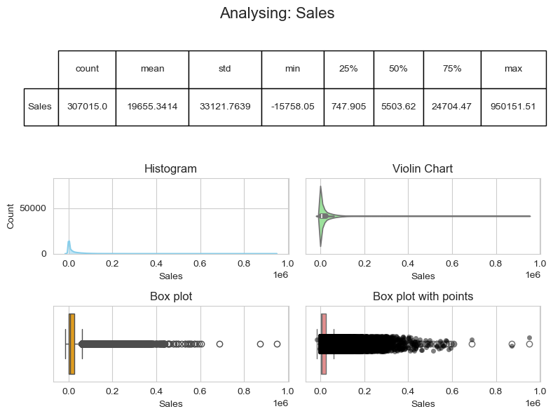

```python
# Variable: Vendas
# Converter de string para float
df["Sales"] = df["Vendas"].str.replace(",", "").astype(float)

# Contar total de faltantes/inválidos
missing_count = df["Sales"].isna().sum()
print(f"Total de linhas faltantes ou com erro: {missing_count}")

# Filtrar e exibir linhas onde a conversão falhou
error_rows = df[df["Sales"].isna()]
print(error_rows[["Vendas", "Sales"]])

# Verificar o mais antigo e o mais recente
print(df["Sales"].describe())

univariate_numeric_variable(df, "Sales")
```

#### Variável Vendas_adj

```
count    307015.000000
mean      19655.435832
std       33121.694370
min           0.000000
25%         747.905000
50%        5503.620000
75%       24704.470000
max      950151.510000
Name: Sales_adj, dtype: float64
```

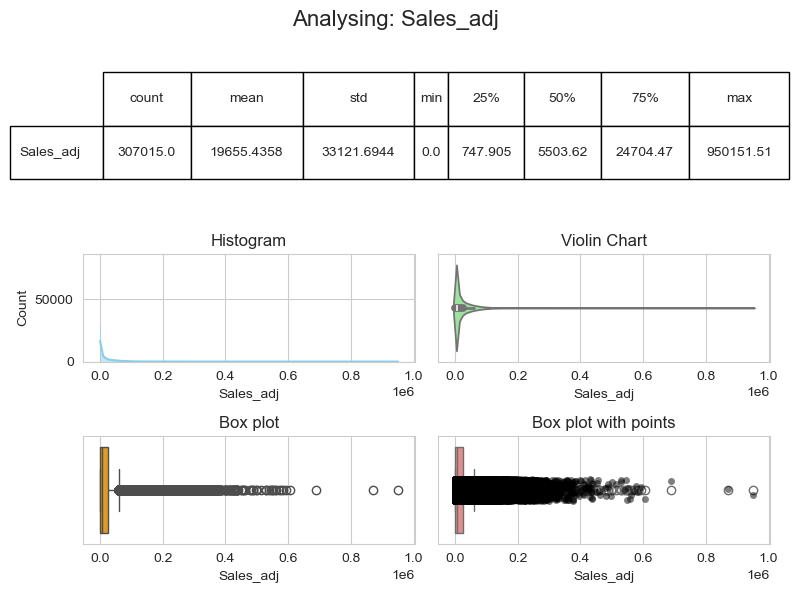

```python
df["Sales_adj"] = df["Sales"].clip(lower=0)

# Verificar o mais antigo e o mais recente
print(df["Sales_adj"].describe())

univariate_numeric_variable(df, "Sales_adj")
```

### Variável: Company

- Decidimos criar uma string para cada empresa.
- Observe que `Comp_1` é a que mais aparece no banco e `Comp_23` a que menos aparece.

```
['Comp_1' 'Comp_2' 'Comp_5' 'Comp_15' 'Comp_16' 'Comp_6' 'Comp_13'
 'Comp_12' 'Comp_9' 'Comp_19' 'Comp_18' 'Comp_21' 'Comp_22' 'Comp_23']
Categorical variable describe:
```

|  | count | unique | top | freq |
| --- | --- | --- | --- | --- |
| Company | 307015 | 14 | Comp_1 | 31095 |

```
Frequency table of categorical variable (with percentage and total):
```

|  | Company | Frequency | Percentage (%) |
| --- | --- | --- | --- |
| 0 | Comp_1 | 31095 | 10.13 |
| 1 | Comp_9 | 29106 | 9.48 |
| 2 | Comp_2 | 27960 | 9.11 |
| 3 | Comp_19 | 26106 | 8.50 |
| 4 | Comp_18 | 25373 | 8.26 |
| 5 | Comp_15 | 24840 | 8.09 |
| 6 | Comp_16 | 24746 | 8.06 |
| 7 | Comp_5 | 24664 | 8.03 |
| 8 | Comp_12 | 24512 | 7.98 |
| 9 | Comp_13 | 22759 | 7.41 |
| 10 | Comp_6 | 21062 | 6.86 |
| 11 | Comp_21 | 16327 | 5.32 |
| 12 | Comp_22 | 6230 | 2.03 |
| 13 | Comp_23 | 2235 | 0.73 |
| 14 | Total | 307015 | 100.00 |

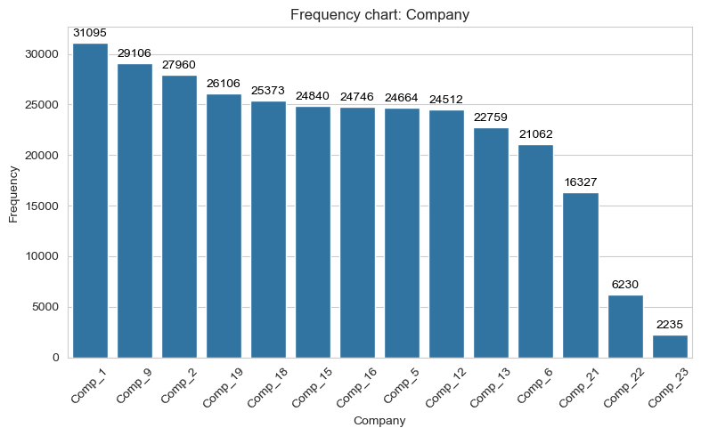

```python
# Variable: Empresa
df["Company"] = "Comp_" + df["Empresa"].astype(str)

print(df["Company"].unique())

univariate_categorical_variable(df, "Company")
```

### Variável: Seção

- `Seção 23` é a mais frequente no banco (representando 5,8%).
- `Seção 29` é a menos presente no banco, com apenas 14 registros.

```
Categorical variable describe:
```

|  | count | unique | top | freq |
| --- | --- | --- | --- | --- |
| Seção | 307015 | 29 | Seção 23 | 17827 |

```
Frequency table of categorical variable (with percentage and total):
```

|  | Seção | Frequency | Percentage (%) |
| --- | --- | --- | --- |
| 0 | Seção 23 | 17827 | 5.81 |
| 1 | Seção 26 | 12908 | 4.20 |
| 2 | Seção 20 | 12908 | 4.20 |
| 3 | Seção 16 | 12907 | 4.20 |
| 4 | Seção 13 | 12906 | 4.20 |
| 5 | Seção 3 | 12906 | 4.20 |
| 6 | Seção 4 | 12906 | 4.20 |
| 7 | Seção 17 | 12906 | 4.20 |
| 8 | Seção 2 | 12906 | 4.20 |
| 9 | Seção 9 | 12906 | 4.20 |
| 10 | Seção 21 | 12906 | 4.20 |
| 11 | Seção 18 | 12905 | 4.20 |
| 12 | Seção 19 | 12905 | 4.20 |
| 13 | Seção 25 | 12903 | 4.20 |
| 14 | Seção 6 | 12902 | 4.20 |
| 15 | Seção 7 | 12896 | 4.20 |
| 16 | Seção 24 | 12536 | 4.08 |
| 17 | Seção 8 | 12146 | 3.96 |
| 18 | Seção 27 | 11852 | 3.86 |
| 19 | Seção 15 | 11820 | 3.85 |
| 20 | Seção 1 | 11630 | 3.79 |
| 21 | Seção 12 | 9222 | 3.00 |
| 22 | Seção 11 | 8055 | 2.62 |
| 23 | Seção 5 | 5098 | 1.66 |
| 24 | Seção 14 | 4080 | 1.33 |
| 25 | Seção 28 | 3698 | 1.20 |
| 26 | Seção 10 | 3232 | 1.05 |
| 27 | Seção 22 | 2229 | 0.73 |
| 28 | Seção 29 | 14 | 0.00 |
| 29 | Total | 307015 | 100.00 |

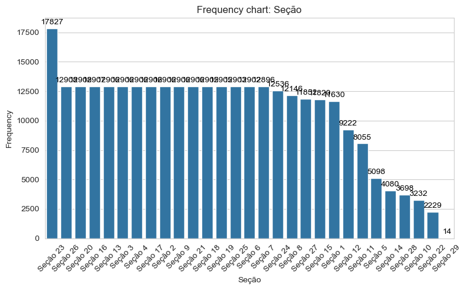

```python
univariate_categorical_variable(df, "Seção")
```

### Variável: Departamento

- `Depto 3` é o mais frequente, representando 38% dos dados.
- `Depto 4` e `Depto 2` representam ~25% dos dados
- Todos os outros departamentos estão abaixo de 10%.

```
Categorical variable describe:
```

|  | count | unique | top | freq |
| --- | --- | --- | --- | --- |
| Departamento | 307015 | 7 | Depto 3 | 117115 |

```
Frequency table of categorical variable (with percentage and total):
```

|  | Departamento | Frequency | Percentage (%) |
| --- | --- | --- | --- |
| 0 | Depto 3 | 117115 | 38.15 |
| 1 | Depto 4 | 79294 | 25.83 |
| 2 | Depto 2 | 77439 | 25.22 |
| 3 | Depto 5 | 12903 | 4.20 |
| 4 | Depto 1 | 11630 | 3.79 |
| 5 | Depto 7 | 4936 | 1.61 |
| 6 | Depto 6 | 3698 | 1.20 |
| 7 | Total | 307015 | 100.00 |

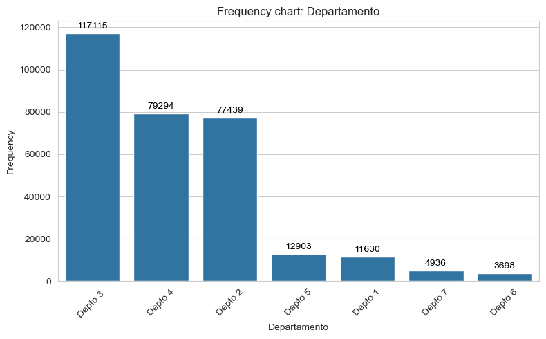

```python
univariate_categorical_variable(df, "Departamento")
```

### ▫️Seção Final Notas

Analisamos cada variável separadamente, mas cada nível de combinação pode nos dar outra direção de como os dados podem ser usados para obter a melhor previsão.

- Company - Departamento - Seção :
  - Usando essa combinação, vemos que nem todas as empresas têm o mesmo departamento nem as mesmas seções ou número de seções.
  - O número de dias também não é o mesmo.
- Departamento - Seção :
  - Usando essa combinação, vemos que nem todos os departamentos têm as mesmas seções ou número de seções.
  - O número de dias também não é o mesmo.

Since the initial problem told us to focus on Departamento 2 or 4, let's group our data athe Departamento level, and *ignore* for now Company and Seção variables as they seem to split the information too much and can cause noise when previsãoing.

```python
df.groupby(['Company', 'Departamento', 'Seção']).size()
```

```
Company  Departamento  Seção
Comp_1   Depto 1       Seção 1     1139
         Depto 2       Seção 16    1139
                       Seção 17    1139
                       Seção 2     1139
                       Seção 26    1139
                                   ...
Comp_9   Depto 4       Seção 23    1148
                       Seção 24    1148
         Depto 5       Seção 25    1148
         Depto 6       Seção 28     678
         Depto 7       Seção 23     360
Length: 394, dtype: int64
```

```python
df.groupby(['Departamento', 'Seção']).size()
```

```
Departamento  Seção
Depto 1       Seção 1     11630
Depto 2       Seção 16    12907
              Seção 17    12906
              Seção 2     12906
              Seção 26    12908
              Seção 3     12906
              Seção 4     12906
Depto 3       Seção 10     3232
              Seção 11     8055
              Seção 12     9222
              Seção 13    12906
              Seção 14     4080
              Seção 15    11820
              Seção 27    11852
              Seção 5      5098
              Seção 6     12902
              Seção 7     12896
              Seção 8     12146
              Seção 9     12906
Depto 4       Seção 18    12905
              Seção 19    12905
              Seção 20    12908
              Seção 21    12906
              Seção 22     2229
              Seção 23    12905
              Seção 24    12536
Depto 5       Seção 25    12903
Depto 6       Seção 28     3698
Depto 7       Seção 23     4922
              Seção 29       14
dtype: int64
```

## 🔸Escolha do Departamento e Agregação ao Nível Diário

```python
# agregar por Departamento & Data
df_depts = df.groupby(["Departamento", "Date"]).agg({
    'Sales_adj': 'sum',           # Somar vendas do dia
    'Feriado': 'max',             # Flag máxima (1 se qualquer registro for feriado, senão 0)
    'Pagamento': 'max',
    'Vale': 'max'
}).reset_index()
```

```
Categorical variable describe:
```

|  | count | unique | top | freq |
| --- | --- | --- | --- | --- |
| Departamento | 7707 | 7 | Depto 1 | 1148 |

```
Frequency table of categorical variable (with percentage and total):
```

|  | Departamento | Frequency | Percentage (%) |
| --- | --- | --- | --- |
| 0 | Depto 1 | 1148 | 14.90 |
| 1 | Depto 2 | 1148 | 14.90 |
| 2 | Depto 3 | 1148 | 14.90 |
| 3 | Depto 4 | 1148 | 14.90 |
| 4 | Depto 5 | 1148 | 14.90 |
| 5 | Depto 7 | 1147 | 14.88 |
| 6 | Depto 6 | 820 | 10.64 |
| 7 | Total | 7707 | 100.00 |

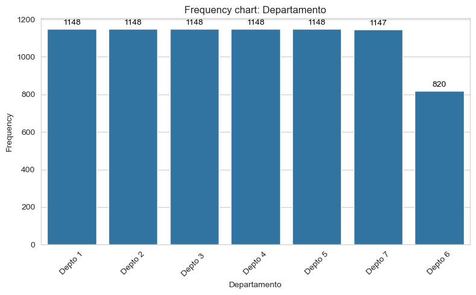

```python
univariate_categorical_variable(df_depts, "Departamento")

# univariate_categorical_variable(df_depts, "Feriado")

# univariate_categorical_variable(df_depts, "Pagamento")

# univariate_categorical_variable(df_depts, "Vale")

# univariate_numeric_variable(df_depts, "Sales_adj")
```

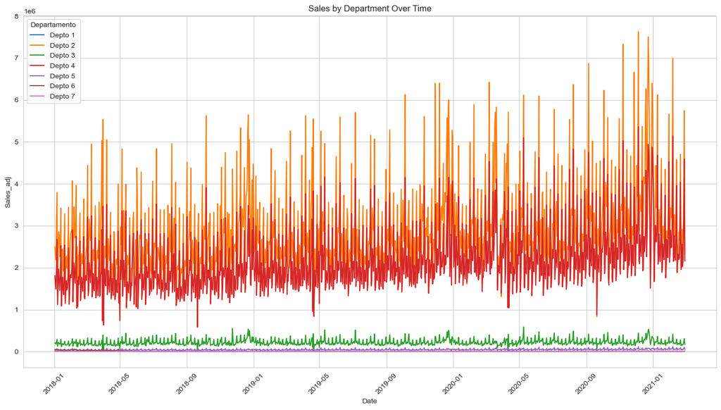

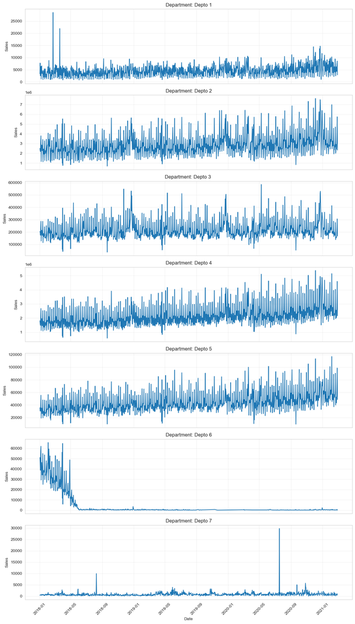

```python
# gráfico Departamento & Vendas por Data

plt.figure(figsize=(14, 8))
sns.lineplot(data=df_depts, x='Date', y='Sales_adj', hue='Departamento')
plt.title('Sales by Department Over Time')
plt.xticks(rotation=45)
plt.tight_layout()
plt.show()



fig, axes = plt.subplots(nrows=len(df_depts['Departamento'].unique()),
                         figsize=(12, 3*len(df_depts['Departamento'].unique())),
                         sharex=True)

for ax, (dept, group) in zip(axes, df_depts.groupby('Departamento')):
    ax.plot(group['Date'], group['Sales_adj'], linestyle='-')
    ax.set_title(f'Department: {dept}')
    ax.set_ylabel('Sales')
    ax.grid(True, alpha=0.3)

plt.xlabel('Date')
plt.xticks(rotation=45)
plt.tight_layout()
plt.show()
```

### Escolher Departamento

A partir deste momento, we have aggregated Departamento by dates, and we will now choose a department to focus on.

Não temos mais Companhia ou Seção.

```python
# escolhendo departamento
choose_dept = 'Depto 4'
print(f"Trabalharemos com: {choose_dept}")

df_dep = df_depts[df_depts['Departamento'] == choose_dept].copy()
```

```
Trabalharemos com: Depto 4
```

### Preencher datas faltantes

Precisamos criar um dataset com todas as datas do período que vamos analisar.

```python
# obter ano mínimo
min_year = df_dep['Date'].dt.year.min()

# criar data de início como 1º de janeiro daquele ano
start_date = pd.Timestamp(f'{min_year}-01-01')

# obter a data final
end_date = df_dep['Date'].max()

# criar intervalo completo de datas
all_dates = pd.date_range(start=start_date, end=end_date, freq='D')

# obter departamentos únicos
departments = df_dep['Departamento'].unique()

# criar todas as combinações de datas e departamentos
df_complete = pd.DataFrame(
    [(date, dept) for date in all_dates for dept in departments],
    columns=['Date', 'Departamento']
)

# mesclar com dados originais
df_complete = df_complete.merge(df_dep, on=['Date', 'Departamento'], how='left')

# Criar colunas diferentes para datas, mês, ano e combinação
df_complete['year'] = df_complete['Date'].dt.year
df_complete['month'] = df_complete['Date'].dt.month
df_complete['year_month'] = df_complete['Date'].dt.to_period('M')
df_complete['weekday'] = df_complete['Date'].dt.day_name()
```

```python
# df_complete
```

```python
# Análise de datas faltantes
df_complete[df_complete["Feriado"].isna()]
```

|  | Date | Departamento | Sales_adj | Feriado | Pagamento | Vale | year | month | year_month | weekday |
| --- | --- | --- | --- | --- | --- | --- | --- | --- | --- | --- |
| 0 | 2018-01-01 | Depto 4 | NaN | NaN | NaN | NaN | 2018 | 1 | 2018-01 | Monday |
| 358 | 2018-12-25 | Depto 4 | NaN | NaN | NaN | NaN | 2018 | 12 | 2018-12 | Tuesday |
| 365 | 2019-01-01 | Depto 4 | NaN | NaN | NaN | NaN | 2019 | 1 | 2019-01 | Tuesday |
| 723 | 2019-12-25 | Depto 4 | NaN | NaN | NaN | NaN | 2019 | 12 | 2019-12 | Wednesday |
| 730 | 2020-01-01 | Depto 4 | NaN | NaN | NaN | NaN | 2020 | 1 | 2020-01 | Wednesday |
| 1089 | 2020-12-25 | Depto 4 | NaN | NaN | NaN | NaN | 2020 | 12 | 2020-12 | Friday |
| 1096 | 2021-01-01 | Depto 4 | NaN | NaN | NaN | NaN | 2021 | 1 | 2021-01 | Friday |

#### ▪️Notas

Todas as datas faltantes eram Ano Novo e Natal!

- **Question**
  - *Isso pode significar que nunca houve vendas nessas datas, possivelmente porque não abrem?*
  - *Podemos criar uma flag para indicar que nunca haverá vendas nesse dia no futuro?*

#### Variável: isClosed

Vamos criar uma flag para as datas faltantes no dataset original, porque essas datas sempre estarão ausentes no futuro.

- Ocorre em todo 25 de dezembro e 1º de janeiro

```python
df_complete['isClosed'] = ((df_complete['Date'].dt.month == 12) & (df_complete['Date'].dt.day == 25)) | \
                          ((df_complete['Date'].dt.month == 1) & (df_complete['Date'].dt.day == 1))

df_complete['isClosed'] = df_complete['isClosed'].astype(int)
```

```python
# Assign 0 to the other variables

df_complete['Feriado'] = df_complete['Feriado'].fillna(0)
df_complete['Pagamento'] = df_complete['Pagamento'].fillna(0)
df_complete['Vale'] = df_complete['Vale'].fillna(0)
df_complete['Sales_adj'] = df_complete['Sales_adj'].fillna(0)
```

### Variável: Feriado

#### Dataset Externo: `holidays.csv`

Para permitir o mapeamento preciso das flags de feriado em datas futuras, obtivemos dados de feriados brasileiros da [Feriados API](https://feriadosapi.com/docs#introducao). Esse dataset externo fornece uma referência padronizada de feriados em diferentes períodos e nos permite avaliar sistematicamente como os feriados estão representados na nossa série temporal.

Dictionary

| # | Variable | Description | Type | Raw | Notas |
| --- | --- | --- | --- | --- | --- |
| 1 | id | unique ID of holiday date | Qualitativa Nominal | Y |  |
| 2 | data | Holiday date, format `DD/MM/YYYY` | Date | Y |  |
| 3 | nome | Holiday name | Qualitativa Nominal | Y |  |
| 4 | tipo | Which holiday databse the holiday was extracted: National / State / State Capital `NACIONAL` / `ESTADUAL` / `MUNICIPAL` | Qualitativa Nominal | Y |  |
| 5 | descricao | Holiday descriptive long | Qualitativa Nominal | Y |  |
| 6 | uf | Brazilian State. Only present in **tipo** = `ESTADUAL` / `MUNICIPAL` | Qualitativa Nominal | Y |  |
| 7 | codigo_ibge | City code according to IBGE. Only present in **tipo** = `MUNICIPAL` | Qualitativa Nominal | Y |  |
| 8 | bancario | Flag for a bank holiday | Qualitativa Binária | Y |  |
| 9 | year | Holiday date year extracted. | Quantitativa Discreta | Y |  |
| 10 | type | same as `tipo` `national` / `state` / `capital` | Qualitativa Nominal | Y |  |
| 11 | state | same as `uf` | Qualitativa Nominal | Y |  |
| 12 | ibge_code | same as `codigo_ibge` | Qualitativa Nominal | Y |  |
| 13 | Date | Convert from a regular english date format `YYYY-MM-DD` | Date | N |  |

```python
df_holiday["Date"] = pd.to_datetime(df_holiday["data"], format='%d/%m/%Y', errors='coerce')
# df_holiday.head()
# df_holiday[df_holiday["Date"] == '2019-10-12']

df_holiday_simple = df_holiday[["Date", "nome"]].copy()
df_holiday_unique = df_holiday_simple.drop_duplicates(subset=['Date'], keep='first')

# df_holiday_simpleSP = df_holiday_simple[df_holiday_simple["state"] == 'SP'].copy()
# df_holiday_simpleSP.head()

# Check if there are any duplicate dates
has_duplicates = df_holiday_unique['Date'].duplicated().any()
print(f"Are there duplicate dates? {has_duplicates}")

# See which dates are duplicated
duplicate_dates = df_holiday_unique[df_holiday_unique['Date'].duplicated(keep=False)]
print("Duplicate dates:")
print(duplicate_dates['Date'].value_counts())
```

```
Are there duplicate dates? False
Duplicate dates:
Series([], Name: count, dtype: int64)
```

```python
df_complete1 = df_complete.merge(df_holiday_unique, on=['Date'], how='left')
```

```python
df_map_holidays = df_complete1[df_complete1["Feriado"] == 1]

print(f"Total holidays in the database: {df_map_holidays.shape}")
print(f"Holidays missing description: {df_map_holidays[df_map_holidays["nome"].isna()].shape}")
```

```
Total holidays in the database: (43, 12)
Holidays missing description: (0, 12)
```

#### Investigando registros com `Feriado = 1` **sem** descrição de feriado

Registros em que o indicador de feriado está ativo (`Feriado = 1`), mas nenhum nome de feriado é fornecido.  
Examinamos a frequência desses casos, sua distribuição ao longo do tempo e o potencial impacto na análise de séries temporais.

```python
df_map_holidays[df_map_holidays["nome"].isna()]
```

|  | Date | Departamento | Sales_adj | Feriado | Pagamento | Vale | year | month | year_month | weekday | isClosed | nome |
| --- | --- | --- | --- | --- | --- | --- | --- | --- | --- | --- | --- | --- |

#### Investigando registros com `Feriado = 1` **com** descrição de feriado

Registros em que o indicador de feriado está ativo (`Feriado = 1`) e um nome de feriado é fornecido.  
Examinamos os feriados únicos, suas contagens de ocorrência e padrões temporais para entender melhor seu potencial impacto na série.

```python
# what are the holidays being correctly flag?
df_map_holidays.groupby(['nome']).size()
```

```
nome
Aniversário da Cidade de São Paulo              4
Carnaval                                        4
Carnaval (Segunda-feira)                        4
Corpus Christi                                  3
Dia Mundial do Trabalho                         3
Dia Nacional de Zumbi e da Consciência Negra    2
Dia da Consciência Negra                        1
Dia de Finados                                  2
Dia de Tiradentes                               3
Finados                                         1
Imaculada Conceição                             3
Independência do Brasil                         3
Nossa Senhora Aparecida                         3
Proc. República Rio Grandense                   1
Proclamação da República                        3
Sexta-Feira Santa                               1
Sexta-feira Santa                               2
dtype: int64
```

#### Investigando registros com `Feriado = 0` **com** descrição de feriado

Esses registros têm a flag de feriado definida como 0, mas um nome/descrição de feriado está presente. Isso pode refletir na granularidade da base de feriados, por exemplo, feriados municipais de cidades pequenas que não afetam de forma significativa as vendas geral da empresa e assim não são classificados como relevantes.  
Esta seção verifica a frequência desses casos, quais feriados aparecem e se devem ser tratados como problemas de qualidade de dados ou comportamento esperado.

```python
# what are the non holidays that has description?
df_map_NOTholidays = df_complete1[df_complete1["Feriado"] == 0]
df_map_NOTholidays.groupby(['nome']).size()
```

```
nome
Aniversário de Florianópolis                 3
Ano Novo                                     4
Assunção de Nossa Senhora                    3
Dia de Santa Catarina                        3
Dia de São Jorge                             3
Dia de São Sebastião, Padroeiro da cidade    4
Dia do Evangélico                            3
Natal                                        3
Nossa Senhora da Luz dos Pinhais             3
Nossa Senhora da Penha                       3
Nossa Senhora dos Navegantes                 4
Proc. República Rio Grandense                2
Revolução Constitucionalista de 1932         3
dtype: int64
```

#### Flags de feriado inconsistentes: mesma data marcada como feriado e não-feriado

Investigamos casos em que o mesmo dia do calendário aparece com `Feriado = 1` em alguns anos e `Feriado = 0` em outros.  
Essa análise ajuda a detectar possíveis inconsistências no dataset de feriados ou diferenças na forma como os feriados foram registrados ao longo do tempo.

```python
# Check if any holiday names have inconsistent flags
inconsistent_holidays = df_complete1.groupby('nome')['Feriado'].nunique()
inconsistent_holidays = inconsistent_holidays[inconsistent_holidays > 1].index.tolist()

print(f"Holidays with inconsistent flags: {len(inconsistent_holidays)}")
print(inconsistent_holidays)

# View the actual inconsistencies
df_inconsistent = df_complete1[df_complete1['nome'].isin(inconsistent_holidays)]
df_inconsistent[['Date', 'nome', 'Feriado']].sort_values(['nome', 'Date'])
```

```
Holidays with inconsistent flags: 1
['Proc. República Rio Grandense']
```

|  | Date | nome | Feriado |
| --- | --- | --- | --- |
| 262 | 2018-09-20 | Proc. República Rio Grandense | 0.0 |
| 627 | 2019-09-20 | Proc. República Rio Grandense | 1.0 |
| 993 | 2020-09-20 | Proc. República Rio Grandense | 0.0 |

```python
# df_complete1[df_complete1['nome'] == "Proc. República Rio Grandense"]
```

```python
# df_holiday[df_holiday['Date'] == '2019-09-20']
```

#### 📌 REGRA: Marcação de Feriados Futuros

**Principais Aprendizados**:

- As descrições de feriados são consistentes e mapeáveis.
  - Todos os feriados no dataset podem ser vinculados a um nome descritivo (campo `nome`).
  - Isso torna viável usar essas descrições como referência confiável para sinalizar feriados em dados futuros.
- Descrições de não-feriados exigem cautela.
  - Algumas descrições aparecem no dataset, mas não foram sinalizadas como feriados (`Feriado = 0`).
  - Isso pode ser devido a variações regionais — certos feriados são observados apenas em cidades ou estados específicos, e não nacionalmente.
  - Esses casos devem ser tratados com cuidado ao aplicar a flag a períodos futuros.
- Sinalização inconsistente de feriados observada para certos eventos.
  - O feriado *"Proc. República Rio Grandense"* foi sinalizado como feriado (`Feriado = 1`) em 2019, mas não em 2018 ou 2020.
  - Essa inconsistência levanta questões sobre se esse evento deve ser considerado feriado em previsões futuras.
  - **Decisão**: Por enquanto, assumiremos esse feriado como NÃO feriado (`Feriado = 0`) ao mapear datas futuras, a menos que contexto ou dados adicionais indiquem o contrário.

```python
holiday_descriptions = df_map_holidays.groupby(['nome']).size()

holiday_descriptions
```

```
nome
Aniversário da Cidade de São Paulo              4
Carnaval                                        4
Carnaval (Segunda-feira)                        4
Corpus Christi                                  3
Dia Mundial do Trabalho                         3
Dia Nacional de Zumbi e da Consciência Negra    2
Dia da Consciência Negra                        1
Dia de Finados                                  2
Dia de Tiradentes                               3
Finados                                         1
Imaculada Conceição                             3
Independência do Brasil                         3
Nossa Senhora Aparecida                         3
Proc. República Rio Grandense                   1
Proclamação da República                        3
Sexta-Feira Santa                               1
Sexta-feira Santa                               2
dtype: int64
```

##### Feriados a serem usados para a Flag de Feriado

```python
# Get the list of holiday names from holiday_descriptions
holiday_names = holiday_descriptions.index.tolist()

# Filter the main dataframe
df_holiday_filtered = df_holiday_unique[df_holiday_unique['nome'].isin(holiday_names)]

df_holiday_filtered
```

|  | Date | nome |
| --- | --- | --- |
| 9 | 2018-01-25 | Aniversário da Cidade de São Paulo |
| 11 | 2018-02-12 | Carnaval (Segunda-feira) |
| 12 | 2018-02-13 | Carnaval |
| 14 | 2018-03-30 | Sexta-feira Santa |
| 29 | 2018-04-21 | Dia de Tiradentes |
| 39 | 2018-05-01 | Dia Mundial do Trabalho |
| 47 | 2018-05-31 | Corpus Christi |
| 58 | 2018-09-07 | Independência do Brasil |
| 68 | 2018-09-20 | Proc. República Rio Grandense |
| 69 | 2018-10-12 | Nossa Senhora Aparecida |
| 77 | 2018-11-02 | Dia de Finados |
| 89 | 2018-11-15 | Proclamação da República |
| 97 | 2018-11-20 | Dia Nacional de Zumbi e da Consciência Negra |
| 108 | 2018-12-08 | Imaculada Conceição |
| 126 | 2019-01-25 | Aniversário da Cidade de São Paulo |
| 128 | 2019-03-04 | Carnaval (Segunda-feira) |
| 129 | 2019-03-05 | Carnaval |
| 131 | 2019-04-19 | Sexta-feira Santa |
| 145 | 2019-04-21 | Dia de Tiradentes |
| 155 | 2019-05-01 | Dia Mundial do Trabalho |
| 163 | 2019-06-20 | Corpus Christi |
| 174 | 2019-09-07 | Independência do Brasil |
| 184 | 2019-09-20 | Proc. República Rio Grandense |
| 185 | 2019-10-12 | Nossa Senhora Aparecida |
| 193 | 2019-11-02 | Dia de Finados |
| 205 | 2019-11-15 | Proclamação da República |
| 213 | 2019-11-20 | Dia da Consciência Negra |
| 224 | 2019-12-08 | Imaculada Conceição |
| 242 | 2020-01-25 | Aniversário da Cidade de São Paulo |
| 244 | 2020-02-24 | Carnaval (Segunda-feira) |
| 245 | 2020-02-25 | Carnaval |
| 247 | 2020-04-10 | Sexta-Feira Santa |
| 262 | 2020-04-21 | Dia de Tiradentes |
| 272 | 2020-05-01 | Dia Mundial do Trabalho |
| 280 | 2020-06-11 | Corpus Christi |
| 291 | 2020-09-07 | Independência do Brasil |
| 301 | 2020-09-20 | Proc. República Rio Grandense |
| 302 | 2020-10-12 | Nossa Senhora Aparecida |
| 310 | 2020-11-02 | Finados |
| 322 | 2020-11-15 | Proclamação da República |
| 330 | 2020-11-20 | Dia Nacional de Zumbi e da Consciência Negra |
| 341 | 2020-12-08 | Imaculada Conceição |
| 359 | 2021-01-25 | Aniversário da Cidade de São Paulo |
| 361 | 2021-02-15 | Carnaval (Segunda-feira) |
| 362 | 2021-02-16 | Carnaval |
| 387 | 2021-04-21 | Dia de Tiradentes |
| 397 | 2021-05-01 | Dia Mundial do Trabalho |
| 405 | 2021-06-03 | Corpus Christi |
| 416 | 2021-09-07 | Independência do Brasil |
| 426 | 2021-09-20 | Proc. República Rio Grandense |
| 427 | 2021-10-12 | Nossa Senhora Aparecida |
| 435 | 2021-11-02 | Dia de Finados |
| 447 | 2021-11-15 | Proclamação da República |
| 455 | 2021-11-20 | Dia Nacional de Zumbi e da Consciência Negra |
| 466 | 2021-12-08 | Imaculada Conceição |

### Variável: Pagamento

```python
# Add .reset_index(name='count') at the end of line 1
df_pgto = df_complete[df_complete['Pagamento'] == 1].copy()
check_payday = df_pgto.groupby(['Date']).size().reset_index(name='count')

# Now 'Date' is a normal column, so this will work perfectly
check_payday["Date"] = pd.to_datetime(check_payday["Date"])

# Extract your weekday columns
check_payday["day_name"] = check_payday["Date"].dt.day_name()
check_payday["day_num"] = check_payday["Date"].dt.weekday

check_payday
```

|  | Date | count | day_name | day_num |
| --- | --- | --- | --- | --- |
| 0 | 2018-01-05 | 1 | Friday | 4 |
| 1 | 2018-02-06 | 1 | Tuesday | 1 |
| 2 | 2018-02-07 | 1 | Wednesday | 2 |
| 3 | 2018-03-06 | 1 | Tuesday | 1 |
| 4 | 2018-04-06 | 1 | Friday | 4 |
| 5 | 2018-05-07 | 1 | Monday | 0 |
| 6 | 2018-06-06 | 1 | Wednesday | 2 |
| 7 | 2018-07-06 | 1 | Friday | 4 |
| 8 | 2018-08-06 | 1 | Monday | 0 |
| 9 | 2018-09-06 | 1 | Thursday | 3 |
| 10 | 2018-10-05 | 1 | Friday | 4 |
| 11 | 2018-11-07 | 1 | Wednesday | 2 |
| 12 | 2018-12-06 | 1 | Thursday | 3 |
| 13 | 2019-01-07 | 1 | Monday | 0 |
| 14 | 2019-02-06 | 1 | Wednesday | 2 |
| 15 | 2019-03-08 | 1 | Friday | 4 |
| 16 | 2019-04-05 | 1 | Friday | 4 |
| 17 | 2019-05-07 | 1 | Tuesday | 1 |
| 18 | 2019-06-06 | 1 | Thursday | 3 |
| 19 | 2019-07-05 | 1 | Friday | 4 |
| 20 | 2019-08-06 | 1 | Tuesday | 1 |
| 21 | 2019-09-06 | 1 | Friday | 4 |
| 22 | 2019-10-04 | 1 | Friday | 4 |
| 23 | 2019-11-07 | 1 | Thursday | 3 |
| 24 | 2019-12-06 | 1 | Friday | 4 |
| 25 | 2020-01-07 | 1 | Tuesday | 1 |
| 26 | 2020-02-06 | 1 | Thursday | 3 |
| 27 | 2020-03-06 | 1 | Friday | 4 |
| 28 | 2020-04-06 | 1 | Monday | 0 |
| 29 | 2020-05-07 | 1 | Thursday | 3 |
| 30 | 2020-06-05 | 1 | Friday | 4 |
| 31 | 2020-07-06 | 1 | Monday | 0 |
| 32 | 2020-08-06 | 1 | Thursday | 3 |
| 33 | 2020-09-04 | 1 | Friday | 4 |
| 34 | 2020-10-06 | 1 | Tuesday | 1 |
| 35 | 2020-11-06 | 1 | Friday | 4 |
| 36 | 2020-12-04 | 1 | Friday | 4 |
| 37 | 2020-12-07 | 1 | Monday | 0 |
| 38 | 2021-01-07 | 1 | Thursday | 3 |
| 39 | 2021-02-05 | 1 | Friday | 4 |

#### Dia do Mês

Verificando qual o **dia do mês** aparece mais frequentemente com a flag de pagamento.

- Maior frequência no dia 6 e 7
- Varia entre 4 e 8, significando que tende a cair na primeira semana do mês
- **Question**:
  - *O dia da semana seria mais consistente?*

```python
# Extract the day number of the month (e.g., 5, 6, 7)
check_payday["day_of_month"] = check_payday["Date"].dt.day

# Count how many times each day of the month appears
payday_frequencies = check_payday.groupby("day_of_month").size().reset_index(name="payment_count")

# Sort by the highest frequency to see the dominant day
payday_frequencies = payday_frequencies.sort_values(by="payment_count", ascending=False)

print("\nPayment frequency per day of month:")
print(payday_frequencies)
```

```
Payment frequency per day of month:
   day_of_month  payment_count
2             6             20
3             7             10
1             5              6
0             4              3
4             8              1
```

#### Dia da Semana

Mesma verificação agora para **dia da semana*.

- Sexta-feira tem maior frequência
- O pagamento **nunca** ocorre no fim de semana
- **Question**:
  - *Alguma razão para não ser apenas na sexta-feira?*

```python
# Count how many times each day appears
payday_frequencies2 = check_payday.groupby("day_name").size().reset_index(name="payment_count")

# Sort by the highest frequency to see the dominant day
payday_frequencies2 = payday_frequencies2.sort_values(by="payment_count", ascending=False)

print("\nPayment frequency per week day:")
print(payday_frequencies2)
```

```
Payment frequency per week day:
    day_name  payment_count
0     Friday             16
2   Thursday              8
1     Monday              6
3    Tuesday              6
4  Wednesday              4
```

#### Day of Month, Dia da Semana, Holiday, Payment and isClosed

```python
# Get payment days only
payments = df_complete[df_complete['Pagamento'] == 1].copy()
payments['Date'] = pd.to_datetime(payments['Date'])
payments['day_of_month'] = payments['Date'].dt.day
payments['month'] = payments['Date'].dt.month
payments['year'] = payments['Date'].dt.year

# For each payment, get the first business day of that month
# First, get all business days (not weekend, not Feriado, not isClosed)
df_complete['is_business_day'] = (
    (df_complete['Date'].dt.weekday < 5) &  # Monday-Friday
    (df_complete['Feriado'] != 1) &
    (df_complete['isClosed'] != 1)
)

# For each month, find the first business day
first_biz_days = df_complete[df_complete['is_business_day']].groupby('year_month')['Date'].min().reset_index()
first_biz_days.columns = ['year_month', 'first_business_day']

# Merge with payments
payments = payments.merge(first_biz_days, on='year_month', how='left')

# For each payment, count Feriado and isClosed in the period
def count_flags(row):
    mask = (df_complete['Date'] >= row['first_business_day']) & (df_complete['Date'] <= row['Date'])
    period_data = df_complete[mask]
    return pd.Series({
        'feriado_count': period_data['Feriado'].sum(),
        'closed_count': period_data['isClosed'].sum(),
        'weekend_count': (period_data['Date'].dt.weekday >= 5).sum()
    })

# Apply the function to get counts
counts = payments.apply(count_flags, axis=1)
payments = pd.concat([payments, counts], axis=1)

# Calculate days from first business day
payments['days_from_first_biz'] = (payments['Date'] - payments['first_business_day']).dt.days - payments['weekend_count']
payments['biz_days_from_first_biz'] = payments['days_from_first_biz'] - payments['feriado_count'] - payments['closed_count']

# Add total days in the month
payments['total_days_in_month'] = payments['Date'].dt.days_in_month

# Add total business days in the month (excluding weekends, Feriado, isClosed)
def count_total_biz_days(row):
    year = row['year']
    month = row['month']
    start_date = pd.Timestamp(year=year, month=month, day=1)
    end_date = start_date + pd.offsets.MonthEnd(0)
    month_dates = pd.date_range(start=start_date, end=end_date)

    biz_count = 0
    for d in month_dates:
        day_data = df_complete[df_complete['Date'] == d]
        if len(day_data) > 0:
            if d.weekday() < 5 and day_data['Feriado'].values[0] != 1 and day_data['isClosed'].values[0] != 1:
                biz_count += 1
    return biz_count

payments['total_biz_days_in_month'] = payments.apply(count_total_biz_days, axis=1)

# Create final result table
result_df = payments[['year_month', 'day_of_month', 'first_business_day', 'weekday',
                      'feriado_count', 'closed_count', 'weekend_count', 'days_from_first_biz',
                      'biz_days_from_first_biz', 'total_days_in_month', 'total_biz_days_in_month']].copy()
result_df.columns = ['Month', 'Payment_Day', 'First_Business_Day', 'Payment_Weekday',
                     'Feriado_Count', 'isClosed_Count', 'Weekend_Count', 'Days_From_First_Biz',
                     'Biz_Days_From_First_Biz', 'Total_Days_In_Month', 'Total_Biz_Days_In_Month']

print("\nPAYMENT ANALYSIS TABLE")
print("\n" + "="*100)
print(result_df.to_string(index=False))
print("="*100)
```

```
PAYMENT ANALYSIS TABLE

====================================================================================================
  Month  Payment_Day First_Business_Day Payment_Weekday  Feriado_Count  isClosed_Count  Weekend_Count  Days_From_First_Biz  Biz_Days_From_First_Biz  Total_Days_In_Month  Total_Biz_Days_In_Month
2018-01            5         2018-01-02          Friday            0.0             0.0            0.0                  3.0                      3.0                   31                       21
2018-02            6         2018-02-01         Tuesday            0.0             0.0            2.0                  3.0                      3.0                   28                       18
2018-02            7         2018-02-01       Wednesday            0.0             0.0            2.0                  4.0                      4.0                   28                       18
2018-03            6         2018-03-01         Tuesday            0.0             0.0            2.0                  3.0                      3.0                   31                       21
2018-04            6         2018-04-02          Friday            0.0             0.0            0.0                  4.0                      4.0                   30                       21
2018-05            7         2018-05-02          Monday            0.0             0.0            2.0                  3.0                      3.0                   31                       21
2018-06            6         2018-06-01       Wednesday            0.0             0.0            2.0                  3.0                      3.0                   30                       21
2018-07            6         2018-07-02          Friday            0.0             0.0            0.0                  4.0                      4.0                   31                       22
2018-08            6         2018-08-01          Monday            0.0             0.0            2.0                  3.0                      3.0                   31                       23
2018-09            6         2018-09-03        Thursday            0.0             0.0            0.0                  3.0                      3.0                   30                       19
2018-10            5         2018-10-01          Friday            0.0             0.0            0.0                  4.0                      4.0                   31                       22
2018-11            7         2018-11-01       Wednesday            1.0             0.0            2.0                  4.0                      3.0                   30                       19
2018-12            6         2018-12-03        Thursday            0.0             0.0            0.0                  3.0                      3.0                   31                       20
2019-01            7         2019-01-02          Monday            0.0             0.0            2.0                  3.0                      3.0                   31                       21
2019-02            6         2019-02-01       Wednesday            0.0             0.0            2.0                  3.0                      3.0                   28                       20
2019-03            8         2019-03-01          Friday            2.0             0.0            2.0                  5.0                      3.0                   31                       19
2019-04            5         2019-04-01          Friday            0.0             0.0            0.0                  4.0                      4.0                   30                       21
2019-05            7         2019-05-02         Tuesday            0.0             0.0            2.0                  3.0                      3.0                   31                       22
2019-06            6         2019-06-03        Thursday            0.0             0.0            0.0                  3.0                      3.0                   30                       19
2019-07            5         2019-07-01          Friday            0.0             0.0            0.0                  4.0                      4.0                   31                       23
2019-08            6         2019-08-01         Tuesday            0.0             0.0            2.0                  3.0                      3.0                   31                       22
2019-09            6         2019-09-02          Friday            0.0             0.0            0.0                  4.0                      4.0                   30                       20
2019-10            4         2019-10-01          Friday            0.0             0.0            0.0                  3.0                      3.0                   31                       23
2019-11            7         2019-11-01        Thursday            1.0             0.0            2.0                  4.0                      3.0                   30                       19
2019-12            6         2019-12-02          Friday            0.0             0.0            0.0                  4.0                      4.0                   31                       21
2020-01            7         2020-01-02         Tuesday            0.0             0.0            2.0                  3.0                      3.0                   31                       22
```

[output cut: 15 more lines]

```python
# Frequency of business days from first business day
print("FREQUENCY OF BUSINESS DAYS FROM FIRST BUSINESS DAY")
freq_biz_days = payments.groupby('biz_days_from_first_biz').size().reset_index(name='count')
freq_biz_days.columns = ['Business_Days', 'Number_of_Months']
print(freq_biz_days.sort_values('Number_of_Months', ascending=False).to_string(index=False))
```

```
FREQUENCY OF BUSINESS DAYS FROM FIRST BUSINESS DAY
 Business_Days  Number_of_Months
           3.0                28
           4.0                12
```

```python
print("PAYMENT BUSINESS DAYS BY BUSINESS MONTH SIZE")
print(result_df.groupby('Total_Biz_Days_In_Month')['Biz_Days_From_First_Biz'].value_counts().unstack(fill_value=0))
```

```
PAYMENT BUSINESS DAYS BY BUSINESS MONTH SIZE
Biz_Days_From_First_Biz  3.0  4.0
Total_Biz_Days_In_Month
18                         2    2
19                         7    0
20                         4    1
21                         9    5
22                         3    3
23                         3    1
```

```python
print("PAYMENT BUSINESS DAYS BY MONTH SIZE")
print(result_df.groupby('Total_Days_In_Month')['Biz_Days_From_First_Biz'].value_counts().unstack(fill_value=0))
```

```
PAYMENT BUSINESS DAYS BY MONTH SIZE
Biz_Days_From_First_Biz  3.0  4.0
Total_Days_In_Month
28                         2    2
29                         1    0
30                         8    4
31                        17    6
```

#### 📌REGRA: Dias de Pagamento Futuros

```python
def get_payment_date(year, month, df_complete):
    """
    Returns the 4th business day of the month
    Business day = not weekend, not Feriado, not isClosed
    """
    # Get all dates in the month
    start_date = pd.Timestamp(year=year, month=month, day=1)
    end_date = start_date + pd.offsets.MonthEnd(0)
    month_dates = pd.date_range(start=start_date, end=end_date)

    # Create a dictionary for quick lookup of Feriado and isClosed
    date_dict = {}
    for _, row in df_complete.iterrows():
        date_dict[row['Date']] = {
            'Feriado': row['Feriado'],
            'isClosed': row['isClosed']
        }

    # Find business days
    biz_days = []
    for d in month_dates:
        # Skip weekends
        if d.weekday() >= 5:
            continue

        # Check if we have data for this day
        if d not in date_dict:
            continue

        # Skip if Feriado or isClosed
        if date_dict[d]['Feriado'] == 1 or date_dict[d]['isClosed'] == 1:
            continue

        biz_days.append(d)

    # Return the 4th business day (index 3)
    if len(biz_days) >= 4:
        return biz_days[3]  # 4th business day
    else:
        print(f"Warning: Only {len(biz_days)} business days found for {year}-{month:02d}")
        return None

# Test for a specific month
print("Testing January 2018:")
test_date = get_payment_date(2018, 1, df_complete)
print(f"Calculated: {test_date}")  # Should be 2018-01-05

print("\nTesting February 2018:")
test_date = get_payment_date(2018, 2, df_complete)
print(f"Calculated: {test_date}")  # Should be 2018-02-06

# Usage
# payment_date = get_payment_date(2021, 1, df_complete)
# print(f"Payment should be on: {payment_date}")
```

```
Testing January 2018:
Calculated: 2018-01-05 00:00:00

Testing February 2018:
Calculated: 2018-02-06 00:00:00
```

```python
# Store all payment dates in a DataFrame
results_payday_range = []
for year in range(2018, 2022):
    for month in range(1, 13):
        payment_date = get_payment_date(year, month, df_complete)
        if payment_date:
            results_payday_range.append({
                'year': year,
                'month': month,
                'payment_date': payment_date,
                'day_of_month': payment_date.day,
                'weekday': payment_date.strftime('%A')
            })

results_payday_range_df = pd.DataFrame(results_payday_range)
results_payday_range_df
```

|  | year | month | payment_date | day_of_month | weekday |
| --- | --- | --- | --- | --- | --- |
| 0 | 2018 | 1 | 2018-01-05 | 5 | Friday |
| 1 | 2018 | 2 | 2018-02-06 | 6 | Tuesday |
| 2 | 2018 | 3 | 2018-03-06 | 6 | Tuesday |
| 3 | 2018 | 4 | 2018-04-05 | 5 | Thursday |
| 4 | 2018 | 5 | 2018-05-07 | 7 | Monday |
| 5 | 2018 | 6 | 2018-06-06 | 6 | Wednesday |
| 6 | 2018 | 7 | 2018-07-05 | 5 | Thursday |
| 7 | 2018 | 8 | 2018-08-06 | 6 | Monday |
| 8 | 2018 | 9 | 2018-09-06 | 6 | Thursday |
| 9 | 2018 | 10 | 2018-10-04 | 4 | Thursday |
| 10 | 2018 | 11 | 2018-11-07 | 7 | Wednesday |
| 11 | 2018 | 12 | 2018-12-06 | 6 | Thursday |
| 12 | 2019 | 1 | 2019-01-07 | 7 | Monday |
| 13 | 2019 | 2 | 2019-02-06 | 6 | Wednesday |
| 14 | 2019 | 3 | 2019-03-08 | 8 | Friday |
| 15 | 2019 | 4 | 2019-04-04 | 4 | Thursday |
| 16 | 2019 | 5 | 2019-05-07 | 7 | Tuesday |
| 17 | 2019 | 6 | 2019-06-06 | 6 | Thursday |
| 18 | 2019 | 7 | 2019-07-04 | 4 | Thursday |
| 19 | 2019 | 8 | 2019-08-06 | 6 | Tuesday |
| 20 | 2019 | 9 | 2019-09-05 | 5 | Thursday |
| 21 | 2019 | 10 | 2019-10-04 | 4 | Friday |
| 22 | 2019 | 11 | 2019-11-06 | 6 | Wednesday |
| 23 | 2019 | 12 | 2019-12-05 | 5 | Thursday |
| 24 | 2020 | 1 | 2020-01-07 | 7 | Tuesday |
| 25 | 2020 | 2 | 2020-02-06 | 6 | Thursday |
| 26 | 2020 | 3 | 2020-03-05 | 5 | Thursday |
| 27 | 2020 | 4 | 2020-04-06 | 6 | Monday |
| 28 | 2020 | 5 | 2020-05-07 | 7 | Thursday |
| 29 | 2020 | 6 | 2020-06-04 | 4 | Thursday |
| 30 | 2020 | 7 | 2020-07-06 | 6 | Monday |
| 31 | 2020 | 8 | 2020-08-06 | 6 | Thursday |
| 32 | 2020 | 9 | 2020-09-04 | 4 | Friday |
| 33 | 2020 | 10 | 2020-10-06 | 6 | Tuesday |
| 34 | 2020 | 11 | 2020-11-06 | 6 | Friday |
| 35 | 2020 | 12 | 2020-12-04 | 4 | Friday |
| 36 | 2021 | 1 | 2021-01-07 | 7 | Thursday |
| 37 | 2021 | 2 | 2021-02-04 | 4 | Thursday |

```python
df_complete = df_complete.merge(results_payday_range_df[['payment_date']], left_on='Date', right_on='payment_date', how='left')

# Add flags
df_complete['is_calculated_payment_day'] = df_complete['Date'] == df_complete['payment_date']
df_complete['payment_matches_rule'] = (df_complete['Pagamento'] == 1) & (df_complete['is_calculated_payment_day'] == True)

df_complete
```

|  | Date | Departamento | Sales_adj | Feriado | Pagamento | Vale | year | month | year_month | weekday | isClosed | is_business_day | payment_date | is_calculated_payment_day | payment_matches_rule |
| --- | --- | --- | --- | --- | --- | --- | --- | --- | --- | --- | --- | --- | --- | --- | --- |
| 0 | 2018-01-01 | Depto 4 | 0.00 | 0.0 | 0.0 | 0.0 | 2018 | 1 | 2018-01 | Monday | 1 | False | NaT | False | False |
| 1 | 2018-01-02 | Depto 4 | 1812134.19 | 0.0 | 0.0 | 0.0 | 2018 | 1 | 2018-01 | Tuesday | 0 | True | NaT | False | False |
| 2 | 2018-01-03 | Depto 4 | 1622115.60 | 0.0 | 0.0 | 0.0 | 2018 | 1 | 2018-01 | Wednesday | 0 | True | NaT | False | False |
| 3 | 2018-01-04 | Depto 4 | 1486888.42 | 0.0 | 0.0 | 0.0 | 2018 | 1 | 2018-01 | Thursday | 0 | True | NaT | False | False |
| 4 | 2018-01-05 | Depto 4 | 2015469.36 | 0.0 | 1.0 | 0.0 | 2018 | 1 | 2018-01 | Friday | 0 | True | 2018-01-05 | True | True |
| ... | ... | ... | ... | ... | ... | ... | ... | ... | ... | ... | ... | ... | ... | ... | ... |
| 1150 | 2021-02-24 | Depto 4 | 2025751.85 | 0.0 | 0.0 | 0.0 | 2021 | 2 | 2021-02 | Wednesday | 0 | True | NaT | False | False |
| 1151 | 2021-02-25 | Depto 4 | 2216224.47 | 0.0 | 0.0 | 1.0 | 2021 | 2 | 2021-02 | Thursday | 0 | True | NaT | False | False |
| 1152 | 2021-02-26 | Depto 4 | 3098829.40 | 0.0 | 0.0 | 0.0 | 2021 | 2 | 2021-02 | Friday | 0 | True | NaT | False | False |
| 1153 | 2021-02-27 | Depto 4 | 4592539.97 | 0.0 | 0.0 | 0.0 | 2021 | 2 | 2021-02 | Saturday | 0 | False | NaT | False | False |
| 1154 | 2021-02-28 | Depto 4 | 2157356.38 | 0.0 | 0.0 | 0.0 | 2021 | 2 | 2021-02 | Sunday | 0 | False | NaT | False | False |

1155 rows × 15 columns

#### ▪️Note

[output not shown]

```python
# Filter and count matches
payment_actual = df_complete[df_complete['Pagamento'] == 1]  # Actual payments
payment_calculated = df_complete[df_complete['is_calculated_payment_day'] == True]  # Calculated payment days

# Count matches and mismatches
total_payments = len(payment_actual)
matches = len(payment_actual[payment_actual['is_calculated_payment_day'] == True])
mismatches = total_payments - matches

print(f"Total payments: {total_payments}")
print(f"Matches rule: {matches} ({matches/total_payments*100:.1f}%)")
print(f"Mismatches: {mismatches} ({mismatches/total_payments*100:.1f}%)")

# Show mismatches
print("\nMISMATCHES")
mismatch_df = payment_actual[payment_actual['is_calculated_payment_day'] == False]
print(mismatch_df[['Date', 'Pagamento', 'payment_date']].to_string(index=False))

# Show matches
print("\nMATCHES")
match_df = payment_actual[payment_actual['is_calculated_payment_day'] == True]
print(match_df[['Date', 'Pagamento', 'payment_date']].to_string(index=False))
```

```
Total payments: 40
Matches rule: 27 (67.5%)
Mismatches: 13 (32.5%)

MISMATCHES
      Date  Pagamento payment_date
2018-02-07        1.0          NaT
2018-04-06        1.0          NaT
2018-07-06        1.0          NaT
2018-10-05        1.0          NaT
2019-04-05        1.0          NaT
2019-07-05        1.0          NaT
2019-09-06        1.0          NaT
2019-11-07        1.0          NaT
2019-12-06        1.0          NaT
2020-03-06        1.0          NaT
2020-06-05        1.0          NaT
2020-12-07        1.0          NaT
2021-02-05        1.0          NaT

MATCHES
      Date  Pagamento payment_date
2018-01-05        1.0   2018-01-05
2018-02-06        1.0   2018-02-06
2018-03-06        1.0   2018-03-06
2018-05-07        1.0   2018-05-07
2018-06-06        1.0   2018-06-06
2018-08-06        1.0   2018-08-06
2018-09-06        1.0   2018-09-06
2018-11-07        1.0   2018-11-07
2018-12-06        1.0   2018-12-06
2019-01-07        1.0   2019-01-07
2019-02-06        1.0   2019-02-06
2019-03-08        1.0   2019-03-08
2019-05-07        1.0   2019-05-07
2019-06-06        1.0   2019-06-06
2019-08-06        1.0   2019-08-06
2019-10-04        1.0   2019-10-04
2020-01-07        1.0   2020-01-07
2020-02-06        1.0   2020-02-06
2020-04-06        1.0   2020-04-06
2020-05-07        1.0   2020-05-07
2020-07-06        1.0   2020-07-06
2020-08-06        1.0   2020-08-06
2020-09-04        1.0   2020-09-04
2020-10-06        1.0   2020-10-06
2020-11-06        1.0   2020-11-06
2020-12-04        1.0   2020-12-04
2021-01-07        1.0   2021-01-07
```

```python
# check if any rule was missed when the rule
# print(df_complete[((df_complete['Pagamento'] == 1) | (df_complete['is_calculated_payment_day'] == True)) & (df_complete['payment_matches_rule'] == False)])
```

```python
# df_complete[df_complete['year_month'] == '2021-02'].head(10)
```

### Variável: Vale

```python
df_vale = df_complete[df_complete['Vale'] == 1].copy()
check_vale = df_vale.groupby(['Date']).size().reset_index(name='count')

# Now 'Date' is a normal column, so this will work perfectly
check_payday["Date"] = pd.to_datetime(check_vale["Date"])

# Extract your weekday columns
check_vale["day_name"] = check_vale["Date"].dt.day_name()
check_vale["day_num"] = check_vale["Date"].dt.weekday

check_vale
```

|  | Date | count | day_name | day_num |
| --- | --- | --- | --- | --- |
| 0 | 2018-01-24 | 1 | Wednesday | 2 |
| 1 | 2018-02-26 | 1 | Monday | 0 |
| 2 | 2018-02-27 | 1 | Tuesday | 1 |
| 3 | 2018-03-23 | 1 | Friday | 4 |
| 4 | 2018-04-25 | 1 | Wednesday | 2 |
| 5 | 2018-05-24 | 1 | Thursday | 3 |
| 6 | 2018-06-23 | 1 | Saturday | 5 |
| 7 | 2018-07-24 | 1 | Tuesday | 1 |
| 8 | 2018-08-23 | 1 | Thursday | 3 |
| 9 | 2018-09-25 | 1 | Tuesday | 1 |
| 10 | 2018-09-26 | 1 | Wednesday | 2 |
| 11 | 2018-10-24 | 1 | Wednesday | 2 |
| 12 | 2018-11-26 | 1 | Monday | 0 |
| 13 | 2018-11-27 | 1 | Tuesday | 1 |
| 14 | 2018-12-24 | 1 | Monday | 0 |
| 15 | 2018-12-26 | 1 | Wednesday | 2 |
| 16 | 2019-01-24 | 1 | Thursday | 3 |
| 17 | 2019-02-23 | 1 | Saturday | 5 |
| 18 | 2019-03-26 | 1 | Tuesday | 1 |
| 19 | 2019-04-24 | 1 | Wednesday | 2 |
| 20 | 2019-05-24 | 1 | Friday | 4 |
| 21 | 2019-06-25 | 1 | Tuesday | 1 |
| 22 | 2019-07-23 | 1 | Tuesday | 1 |
| 23 | 2019-08-23 | 1 | Friday | 4 |
| 24 | 2019-09-25 | 1 | Wednesday | 2 |
| 25 | 2019-09-26 | 1 | Thursday | 3 |
| 26 | 2019-10-24 | 1 | Thursday | 3 |
| 27 | 2019-11-26 | 1 | Tuesday | 1 |
| 28 | 2019-11-27 | 1 | Wednesday | 2 |
| 29 | 2019-12-24 | 1 | Tuesday | 1 |
| 30 | 2020-01-24 | 1 | Friday | 4 |
| 31 | 2020-02-26 | 1 | Wednesday | 2 |
| 32 | 2020-03-24 | 1 | Tuesday | 1 |
| 33 | 2020-04-25 | 1 | Saturday | 5 |
| 34 | 2020-05-25 | 1 | Monday | 0 |
| 35 | 2020-06-24 | 1 | Wednesday | 2 |
| 36 | 2020-07-23 | 1 | Thursday | 3 |
| 37 | 2020-08-24 | 1 | Monday | 0 |
| 38 | 2020-09-24 | 1 | Thursday | 3 |
| 39 | 2020-10-24 | 1 | Saturday | 5 |
| 40 | 2020-11-25 | 1 | Wednesday | 2 |
| 41 | 2020-11-26 | 1 | Thursday | 3 |
| 42 | 2020-12-23 | 1 | Wednesday | 2 |
| 43 | 2020-12-24 | 1 | Thursday | 3 |
| 44 | 2021-01-25 | 1 | Monday | 0 |
| 45 | 2021-01-26 | 1 | Tuesday | 1 |
| 46 | 2021-02-25 | 1 | Thursday | 3 |

```python
# Extract the day number of the month (e.g., 5, 6, 7)
check_vale["day_of_month"] = check_vale["Date"].dt.day

# Count how many times each day of the month appears
vale_frequencies = check_vale.groupby("day_of_month").size().reset_index(name="vale_count")

# Sort by the highest frequency to see the dominant day
vale_frequencies = vale_frequencies.sort_values(by="vale_count", ascending=False)

print("\nVale frequency per day of month:")
print(vale_frequencies)
```

```
Vale frequency per day of month:
   day_of_month  vale_count
1            24          17
3            26          10
2            25           9
0            23           8
4            27           3
```

```python
# Count how many times each day appears
vale_frequencies2 = check_vale.groupby("day_name").size().reset_index(name="vale_count")

# Sort by the highest frequency to see the dominant day
vale_frequencies2 = vale_frequencies2.sort_values(by="vale_count", ascending=False)

print("\nVale frequency per week day:")
print(vale_frequencies2)
```

```
Vale frequency per week day:
    day_name  vale_count
5  Wednesday          12
4    Tuesday          11
3   Thursday          10
1     Monday           6
0     Friday           4
2   Saturday           4
```

```python
vales = df_complete[df_complete['Vale'] == 1].copy()
vales['Date'] = pd.to_datetime(vales['Date'])
vales['day_of_month'] = vales['Date'].dt.day
vales['month'] = vales['Date'].dt.month
vales['year'] = vales['Date'].dt.year
vales['weekday'] = vales['Date'].dt.day_name()

def get_biz_days_for_month(year, month, df):
    """Return the ordered list of true business days for a given month."""
    start = pd.Timestamp(year=year, month=month, day=1)
    end   = start + pd.offsets.MonthEnd(0)
    month_dates = pd.date_range(start, end)

    date_dict = {
        row['Date']: row
        for _, row in df.iterrows()
    }

    biz = []
    for d in month_dates:
        if d.weekday() >= 5:                       # weekend
            continue
        if d not in date_dict:                     # missing day
            continue
        if date_dict[d]['Feriado'] == 1 or date_dict[d]['isClosed'] == 1:
            continue
        biz.append(d)
    return biz

# Calculate the true 1-based position of each Vale day
results = []
for _, row in vales.iterrows():
    d = row['Date']
    biz = get_biz_days_for_month(d.year, d.month, df_complete)

    if d in biz:
        pos = biz.index(d) + 1                     # 1-based
        from_end = len(biz) - pos + 1
    else:
        pos = None                                 # weekend or closed day
        from_end = None

    results.append({
        'Date': d,
        'day_of_month': d.day,
        'weekday': d.strftime('%A'),
        'month': d.month,
        'year': d.year,
        'biz_position': pos,                       # ← correct ordinal
        'total_biz_days': len(biz),
        'from_end': from_end
    })

result_df2 = pd.DataFrame(results)

print("=" * 80)
print("VALE ANALYSIS")
print("=" * 80)
print(result_df2.to_string(index=False))

print("\n\nFREQUENCY OF TRUE BUSINESS-DAY POSITION (1-based)")
print(result_df2['biz_position'].value_counts().sort_index())

print("\n\nFREQUENCY FROM THE END OF THE MONTH")
print(result_df2['from_end'].value_counts().sort_index())
```

```
================================================================================
VALE ANALYSIS
================================================================================
      Date  day_of_month   weekday  month  year  biz_position  total_biz_days  from_end
2018-01-24            24 Wednesday      1  2018          17.0              21       5.0
2018-02-26            26    Monday      2  2018          16.0              18       3.0
2018-02-27            27   Tuesday      2  2018          17.0              18       2.0
2018-03-23            23    Friday      3  2018          17.0              21       5.0
2018-04-25            25 Wednesday      4  2018          18.0              21       4.0
2018-05-24            24  Thursday      5  2018          17.0              21       5.0
2018-06-23            23  Saturday      6  2018           NaN              21       NaN
2018-07-24            24   Tuesday      7  2018          17.0              22       6.0
2018-08-23            23  Thursday      8  2018          17.0              23       7.0
2018-09-25            25   Tuesday      9  2018          16.0              19       4.0
2018-09-26            26 Wednesday      9  2018          17.0              19       3.0
2018-10-24            24 Wednesday     10  2018          17.0              22       6.0
2018-11-26            26    Monday     11  2018          15.0              19       5.0
2018-11-27            27   Tuesday     11  2018          16.0              19       4.0
2018-12-24            24    Monday     12  2018          16.0              20       5.0
2018-12-26            26 Wednesday     12  2018          17.0              20       4.0
2019-01-24            24  Thursday      1  2019          17.0              21       5.0
2019-02-23            23  Saturday      2  2019           NaN              20       NaN
2019-03-26            26   Tuesday      3  2019          16.0              19       4.0
2019-04-24            24 Wednesday      4  2019          17.0              21       5.0
2019-05-24            24    Friday      5  2019          17.0              22       6.0
2019-06-25            25   Tuesday      6  2019          16.0              19       4.0
2019-07-23            23   Tuesday      7  2019          17.0              23       7.0
2019-08-23            23    Friday      8  2019          17.0              22       6.0
2019-09-25            25 Wednesday      9  2019          17.0              20       4.0
2019-09-26            26  Thursday      9  2019          18.0              20       3.0
2019-10-24            24  Thursday     10  2019          18.0              23       6.0
2019-11-26            26   Tuesday     11  2019          16.0              19       4.0
2019-11-27            27 Wednesday     11  2019          17.0              19       3.0
2019-12-24            24   Tuesday     12  2019          17.0              21       5.0
2020-01-24            24    Friday      1  2020          17.0              22       6.0
2020-02-26            26 Wednesday      2  2020          16.0              18       3.0
2020-03-24            24   Tuesday      3  2020          17.0              22       6.0
2020-04-25            25  Saturday      4  2020           NaN              20       NaN
2020-05-25            25    Monday      5  2020          16.0              20       5.0
2020-06-24            24 Wednesday      6  2020          17.0              21       5.0
```

[output cut: 16 more lines]

```
16.0    13
17.0    25
18.0     3
Name: count, dtype: int64


FREQUENCY FROM THE END OF THE MONTH
from_end
2.0     2
3.0     6
4.0    10
5.0    12
6.0     9
7.0     3
Name: count, dtype: int64
```

```python
print("\nFREQUENCY OF WEEK DAY")
print(result_df2.groupby('weekday').size().reset_index(name='count').sort_values('count', ascending=False))

print("\nFREQUENCY OF DAY")
print(result_df2.groupby('day_of_month').size().reset_index(name='count').sort_values('count', ascending=False))
```

```
FREQUENCY OF WEEK DAY
     weekday  count
5  Wednesday     12
4    Tuesday     11
3   Thursday     10
1     Monday      6
0     Friday      4
2   Saturday      4

FREQUENCY OF DAY
   day_of_month  count
1            24     17
3            26     10
2            25      9
0            23      8
4            27      3
```

```python
print("\nFREQUENCY OF VALE PER MONTH")
result_df2.groupby('month').size().reset_index(name='count').sort_values('count', ascending=False)
```

```
FREQUENCY OF VALE PER MONTH
```

|  | month | count |
| --- | --- | --- |
| 10 | 11 | 6 |
| 0 | 1 | 5 |
| 1 | 2 | 5 |
| 8 | 9 | 5 |
| 11 | 12 | 5 |
| 2 | 3 | 3 |
| 3 | 4 | 3 |
| 4 | 5 | 3 |
| 5 | 6 | 3 |
| 6 | 7 | 3 |
| 7 | 8 | 3 |
| 9 | 10 | 3 |

```python
print("VALE WEEK DAYS BY BUSINESS DAY")
print(result_df2.groupby('weekday')['biz_position'].value_counts().unstack(fill_value=0))
```

```
VALE WEEK DAYS BY BUSINESS DAY
biz_position  15.0  16.0  17.0  18.0
weekday
Friday           0     0     4     0
Monday           1     4     0     0
Thursday         0     0     8     2
Tuesday          0     6     5     0
Wednesday        0     3     8     1
```

```python
print("VALE DAY BY BUSINESS DAY")
print(result_df2.groupby('day_of_month')['biz_position'].value_counts().unstack(fill_value=0))
```

```
VALE DAY BY BUSINESS DAY
biz_position  15.0  16.0  17.0  18.0
day_of_month
23               0     1     5     0
24               0     2    13     1
25               0     4     2     1
26               1     5     3     1
27               0     1     2     0
```

#### 📌REGRA: Dias de Vale Futuros

> O Vale é pago no **17º dia útil** do mês.  
> Em novembro e dezembro, um pagamento adicional é feito no **16º dia útil**.
1. **Regra Principal**: Pagar o Vale no **17º dia útil** do mês.
2. **Exceção de Novembro / Dezembro**: Em novembro e dezembro, pagar o Vale nos **16º e 17º** dias úteis.
3. **Definição de Dia Útil**: Um dia útil é um dia da semana (segunda a sexta) que **não** está marcado como `Feriado = 1` e **não** está marcado como `isClosed = 1`.
4. **Nunca no Domingo**: O Vale nunca é pago no domingo. Houve alguns pagamentos no sábado, mas não o suficiente para formar um padrão. Assim, os fins de semana são excluídos da contagem de dias úteis.
5. **Tratamento de Feriados / Dias Fechados**: Como a lista de dias úteis já exclui feriados e dias fechados, nenhum ajuste adicional é necessário. As posições 16º/17º são calculadas apenas em dias úteis válidos.
6. **Pagamentos Múltiplos**: Apenas novembro e dezembro devem ter dois pagamentos de Vale (16º e 17º dias úteis). Todos os outros meses têm um único pagamento no 17º dia útil.

```python
def get_vale_date(year, month, df_complete):
    """
    Vale rule based on the true business-day positions:
    - Nov / Dec  → 16th and 17th business days
    - Other months → 17th business day
    """
    start_date = pd.Timestamp(year=year, month=month, day=1)
    end_date   = start_date + pd.offsets.MonthEnd(0)
    month_dates = pd.date_range(start=start_date, end=end_date)

    date_dict = {
        row['Date']: {'Feriado': row['Feriado'], 'isClosed': row['isClosed']}
        for _, row in df_complete.iterrows()
    }

    biz_days = [
        d for d in month_dates
        if d.weekday() < 5
        and d in date_dict
        and date_dict[d]['Feriado'] != 1
        and date_dict[d]['isClosed'] != 1
    ]

    if month in (11, 12):
        candidates = []
        if len(biz_days) >= 16:
            candidates.append(biz_days[15])   # 16th
        if len(biz_days) >= 17:
            candidates.append(biz_days[16])   # 17th
        return candidates if candidates else None
    else:
        if len(biz_days) >= 17:
            return [biz_days[16]]             # 17th
        print(f"Warning: only {len(biz_days)} business days in {year}-{month:02d}")
        return None


# Test the function
print("Testing Vale dates:")
print("\nJanuary 2018 (should return 16th business day):")
test_date = get_vale_date(2018, 1, df_complete)
if test_date:
    for d in test_date:
        print(f"  {d.strftime('%Y-%m-%d')} ({d.strftime('%A')})")

print("\nNovember 2018 (should return 14th and 15th business days):")
test_date = get_vale_date(2018, 11, df_complete)
if test_date:
    for d in test_date:
        print(f"  {d.strftime('%Y-%m-%d')} ({d.strftime('%A')})")

print("\nDecember 2018 (should return 14th and 15th business days):")
test_date = get_vale_date(2018, 12, df_complete)
if test_date:
    for d in test_date:
        print(f"  {d.strftime('%Y-%m-%d')} ({d.strftime('%A')})")
```

[output not shown]

```python
# Generate all Vale dates
vale_dates = []
for year in range(2018, 2022):
    for month in range(1, 13):
        dates = get_vale_date(year, month, df_complete)
        if dates:
            for d in dates:
                vale_dates.append({
                    'year': year,
                    'month': month,
                    'vale_date': d,
                    'day_of_month': d.day,
                    'weekday': d.strftime('%A')
                })

vale_dates_df = pd.DataFrame(vale_dates)
print(f"Total Vale dates generated: {len(vale_dates_df)}")
print(vale_dates_df.head(20))
```

```
Warning: only 0 business days in 2021-03
Warning: only 0 business days in 2021-04
Warning: only 0 business days in 2021-05
Warning: only 0 business days in 2021-06
Warning: only 0 business days in 2021-07
Warning: only 0 business days in 2021-08
Warning: only 0 business days in 2021-09
Warning: only 0 business days in 2021-10
Total Vale dates generated: 44
    year  month  vale_date  day_of_month    weekday
0   2018      1 2018-01-24            24  Wednesday
1   2018      2 2018-02-27            27    Tuesday
2   2018      3 2018-03-23            23     Friday
3   2018      4 2018-04-24            24    Tuesday
4   2018      5 2018-05-24            24   Thursday
```

[output cut: 37 more lines]

#### ▪️Note

Vários meses (especialmente novembro e dezembro, além de alguns outros) tiveram **dois** dias reais de pagamento de Vale.  
Nossa regra retorna duas datas apenas para nov/dez e uma única data para os demais meses.  
Em meses de pagamento duplo, a regra captura corretamente pelo menos uma das duas datas reais.  
Because we only need to flag “Vale day” for previsãoing purposes, capturing one of the two payments is considered a successful prediction.

Com essa interpretação, a regra atinge uma acurácia prática de **~68%**, suficiente para gerar os dias de Vale futuros.

|  | Contagem geral | Removendo dias de Vale duplos que não estão em nov/dez | Após tratar meses de pagamento duplo como sucesso* |
| --- | --- | --- | --- |
| Corresponde à regra | 30 (64%) | 30 (68%) | 26 (68%) |
| Não corresponde | 17 (36%) | 14 (32%) | 12 (32%) |
| Total de dias reais de Vale | 47 | 44 | 38 |

* Em meses que tiveram dois pagamentos reais, se a regra previu corretamente pelo menos um deles, conta como correspondência.

```python
df_complete = df_complete.merge(vale_dates_df[['vale_date']], left_on='Date', right_on='vale_date', how='left')

# Add flags
df_complete['is_calculated_vale_day'] = df_complete['Date'] == df_complete['vale_date']
df_complete['vale_matches_rule'] = (df_complete['Vale'] == 1) & (df_complete['is_calculated_vale_day'] == True)

# df_complete
```

```python
# Filter and count matches
vale_actual = df_complete[df_complete['Vale'] == 1]  # Actual payments
vale_calculated = df_complete[df_complete['is_calculated_vale_day'] == True]  # Calculated vale days

# Count matches and mismatches
total_vales = len(vale_actual)
matches = len(vale_actual[vale_actual['is_calculated_vale_day'] == True])
mismatches = total_vales - matches

print(f"Total vales: {total_vales}")
print(f"Matches rule: {matches} ({matches/total_vales*100:.1f}%)")
print(f"Mismatches: {mismatches} ({mismatches/total_vales*100:.1f}%)")

# Show mismatches
print("\nMISMATCHES")
mismatch_df = vale_actual[vale_actual['is_calculated_vale_day'] == False]
print(mismatch_df[['Date', 'Vale', 'vale_date']].to_string(index=False))

# Show matches
print("\nMATCHES")
match_df = vale_actual[vale_actual['is_calculated_vale_day'] == True]
print(match_df[['Date', 'Vale', 'vale_date']].to_string(index=False))
```

```
Total vales: 47
Matches rule: 30 (63.8%)
Mismatches: 17 (36.2%)

MISMATCHES
      Date  Vale vale_date
2018-02-26   1.0       NaT
2018-04-25   1.0       NaT
2018-06-23   1.0       NaT
2018-09-25   1.0       NaT
2018-11-26   1.0       NaT
2019-02-23   1.0       NaT
2019-03-26   1.0       NaT
2019-06-25   1.0       NaT
2019-09-26   1.0       NaT
2019-10-24   1.0       NaT
2020-02-26   1.0       NaT
2020-04-25   1.0       NaT
2020-05-25   1.0       NaT
2020-08-24   1.0       NaT
2020-10-24   1.0       NaT
2021-01-25   1.0       NaT
2021-01-26   1.0       NaT

MATCHES
      Date  Vale  vale_date
2018-01-24   1.0 2018-01-24
2018-02-27   1.0 2018-02-27
2018-03-23   1.0 2018-03-23
2018-05-24   1.0 2018-05-24
2018-07-24   1.0 2018-07-24
2018-08-23   1.0 2018-08-23
2018-09-26   1.0 2018-09-26
2018-10-24   1.0 2018-10-24
2018-11-27   1.0 2018-11-27
2018-12-24   1.0 2018-12-24
2018-12-26   1.0 2018-12-26
2019-01-24   1.0 2019-01-24
2019-04-24   1.0 2019-04-24
2019-05-24   1.0 2019-05-24
2019-07-23   1.0 2019-07-23
2019-08-23   1.0 2019-08-23
2019-09-25   1.0 2019-09-25
2019-11-26   1.0 2019-11-26
2019-11-27   1.0 2019-11-27
2019-12-24   1.0 2019-12-24
2020-01-24   1.0 2020-01-24
2020-03-24   1.0 2020-03-24
2020-06-24   1.0 2020-06-24
2020-07-23   1.0 2020-07-23
2020-09-24   1.0 2020-09-24
2020-11-25   1.0 2020-11-25
2020-11-26   1.0 2020-11-26
2020-12-23   1.0 2020-12-23
2020-12-24   1.0 2020-12-24
2021-02-25   1.0 2021-02-25
```

```python
mismatches = [
    "2018-02-26", "2018-04-25", "2018-06-23", "2018-09-25", "2018-12-26",
    "2019-02-23", "2019-03-26", "2019-06-25", "2019-09-26", "2019-10-24",
    "2019-11-27", "2019-12-24", "2020-02-26", "2020-04-25", "2020-05-25",
    "2020-08-24", "2020-10-24", "2020-11-26", "2020-12-24", "2021-01-25", "2021-01-26"
]

print("Predicted vs Real for remaining mismatches:\n")
for d_str in mismatches:
    d = pd.Timestamp(d_str)
    pred = get_vale_date(d.year, d.month, df_complete)
    print(f"{d_str}  →  predicted: {pred}")
```

```
Predicted vs Real for remaining mismatches:

2018-02-26  →  predicted: [Timestamp('2018-02-27 00:00:00')]
2018-04-25  →  predicted: [Timestamp('2018-04-24 00:00:00')]
2018-06-23  →  predicted: [Timestamp('2018-06-25 00:00:00')]
2018-09-25  →  predicted: [Timestamp('2018-09-26 00:00:00')]
2018-12-26  →  predicted: [Timestamp('2018-12-24 00:00:00'), Timestamp('2018-12-26 00:00:00')]
2019-02-23  →  predicted: [Timestamp('2019-02-25 00:00:00')]
2019-03-26  →  predicted: [Timestamp('2019-03-27 00:00:00')]
2019-06-25  →  predicted: [Timestamp('2019-06-26 00:00:00')]
2019-09-26  →  predicted: [Timestamp('2019-09-25 00:00:00')]
2019-10-24  →  predicted: [Timestamp('2019-10-23 00:00:00')]
2019-11-27  →  predicted: [Timestamp('2019-11-26 00:00:00'), Timestamp('2019-11-27 00:00:00')]
2019-12-24  →  predicted: [Timestamp('2019-12-23 00:00:00'), Timestamp('2019-12-24 00:00:00')]
2020-02-26  →  predicted: [Timestamp('2020-02-27 00:00:00')]
2020-04-25  →  predicted: [Timestamp('2020-04-27 00:00:00')]
2020-05-25  →  predicted: [Timestamp('2020-05-26 00:00:00')]
2020-08-24  →  predicted: [Timestamp('2020-08-25 00:00:00')]
2020-10-24  →  predicted: [Timestamp('2020-10-26 00:00:00')]
2020-11-26  →  predicted: [Timestamp('2020-11-25 00:00:00'), Timestamp('2020-11-26 00:00:00')]
2020-12-24  →  predicted: [Timestamp('2020-12-23 00:00:00'), Timestamp('2020-12-24 00:00:00')]
2021-01-25  →  predicted: [Timestamp('2021-01-27 00:00:00')]
2021-01-26  →  predicted: [Timestamp('2021-01-27 00:00:00')]
```

### ▫️Seção Final Notas

Agora definimos regras claras que determinam as flags para o futuro:

## 📌Regras de Negócio: Resumo para Períodos Futuros

Three deterministic rules were derived from the treinamento data so the exogenous flags (`isClosed`, `Pagamento`, `Vale`) can be **reconstructed for any future date** — this is essential because these flags won't exist ahead of time for the holdout period (Jan–Feb/2021) or the March/2021 previsão.

| Flag | Rule (short) | Match rate on treinamento data | Notas |
| --- | --- | --- | --- |
| `isClosed` | Loja fechada todo 25 de dezembro e 1º de janeiro | 100% (definitional) | Determinística, sem exceções encontradas |
| `Feriado` (holiday) | Sinalizar `Feriado = 1` em qualquer data que corresponda a um dos 17 nomes de feriados confirmados, obtidos do dataset externo `holidays.csv`, principalmente feriados Nacionais, além de alguns Estadua… | 100% das datas históricas com `Feriado=1` corresponderam a um nome de feriado conhecido (0 de 43 sem descrição) | 11 outros nomes de feriados aparecem no calendário externo, mas nunca foram sinalizados historicamente (feriados regionais fora da área de atuação desse negócio, ex.: datas de Florianópolis/Santa Cata… |
| `Pagamento` (payday) | Pago no 3º ou 4º dia útil do mês (dia útil = seg–sex, excluindo `Feriado` e `isClosed`) | 67,5% de correspondência exata; 76% quando os dois meses com pagamento duplicado são tratados como um único alvo | Fev/2018 e dez/2019 tiveram duas datas reais de pagamento; a regra captura uma das duas |
| `Vale` (voucher) | Pago no 17º dia útil do mês; nov/dez também pagam no 16º | 63,8% de correspondência exata; ~68% quando meses de pagamento duplo são tratados como um único alvo | Vários meses além de nov/dez também tiveram duas datas reais de Vale; a regra foi intencionalmente simplificada para o padrão dominante |

**Por que isso importa para a modelagem**:

- `Feriado`, `Vale` e `Pagamento` são candidatos a regressores exógenos no SARIMAX (Passo F2);
- Because the payday/Vale rules only reconstruct ~68–76% of the real event days, the exogenous features used for *future* dates carry known uncertainty, worth flagging explicitly when interpreting previsão error in Steps I/J.

## EDA 2: Análise Bivariada

### Tamanhos de Efeito das Variáveis Exógenas nas Vendas

Para cada variável exógena (`Feriado`, `Pagamento`, `Vale`), calculamos a média de vendas quando o evento ocorre vs não ocorre, a diferença %, e se essa diferença é significativa; tudo em umaúnica tabela ao invés de vários prints. Esta é a versão organizada dos números de tamanho de efeito referenciados anteriormente no notebook.

- Mann-Whitney U test
  - Hipótese Nula (H₀): as vendas nos dias com flag=0 e flag=1 vêm da mesma distribuição (não há diferença real; qualquer diferença é apenas ruído).
  - Hipótese Alternativa (H₁): as distribuições diferem — um grupo está genuinamente deslocado para cima ou para baixo.
  - Decisão rule: p < 0.05 → reject H0 → the flag has a statistically significativo effect on sales.
  - Escolhido em vez do teste t por não assumir que `Sales_adj` é normalmente distribuída — compara ranks/distribuições em vez de médias.

```python
def exogenous_effect_summary(data, flags, target='Sales_adj'):
    """
    For each binary flag, compute:
    - mean sales when flag=0 vs flag=1
    - % change (flag=1 vs flag=0)
    - sample sizes
    - Mann-Whitney p-value (flag=1 vs flag=0)

    Returns a tidy summary DataFrame, one row per flag.
    """
    rows = []
    for flag in flags:
        group0 = data.loc[data[flag] == 0, target].dropna()
        group1 = data.loc[data[flag] == 1, target].dropna()

        mean0, mean1 = group0.mean(), group1.mean()
        pct_change = (mean1 - mean0) / mean0 * 100

        stat, p = mannwhitneyu(group1, group0, alternative='two-sided')

        rows.append({
            'Flag': flag,
            'Mean (flag=0)': round(mean0, 2),
            'Mean (flag=1)': round(mean1, 2),
            '% Change': round(pct_change, 1),
            'n (flag=0)': len(group0),
            'n (flag=1)': len(group1),
            'Mann-Whitney p-value': round(p, 4),
            'Significant (α=0.05)': 'Yes' if p < 0.05 else 'No'
        })

    return pd.DataFrame(rows)

flags_to_test = ['Feriado', 'Pagamento', 'Vale']  # add 'isClosed' once its zero-variance issue is fixed
effect_summary = exogenous_effect_summary(df_complete, flags_to_test)
print(effect_summary)
```

```
        Flag  Mean (flag=0)  Mean (flag=1)  % Change  n (flag=0)  n (flag=1)  \
0    Feriado     2138856.51     1902908.57     -11.0        1112          43
1  Pagamento     2123397.51     2316132.04       9.1        1115          40
2       Vale     2129943.85     2133100.52       0.1        1108          47

   Mann-Whitney p-value Significant (α=0.05)
0                0.0772                   No
1                0.0011                  Yes
2                0.5718                   No
```

### As Flags Exógenas se Sobreõem?

```python
flags = ['Feriado', 'Pagamento', 'Vale', 'isClosed']
cooccurrence = df_complete[flags].corr()
print("Correlation between exogenous flags:")
print(cooccurrence.round(3))

# Count of actual overlapping days
for f1, f2 in [('Feriado','Pagamento'), ('Feriado','Vale'), ('Pagamento','Vale')]:
    overlap = ((df_complete[f1] == 1) & (df_complete[f2] == 1)).sum()
    print(f"{f1} & {f2} both = 1 on {overlap} days")
```

```
Correlation between exogenous flags:
           Feriado  Pagamento   Vale  isClosed
Feriado      1.000     -0.037 -0.017    -0.015
Pagamento   -0.037      1.000 -0.039    -0.015
Vale        -0.017     -0.039  1.000    -0.016
isClosed    -0.015     -0.015 -0.016     1.000
Feriado & Pagamento both = 1 on 0 days
Feriado & Vale both = 1 on 1 days
Pagamento & Vale both = 1 on 0 days
```

### Vendas vs. Dia da Semana

Antes de tratar isso como sazonalidade semanal, vale estabelecer o relacionamento como o negócio: a média de vendas é genuinamente diferente para cada dia da semana, ou a diferença pode ser aleatória?

- **Kruskal-Wallis** (ANOVA não paramétrica) testa se pelo menos a distribuição de um dia da semana difere das demais — apropriado aqui, pois as vendas diárias não são garantidamente normais.
  - Hipótese Nula (H₀): Todas as medianas populacionais dos grupos (ou ranks médios) são iguais.
  - Hipótese Alternativa (H₁): At least one group population median is significativoly different.
  - Decisão rule: p < 0.05 → reject H0 → at least one weekday avg sales is statistically significativo from the others.

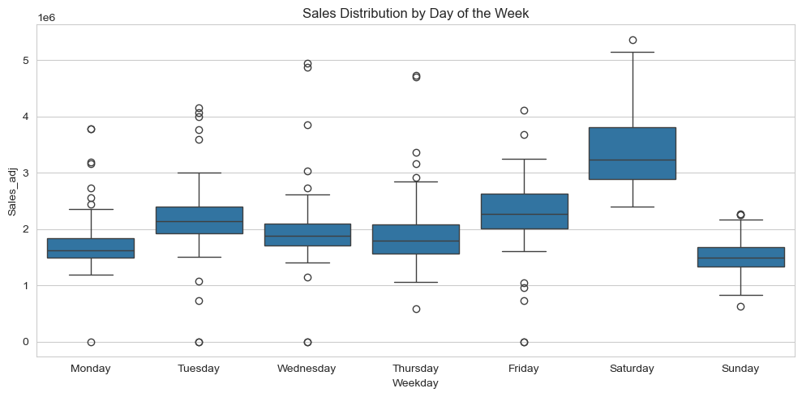

```
Kruskal-Wallis H = 666.26, p-value = 1.174e-140
```

```python
df_complete['Weekday'] = df_complete['Date'].dt.day_name()
weekday_order = ['Monday','Tuesday','Wednesday','Thursday','Friday','Saturday','Sunday']

fig, ax = plt.subplots(figsize=(10, 5))
sns.boxplot(data=df_complete, x='Weekday', y='Sales_adj', order=weekday_order, ax=ax)
ax.set_title('Sales Distribution by Day of the Week')
plt.tight_layout(); plt.show()

groups = [df_complete.loc[df_complete['Weekday'] == d, 'Sales_adj'].dropna() for d in weekday_order]
stat, p = kruskal(*groups)
print(f"Kruskal-Wallis H = {stat:.2f}, p-value = {p:.4g}")
```

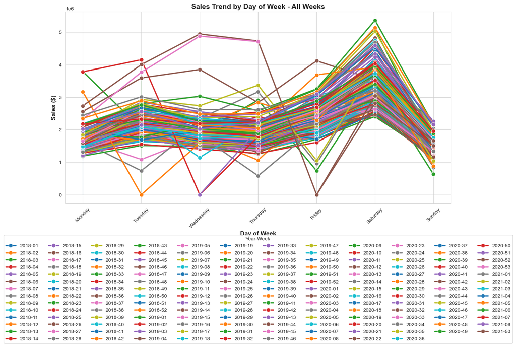

```python
# Ensure correct weekday order
weekday_order = ['Monday', 'Tuesday', 'Wednesday', 'Thursday', 'Friday', 'Saturday', 'Sunday']
df_chart1 = df_complete.copy()
df_chart1['Weekday'] = pd.Categorical(df_chart1['Weekday'], categories=weekday_order, ordered=True)
df_chart1['Year-Week'] = df_complete['Date'].dt.strftime('%Y-%V')
df_chart1 = df_chart1.sort_values(['Year-Week', 'Weekday'])

# Create line chart with all weeks
plt.figure(figsize=(14, 10))
sns.set_style("whitegrid")

# Plot each week as a separate line
for week in df_chart1['Year-Week'].unique():
    week_data = df_chart1[df_chart1['Year-Week'] == week]
    sns.lineplot(data=week_data, x='Weekday', y='Sales_adj',
                 marker='o', markersize=8, linewidth=2.5,
                 label=week)

plt.xlabel('Day of Week', fontsize=12, fontweight='bold')
plt.ylabel('Sales ($)', fontsize=12, fontweight='bold')
plt.title('Sales Trend by Day of Week - All Weeks', fontsize=14, fontweight='bold')
plt.xticks(rotation=45)
# plt.legend(bbox_to_anchor=(1.05, 1), loc='upper left', title='Year-Week')
# plt.legend([]) # no legend
# Place legend at bottom
plt.legend(bbox_to_anchor=(0.5, -0.15),  # Position at bottom center
           loc='upper center',           # Anchor point
           ncol=12,                      # Number of columns
           fontsize=10,
           title='Year-Week')
plt.tight_layout()
plt.show()
```

#### ▪️Notas

- Os valores de vendas de sábado são geralmente mais altos que o restante da semana.
- Com um p-valor ~ 0, podemos dizer que pelo menos um dia semana é diferente dos outros. Um resultado significatico que enforça a idéia de tratar o dia da semana como uma variável direcional estrutural, não ruído, como veremos no Passo A/E.

### Vendas vs. Mês

Mesma lógica que o dia da semana mas para o mês. Vamos olhar para isso não como uma série temporal mas se a variável "mês" como categorical que está relacionada com as Vendas independente de qualquer pressuposto de decomposição sazonal.

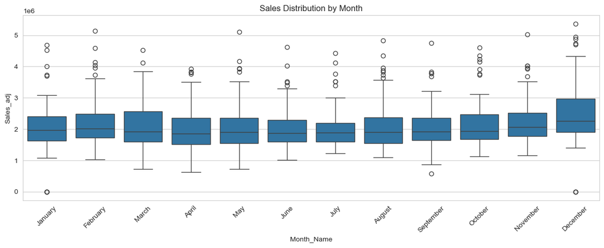

```
Kruskal-Wallis H = 36.95, p-value = 0.0001174
```

```python
df_complete['Month_Name'] = df_complete['Date'].dt.month_name()
month_order = ['January','February','March','April','May','June','July',
               'August','September','October','November','December']

fig, ax = plt.subplots(figsize=(12, 5))
sns.boxplot(data=df_complete, x='Month_Name', y='Sales_adj', order=month_order, ax=ax)
ax.set_title('Sales Distribution by Month')
plt.xticks(rotation=45)
plt.tight_layout(); plt.show()

groups = [df_complete.loc[df_complete['Month_Name'] == m, 'Sales_adj'].dropna() for m in month_order]
stat, p = kruskal(*groups)
print(f"Kruskal-Wallis H = {stat:.2f}, p-value = {p:.4g}")
```

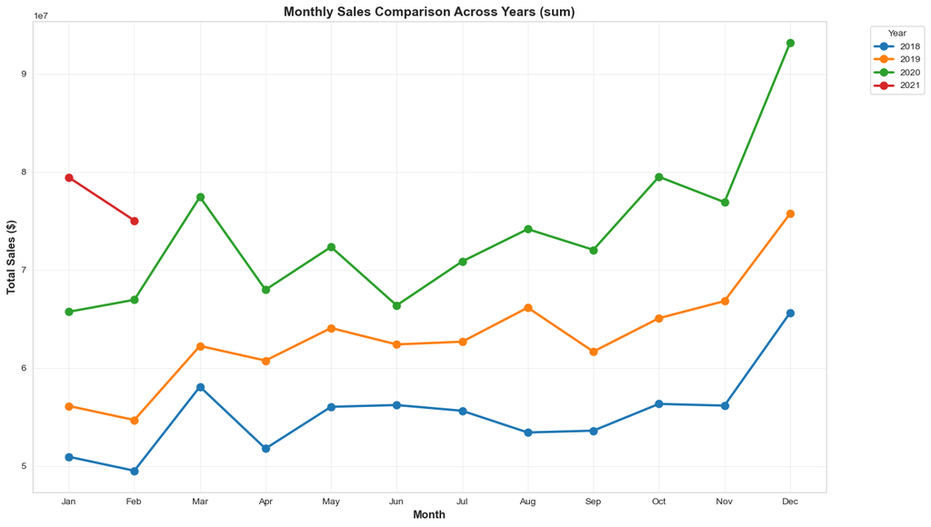

```python
# Prepare data for monthly aggregation
df_chart2 = df_complete.copy()

# Create year and month columns
df_chart2['Year'] = df_chart2['Date'].dt.year
df_chart2['Month'] = df_chart2['Date'].dt.month
df_chart2['Month_Name'] = df_chart2['Date'].dt.strftime('%b')  # Jan, Feb, Mar, etc.

# Aggregate sales by Year and Month (SUM)
monthly_sales = df_chart2.groupby(['Year', 'Month', 'Month_Name'])['Sales_adj'].sum().reset_index()

# Sort by month number
monthly_sales = monthly_sales.sort_values(['Year', 'Month'])

# Create the line chart
plt.figure(figsize=(14, 8))
sns.set_style("whitegrid")

# Plot each year as a separate line
years = monthly_sales['Year'].unique()
for year in years:
    year_data = monthly_sales[monthly_sales['Year'] == year]
    plt.plot(year_data['Month_Name'], year_data['Sales_adj'],
             marker='o', linewidth=2.5, markersize=8,
             label=str(year))

plt.xlabel('Month', fontsize=12, fontweight='bold')
plt.ylabel('Total Sales ($)', fontsize=12, fontweight='bold')
plt.title('Monthly Sales Comparison Across Years (sum)', fontsize=14, fontweight='bold')
plt.xticks(range(12), ['Jan', 'Feb', 'Mar', 'Apr', 'May', 'Jun',
                       'Jul', 'Aug', 'Sep', 'Oct', 'Nov', 'Dec'])
plt.legend(title='Year', bbox_to_anchor=(1.05, 1), loc='upper left')
plt.grid(True, alpha=0.3)
plt.tight_layout()
plt.show()
```

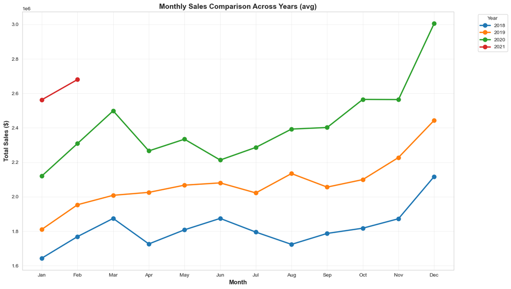

```python
# Prepare data for monthly aggregation
df_chart3 = df_complete.copy()

# Create year and month columns
df_chart3['Year'] = df_chart3['Date'].dt.year
df_chart3['Month'] = df_chart3['Date'].dt.month
df_chart3['Month_Name'] = df_chart3['Date'].dt.strftime('%b')  # Jan, Feb, Mar, etc.

# Aggregate sales by Year and Month (AVG)
monthly_sales = df_chart3.groupby(['Year', 'Month', 'Month_Name'])['Sales_adj'].mean().reset_index()

# Sort by month number
monthly_sales = monthly_sales.sort_values(['Year', 'Month'])

# Create the line chart
plt.figure(figsize=(14, 8))
sns.set_style("whitegrid")

# Plot each year as a separate line
years = monthly_sales['Year'].unique()
for year in years:
    year_data = monthly_sales[monthly_sales['Year'] == year]
    plt.plot(year_data['Month_Name'], year_data['Sales_adj'],
             marker='o', linewidth=2.5, markersize=8,
             label=str(year))

plt.xlabel('Month', fontsize=12, fontweight='bold')
plt.ylabel('Total Sales ($)', fontsize=12, fontweight='bold')
plt.title('Monthly Sales Comparison Across Years (avg)', fontsize=14, fontweight='bold')
plt.xticks(range(12), ['Jan', 'Feb', 'Mar', 'Apr', 'May', 'Jun',
                       'Jul', 'Aug', 'Sep', 'Oct', 'Nov', 'Dec'])
plt.legend(title='Year', bbox_to_anchor=(1.05, 1), loc='upper left')
plt.grid(True, alpha=0.3)
plt.tight_layout()
plt.show()
```

#### ▪️Notas

- Dezembro parece ter vendas mais altas que o restante do ano; fevereiro similar, mas em menor escala.
- Lembre que temos en torno de ~3 observações para cada mês (1 por ano), e tratar qualquer resultado como "significativo" deve ser feito de forma cautelosa, já que pode ser consistente mas não prova um genuíno padrão anual.
- **Teste Kruskal-Wallis**: Com p-valor ~ 0, podemos dizer que pelo menos um mês é diferente dos outros.
- **Question**
  - *Podemos criar um index sazonal mensal para capturar essa sazonalidade e não focar somente na tendência semanal?*

```
Jan    0.955
Feb    1.023
Mar    0.999
Apr    0.942
May    0.972
Jun    0.965
Jul    0.955
Aug    0.978
Sep    0.977
Oct    1.014
Nov    1.043
Dec    1.184
Name: Sales_adj, dtype: float64
```

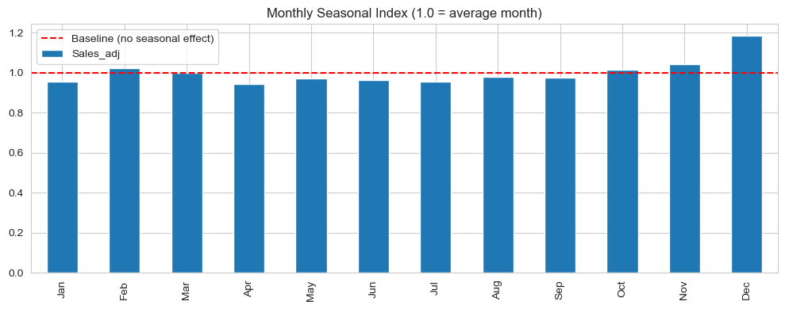

```python
# Monthly seasonal index: average sales per month, normalized to a baseline of 1.0
monthly_avg = df_complete.groupby(df_complete['month'])['Sales_adj'].mean()
overall_avg = df_complete['Sales_adj'].mean()

seasonal_index = (monthly_avg / overall_avg).round(3)
seasonal_index_byMonth = seasonal_index.copy()
seasonal_index_byMonth.index = ['Jan','Feb','Mar','Apr','May','Jun','Jul','Aug','Sep','Oct','Nov','Dec']
print(seasonal_index_byMonth)

fig, ax = plt.subplots(figsize=(10,4))
seasonal_index_byMonth.plot(kind='bar', ax=ax)
ax.axhline(1.0, color='red', linestyle='--', label='Baseline (no seasonal effect)')
ax.set_title('Monthly Seasonal Index (1.0 = average month)')
ax.legend(); plt.tight_layout(); plt.show()
```

### Vendas vs. Todas as Flags: Correlação Consolidada

Uma única matriz de correlação, tratando as flags binárias como numéricas 0/1 junto com `Sales_adj`, oferece uma visão consolidada de todas as relações bivariadas cobertas até agora (flag vs. flag e agora flag vs. alvo) em um só lugar.

- A correlação ponto-bisserial (Pearson em flag 0/1) é um resumo linear razoável aqui, mas tenha em mente que pode subestimar um efeito real se a relação não for linear, cruzar com os resultados de boxplot/Mann-Whitney em vez de confiar apenas nesta tabela.

```
           Sales_adj  Feriado  Pagamento   Vale  isClosed
Sales_adj      1.000   -0.059      0.047  0.001    -0.220
Feriado       -0.059    1.000     -0.037 -0.017    -0.015
Pagamento      0.047   -0.037      1.000 -0.039    -0.015
Vale           0.001   -0.017     -0.039  1.000    -0.016
isClosed      -0.220   -0.015     -0.015 -0.016     1.000
```

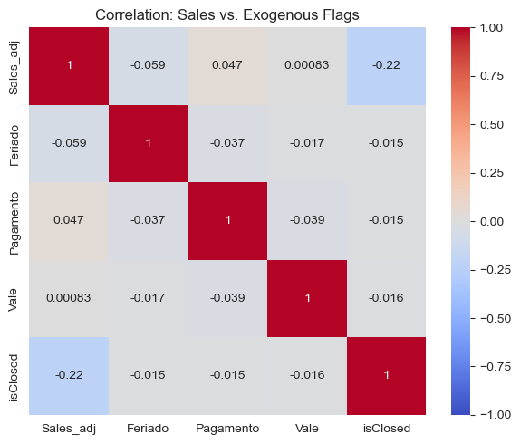

```python
corr_vars = ['Sales_adj', 'Feriado', 'Pagamento', 'Vale', 'isClosed']

corr_matrix = df_complete[corr_vars].corr()
print(corr_matrix.round(3))

fig, ax = plt.subplots(figsize=(6, 5))
sns.heatmap(corr_matrix, annot=True, cmap='coolwarm', center=0, ax=ax, vmin=-1, vmax=1)
ax.set_title('Correlation: Sales vs. Exogenous Flags')
plt.tight_layout(); plt.show()
```

### ▫️Seção Final Notas

- O índice sazonal mensal analisado anteriormente (dez. 1,184; nov. 1,043; abr. 0,942; etc.) foi calculado utilizando todo o intervalo de datas disponível até aquele ponto do notebook, o que inclui o período de *holdout* (jan.–fev./2021). Utilizá-lo da forma como está resultaria no vazamento de informações do *holdout* para uma variável (*feature*) empregada posteriormente na modelagem.
- **Decisão**: `Seasonal_Index` será adicionada como coluna a `df_complete` apenas após a divisão treino/holdout do Passo B, calculada apenas de `ts_train` e depois mapeada para todas as linhas (treino, holdout e futuro). Isso evita qualquer vazamento de holdout, mantendo a feature disponível para a comparação SARIMAX planejada no Passo F2.
- **Resumo: variáveis ainda necessárias para o dataset de previsão futura**: A Parte 1 derivou várias regras e features dos dados históricos, mas nenhuma delas existe ainda para datas futuras (ex.: março/2021). A tabela abaixo consolida tudo o que deve ser reconstruído quando o dataset futuro for construído no Passo J.

| Variable | Regra de origem | Status |
| --- | --- | --- |
| `isClosed` | Fechada todo 25 de dezembro e 1º de janeiro (verificação determinística de data) | Regra definida, pronta para aplicar |
| `Feriado` | Corresponder a nomes de feriados conhecidos de `holidays.csv` (17 nomes confirmados) | Regra definida, pronta para aplicar |
| `Pagamento` | 3º ou 4º dia útil do mês (dia útil = seg–sex, excluindo `Feriado`/`isClosed`) | Regra definida (`get_payment_date()`), ~68–76% de acurácia histórica |
| `Vale` | 17º dia útil do mês; também 16º em nov/dez | Regra definida (`get_vale_date()`), ~63,8–68% de acurácia histórica |
| `Seasonal_Index` | Índice mensal (Dez 1,184, Nov 1,043, Abr 0,942 etc.) | Adiado — calculado apenas de `ts_train` (após divisão do Passo B) e mapeado para datas futuras por mês, conforme a decisão acima |

- `Pagamento` e `Vale` são as duas flags com regras de reconstrução imperfeitas; qualquer previsão para um período futuro herda essa incerteza, uma vez que o modelo será condicionado a dias de evento *previstos* em vez de *reais*. Vale a pena reiterar essa limitação ao interpretar o erro de previsão na Etapa I/J.

# 🔹**PARTE 2**: Análise de Séries Temporais

## 🔸Passo A: Análise Visual da Série

Reunindo a análise visual/estatística completa do Passo A (gráficos originais + estabilidade de variância, ACF de longo alcance, heatmap de calendário, sobreposição ano a ano, scatterplots de defasagem) em uma visão consolidada antes de passar ao Passo B.

- Full Series
- Primeiros 90 dias
- Últimos 90 dias
- Decomposição Aditiva
- Decomposição Multiplicativa

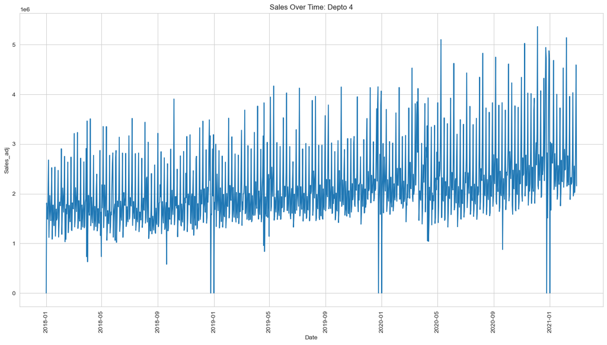

```python
# full series
plt.figure(figsize=(14, 8))
sns.lineplot(data=df_complete, x='Date', y='Sales_adj')
plt.title(f"Sales Over Time: {choose_dept}")
plt.xticks(rotation=90)
plt.tight_layout()
plt.show()
```

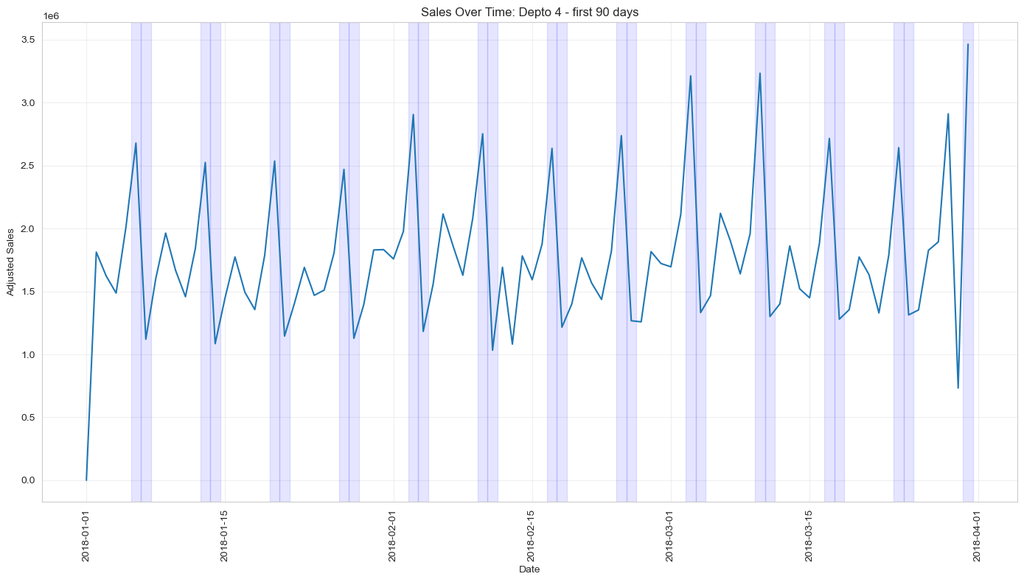

```python
# First 90 days
period_90f = df_complete.head(90).copy()

plt.figure(figsize=(14, 8))
sns.lineplot(data=period_90f, x='Date', y='Sales_adj')

# Highlight weekends (Saturday=5, Sunday=6)
for date in period_90f['Date'].unique():
    if date.weekday() >= 5:  # Saturday or Sunday
        plt.axvspan(date - pd.Timedelta(hours=12),
                   date + pd.Timedelta(hours=12),
                   alpha=0.1, color='blue')

plt.title(f"Sales Over Time: {choose_dept} - first 90 days")
plt.xlabel("Date")
plt.ylabel("Adjusted Sales")
plt.xticks(rotation=90)
plt.grid(True, alpha=0.3)
plt.tight_layout()
plt.show()
```

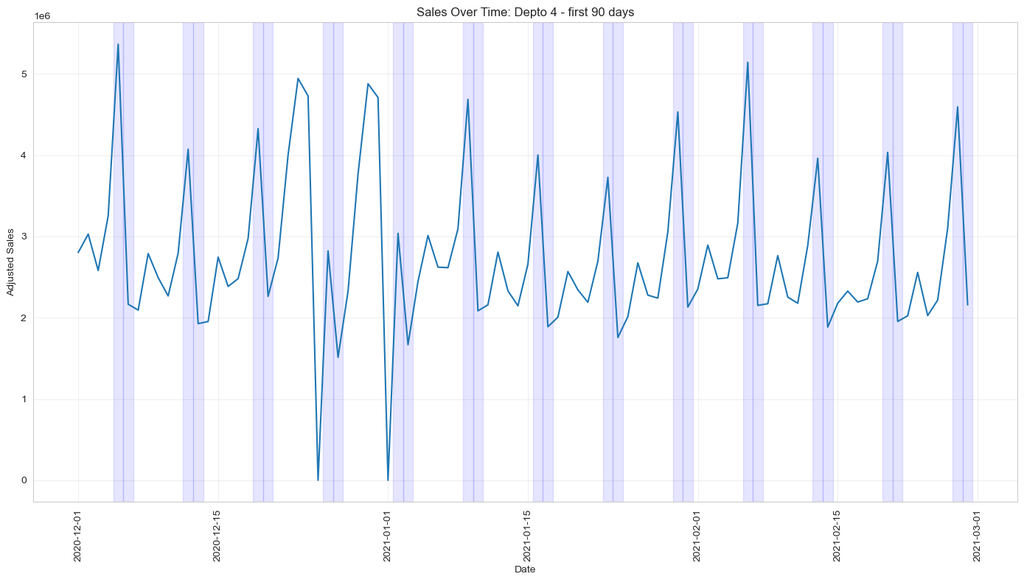

```python
# Last 90 days
period_90l = df_complete.tail(90).copy()

plt.figure(figsize=(14, 8))
sns.lineplot(data=period_90l, x='Date', y='Sales_adj')

# Highlight weekends (Saturday=5, Sunday=6)
for date in period_90l['Date'].unique():
    if date.weekday() >= 5:  # Saturday or Sunday
        plt.axvspan(date - pd.Timedelta(hours=12),
                   date + pd.Timedelta(hours=12),
                   alpha=0.1, color='blue')

plt.title(f"Sales Over Time: {choose_dept} - first 90 days")
plt.xlabel("Date")
plt.ylabel("Adjusted Sales")
plt.xticks(rotation=90)
plt.grid(True, alpha=0.3)
plt.tight_layout()
plt.show()
```

### Decomposição Aditiva vs. Multiplicativa

Comparar lado a lado ambos os modelos de decomposição ajuda a responder à questão em aberto da Etapa A: se os efeitos de tendência/sazonalidade adicionam um valor constante ou se escalam proporcionalmente ao nível. A decomposição multiplicativa exige valores estritamente positivos; portanto, quaisquer zeros exatos (por exemplo, em dias marcados como `isClosed`) são substituídos por um valor infinitesimal (épsilon) antes da decomposição, isso afeta apenas a viabilidade de execução da versão multiplicativa, e não os dados originais.

```
Zeros replaced: 7
Remaining non-positive values: 0
```

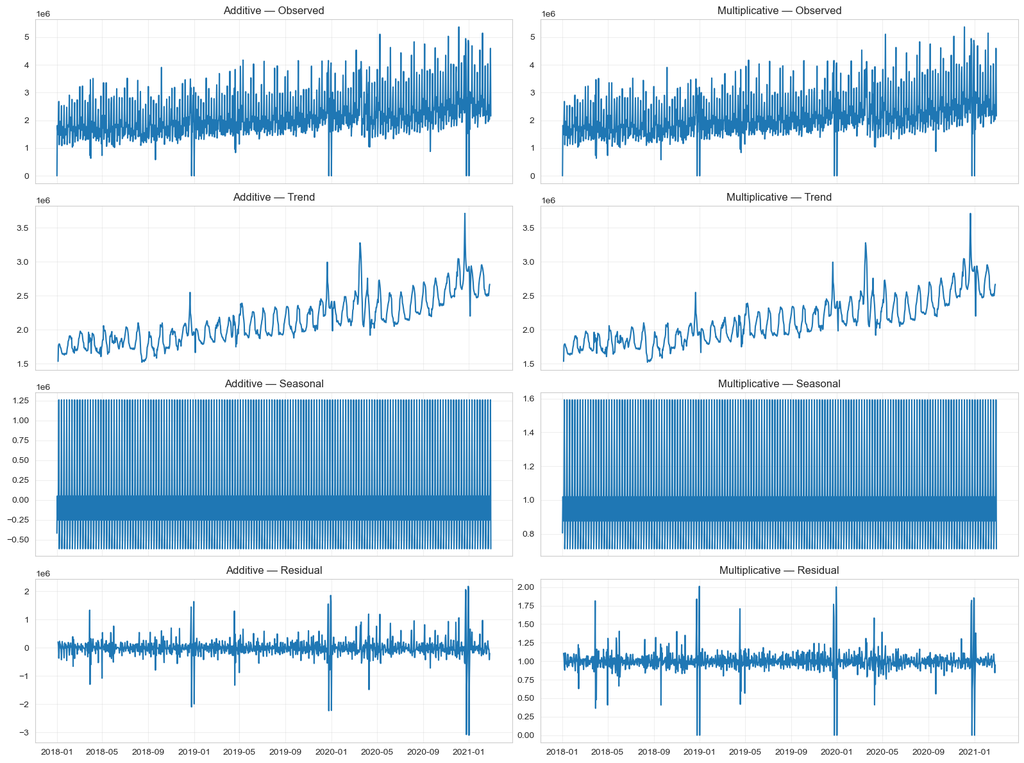

```python
# Ensure ts exists before decomposing
ts = df_complete.set_index('Date')['Sales_adj']

# Replace exact zeros with a small epsilon so multiplicative decomposition can run
ts_for_decomp = ts.copy()
ts_for_decomp = ts_for_decomp.where(ts_for_decomp != 0, 0.000001)

print(f"Zeros replaced: {(ts == 0).sum()}")
print(f"Remaining non-positive values: {(ts_for_decomp <= 0).sum()}")

decomp_add = seasonal_decompose(ts_for_decomp, model='additive', period=7)
decomp_mul = seasonal_decompose(ts_for_decomp, model='multiplicative', period=7)

fig, axes = plt.subplots(4, 2, figsize=(16, 12), sharex=True)

for col, decomp, title in [(0, decomp_add, 'Additive'), (1, decomp_mul, 'Multiplicative')]:
    axes[0, col].plot(decomp.observed); axes[0, col].set_title(f'{title} — Observed')
    axes[1, col].plot(decomp.trend); axes[1, col].set_title(f'{title} — Trend')
    axes[2, col].plot(decomp.seasonal); axes[2, col].set_title(f'{title} — Seasonal')
    axes[3, col].plot(decomp.resid); axes[3, col].set_title(f'{title} — Residual')
    for row in range(4):
        axes[row, col].grid(alpha=0.3)

plt.tight_layout(); plt.show()
```

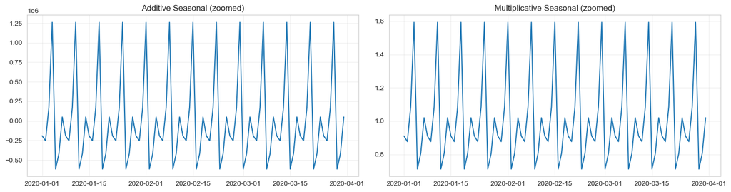

```python
fig, axes = plt.subplots(1, 2, figsize=(15, 4))

zoom_start, zoom_end = '2020-01-01', '2020-03-31'

axes[0].plot(decomp_add.seasonal.loc[zoom_start:zoom_end])
axes[0].set_title('Additive Seasonal (zoomed)')
axes[0].grid(alpha=0.3)

axes[1].plot(decomp_mul.seasonal.loc[zoom_start:zoom_end])
axes[1].set_title('Multiplicative Seasonal (zoomed)')
axes[1].grid(alpha=0.3)

plt.tight_layout(); plt.show()
```

## 🔸Passo B: Treino / Holdout

**Objetivo**: dividir a série em um conjunto de treinamento (até dez/2020) e um conjunto de validação (jan–fev/2021), correspondendo à Descrição dos Dados. A partir deste ponto, toda a identificação, estimação e diagnóstico (Etapas C–H) utilizam apenas o conjunto `ts_train`, e o conjunto de validação permanece intacto até a Etapa I.

**Nota:** os dados de treinamento representam o desempenho histórico "conhecido" usado para ajustar o modelo; o conjunto de validação simula dados "futuros" para validar a precisão antes de ser usado na previsão de março de 2021.

```python
# Define dates for the split
train_end = '2020-12-31'
holdout_start = '2021-01-01'
holdout_end = '2021-02-28'
```

### ➕Aplicando a Substituição por Epsilon

Como `df_complete` carrega as variáveis exógenas junto com as vendas (necessárias para o SARIMAX do Passo F2), a substituição por epsilon é aplicada aqui diretamente em `Sales_adj`, e não apenas na série isolada `ts`. Isso mantém `ts`/`ts_train`/`ts_holdout` e `exog_train`/`exog_holdout` construídos a partir da mesma fonte consistente daqui em diante.

```python
EPSILON = 0.000001

n_zero_before = (df_complete['Sales_adj'] == 0).sum()
df_complete['Sales_adj'] = df_complete['Sales_adj'].where(df_complete['Sales_adj'] != 0, EPSILON)
n_zero_after = (df_complete['Sales_adj'] == 0).sum()

print(f"Zeros before: {n_zero_before}, zeros after: {n_zero_after}")
print(f"Min value: {df_complete['Sales_adj'].min():.6f}")
```

```
Zeros before: 7, zeros after: 0
Min value: 0.000001
```

#### ▪️Notas

- Substituição agora aplicada na fonte (`df_complete['Sales_adj']`), não apenas na série derivada `ts` — isso significa que `exog_train`/`exog_holdout` construídos depois a partir de `df_complete` para o Passo F2 permanecerão consistentes com `ts_train`/`ts_holdout`.
- `ts`, `ts_train`, `ts_holdout` são reconstruídos a partir de `df_complete` após a substituição, usando os mesmos limites `train_end`/`holdout_start`/`holdout_end` do início do Passo B.
- Confirmar que restam 0 zeros / 0 negativos nas três séries.
- Trade-off a notar: `df_complete['Sales_adj']` não preserva mais o fato literal de "0 vendas nos dias isClosed" diretamente nessa coluna — mas `isClosed` permanece como flag separada, então essa informação não se perde, apenas é representada de forma diferente (flag + valor próximo de zero em vez de flag + zero exato).

### ➕Adicionando Índice de Sazonalidade por Mês

Vamos recalcular e adicionar o índice de sazonalidade por mês usando apenas o conjunto de dados de treinamento.

```python
df_complete_train = df_complete[df_complete['Date'] <= train_end]

monthly_avg_train = df_complete_train.groupby(df_complete['month'])['Sales_adj'].mean()
overall_avg_train = df_complete_train['Sales_adj'].mean()

seasonal_index_train = (monthly_avg_train / overall_avg_train).round(3)
print('Train Dataset Seasonality Index:')
print(seasonal_index_train)
```

```
Train Dataset Seasonality Index:
month
1     0.883
2     0.957
3     1.011
4     0.954
5     0.984
6     0.977
7     0.967
8     0.990
9     0.990
10    1.027
11    1.056
12    1.199
Name: Sales_adj, dtype: float64
```

```python
print('Full Dataset Seasonality Index:')
print(seasonal_index)
```

```
Full Dataset Seasonality Index:
month
1     0.955
2     1.023
3     0.999
4     0.942
5     0.972
6     0.965
7     0.955
8     0.978
9     0.977
10    1.014
11    1.043
12    1.184
Name: Sales_adj, dtype: float64
```

```python
# Adding seasonality index to the main DF
df_complete['Seasonal_Index'] = df_complete['Date'].dt.month.map(seasonal_index_train)

print(df_complete[['Date', 'Seasonal_Index']].head())
print(f"\nMissing values: {df_complete['Seasonal_Index'].isna().sum()}")
```

```
        Date  Seasonal_Index
0 2018-01-01           0.883
1 2018-01-02           0.883
2 2018-01-03           0.883
3 2018-01-04           0.883
4 2018-01-05           0.883

Missing values: 0
```

#### ▪️Notas

Comparação entre o índice do dataset completo vs. dataset de treino.

- A maioria dos meses (mar–dez) muda apenas ligeiramente (~+0,01–0,02) entre o índice do dataset completo e o apenas-treino.
  - ruído esperado por excluir 2 de 38 meses.
- Jan e fev mudam de forma mais substancial: jan cai de 0,955 para 0,883, e fev passa de *acima* da baseline (1,023) para *abaixo* da baseline (0,957).
  - Isso indica que jan–fev/2021 (o período de holdout) teve desempenho atipicamente forte em relação ao padrão típico de 2018–2020 para esses meses.
- Isso é uma boa validação da abordagem apenas-treino: se o índice do dataset completo tivesse sido usado, o `Seasonal_Index` de fev teria sido informado pelos próprios dados usados para julgar a acurácia do holdout no Passo I, e teria superestimado o quão forte fevereiro tipicamente é.
- Implicação prática: espera-se que a avaliação de validação (Etapa I) mostre que o modelo subestimou um pouco as vendas de janeiro/fevereiro de 2021, uma vez que o índice de sazonalidade (apenas trens) considera esses meses como abaixo da média, enquanto os dados reais de validação foram atipicamente fortes.

| Month_nbr | Month | Full Dataset | Treino Dataset | Delta |
| --- | --- | --- | --- | --- |
| 1 | Jan | 0.955 | 0.883 | -0.072 |
| 2 | Feb | 1.023 | 0.957 | -0.066 |
| 3 | Mar | 0.999 | 1.011 | 0.012 |
| 4 | Apr | 0.942 | 0.954 | 0.012 |
| 5 | May | 0.972 | 0.984 | 0.012 |
| 6 | Jun | 0.965 | 0.977 | 0.012 |
| 7 | Jul | 0.955 | 0.967 | 0.012 |
| 8 | Aug | 0.978 | 0.99 | 0.012 |
| 9 | Sep | 0.977 | 0.99 | 0.013 |
| 10 | Oct | 1.014 | 1.027 | 0.013 |
| 11 | Nov | 1.043 | 1.056 | 0.013 |
| 12 | Dec | 1.184 | 1.199 | 0.015 |

### → Divisão Treino / Holdout

Por que essa divisão importa para o negócio:

- Os dados de treinamento representam o desempenho histórico "conhecido" usado para construir o modelo.
- Os dados de holdout (jan-fev 2021) simulam dados "futuros" para validar a acurácia do modelo antes da implantação
- Essa abordagem garante que nosso modelo terá um bom desempenho com dados reais futuros (previsão para março de 2021)

```
Train:   2018-01-01 to 2020-12-31  (1096 obs)
Holdout: 2021-01-01 to 2021-02-28  (59 obs)
```

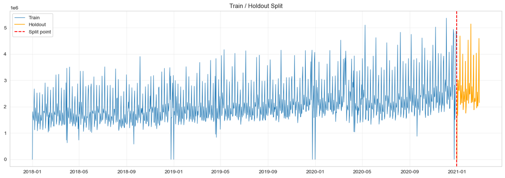

```python
ts = df_complete.set_index('Date')['Sales_adj']

ts_train = ts.loc[:train_end]
ts_holdout = ts.loc[holdout_start:holdout_end]

print(f"Train:   {ts_train.index.min().date()} to {ts_train.index.max().date()}  ({len(ts_train)} obs)")
print(f"Holdout: {ts_holdout.index.min().date()} to {ts_holdout.index.max().date()}  ({len(ts_holdout)} obs)")

fig, ax = plt.subplots(figsize=(14, 5))
ax.plot(ts_train.index, ts_train.values, label='Train', linewidth=0.8)
ax.plot(ts_holdout.index, ts_holdout.values, label='Holdout', color='orange', linewidth=1.2)
ax.axvline(pd.Timestamp(train_end), color='red', linestyle='--', label='Split point')
ax.legend(); ax.set_title('Train / Holdout Split'); ax.grid(alpha=0.3)
plt.tight_layout(); plt.show()
```

## 🔸Passo C: Verificação de Ruído Branco

**Objetivo**: confirmar que `ts_train` não é ruído branco antes de investir mais em um modelo, se fosse, nenhum modelo conseguiria superar uma previsão ingênua de média/último valor, e as etapas D–J seriam irrelevantes.

### Teste de Ljung-Box

- H0: Series is ruído branco (no autocorrelation at the tested lags).
- H1: tem estrutura explorável.
- Decisão rule: p-valor < 0,05 em qualquer defasagem → rejeitar H0.

```python
lb_test = acorr_ljungbox(ts_train, lags=[7, 14, 21, 30], return_df=True)
print(lb_test)
```

```
        lb_stat      lb_pvalue
7    784.673580  3.763896e-165
14  1410.837138  7.545037e-293
21  2050.686255   0.000000e+00
30  2771.851178   0.000000e+00
```

#### ▪️Notas

Executamos o teste Ljung-Box para diferentes atrasos a fim de verificar se encontraríamos um ruído branco nos atrasos mais comuns em uma série diária.

- Em todas as defasagens, p-valor < 0,05, rejeitando a hipótese nula.
- A série não é um ruído branco, existem claramente padrões que podemos prever com um modelo de séries temporais.

### ACF Plot for Verificação de Ruído Branco

Um complemento visual ao teste de Ljung-Box — uma série de ruído branco mostraria (quase) todas as barras dentro da banda de confiança.

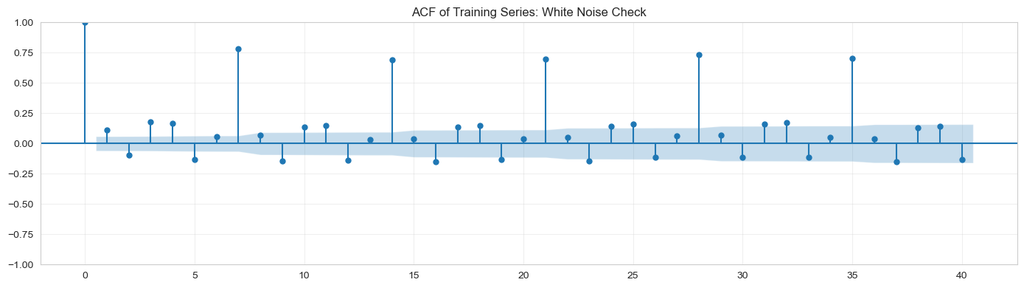

```python
fig, ax = plt.subplots(figsize=(14, 4))
plot_acf(ts_train.dropna(), lags=40, ax=ax, alpha=0.05)
ax.set_title('ACF of Training Series: White Noise Check')
ax.grid(alpha=0.3)
plt.tight_layout(); plt.show()
```

#### ▪️Notas

- A defasagem 7 (e múltiplos de 7) são as que caem fora da banda de confiança, mostrando que é um sinal dominante também no dataset de treino.
- Outras defasagens 3, 4, 5 também caem fora da banda de confiança, mas estão bem próximas, enquanto a defasagem 7 é 3/4 vezes maior.

## 🔸Passo D: Verificação de Estacionariedade

**Objetivo:** determinar se `ts_train` é estacionário e, caso contrário, quanta diferenciação (`d`, sazonalidade `D`) é necessária antes que ARIMA/SARIMA (Etapa F2) possa ser aplicada. O alisamento exponencial (Etapa F1) não requer estacionariedade, mas isso ainda é importante para a escolha entre as duas famílias.

### Teste de Dickey-Fuller Aumentado (ADF)

- H0: a série tem raiz unitária (não estacionária).
- H1: a série é estacionária.
- Decisão rule: p-valor < 0,05 → rejeitar H0 → estacionária.

```python
def run_adf(series, label=''):
    result = adfuller(series.dropna())
    print(f"ADF Test: {label}")
    print(f"  ADF Statistic: {result[0]:.4f}")
    print(f"  p-value: {result[1]:.4f}")
    for k, v in result[4].items():
        print(f"  Critical Value ({k}): {v:.4f}")
    conclusion = 'Stationary' if result[1] < 0.05 else 'Non-stationary'
    print(f"  Conclusion: {conclusion} (alpha = 0.05)\n")
    return result

run_adf(ts_train, 'Sales_adj (level)')
```

```
ADF Test: Sales_adj (level)
  ADF Statistic: -1.6217
  p-value: 0.4718
  Critical Value (1%): -3.4364
  Critical Value (5%): -2.8642
  Critical Value (10%): -2.5682
  Conclusion: Non-stationary (alpha = 0.05)
```

```
(np.float64(-1.621719421817511),
 np.float64(0.4718279861636461),
 20,
 1075,
 {'1%': np.float64(-3.4364476591811033),
  '5%': np.float64(-2.864232347211692),
  '10%': np.float64(-2.5682035004867494)},
 np.float64(30768.06386295903))
```

#### ▪️Notas

- **Result**: Estatística ADF = -1,6217, p-valor = 0,4718 → falha em rejeitar H0 → **não estacionária** no nível.

Isso era esperado, dada a tendência ascendente confirmada na Etapa A; uma média não constante é exatamente o que o teste ADF está detectando. - Diferenciação é necessária antes do Passo F2 (ARIMA/SARIMA); - O Passo F1 (suavização exponencial) ainda pode trabalhar diretamente na série em nível, pois não exige estacionariedade.

### Diferenciação se Necessário

Se a série de níveis não for estacionária, teste a diferenciação regular e sazonal (s=7, a partir da sazonalidade semanal confirmada na Etapa A).

```python
ts_diff1 = ts_train.diff().dropna()
run_adf(ts_diff1, 'after 1st regular difference (d=1)')

ts_seasdiff = ts_train.diff(7).dropna()
run_adf(ts_seasdiff, 'after seasonal difference (D=1, s=7)')

ts_diff1_seasdiff = ts_train.diff().diff(7).dropna()
run_adf(ts_diff1_seasdiff, 'after regular + seasonal difference (d=1, D=1, s=7)')
```

```
ADF Test: after 1st regular difference (d=1)
  ADF Statistic: -14.6082
  p-value: 0.0000
  Critical Value (1%): -3.4364
  Critical Value (5%): -2.8642
  Critical Value (10%): -2.5682
  Conclusion: Stationary (alpha = 0.05)

ADF Test: after seasonal difference (D=1, s=7)
  ADF Statistic: -13.1424
  p-value: 0.0000
  Critical Value (1%): -3.4365
  Critical Value (5%): -2.8643
  Critical Value (10%): -2.5682
  Conclusion: Stationary (alpha = 0.05)

ADF Test: after regular + seasonal difference (d=1, D=1, s=7)
  ADF Statistic: -12.5931
  p-value: 0.0000
  Critical Value (1%): -3.4365
  Critical Value (5%): -2.8643
  Critical Value (10%): -2.5682
  Conclusion: Stationary (alpha = 0.05)
```

```
(np.float64(-12.593110435000636),
 np.float64(1.8030398783407628e-23),
 22,
 1065,
 {'1%': np.float64(-3.4365050530846846),
  '5%': np.float64(-2.864257662806096),
  '10%': np.float64(-2.568216983623179)},
 np.float64(30595.863570191126))
```

### Escolhendo Entre d=1, D=1 e d=1+D=1

Todas as três séries diferenciadas passam no ADF, então o teste ADF sozinho não pode decidir, ele detecta raízes unitárias, não sazonalidade. O ACF de cada candidato abaixo mostra se o padrão semanal (defasagem 7) ainda está presente após cada escolha de diferenciação, e se aparecem artefatos de sobrediferenciação (um pico negativo acentuado na defasagem 1).

- Insight principal: qual escolha de diferenciação remove o pico da defasagem 7 sem introduzir artefatos de sobrediferenciação?

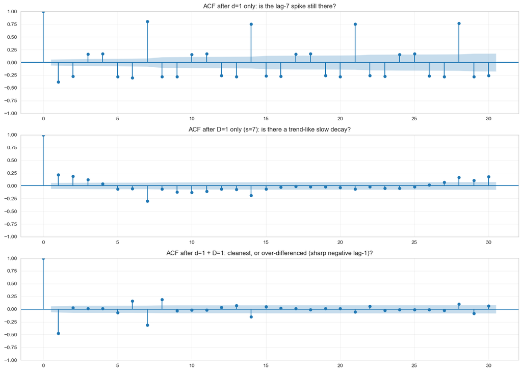

```python
fig, axes = plt.subplots(3, 1, figsize=(14, 10))

plot_acf(ts_diff1, lags=30, ax=axes[0], alpha=0.05)
axes[0].set_title('ACF after d=1 only: is the lag-7 spike still there?')
axes[0].grid(alpha=0.3)

plot_acf(ts_seasdiff, lags=30, ax=axes[1], alpha=0.05)
axes[1].set_title('ACF after D=1 only (s=7): is there a trend-like slow decay?')
axes[1].grid(alpha=0.3)

plot_acf(ts_diff1_seasdiff, lags=30, ax=axes[2], alpha=0.05)
axes[2].set_title('ACF after d=1 + D=1: cleanest, or over-differenced (sharp negative lag-1)?')
axes[2].grid(alpha=0.3)

plt.tight_layout(); plt.show()
```

### Determinar os Parâmetros d e D

- **d = 0** (nenhuma diferenciação regular necessária)
- **D = 1**, **s = 7** (sazonal differencing only)

**Reasoning**:

- `d=1` sozinho deixa a sazonalidade semanal completamente intacta (picos claros nos lags 7, 14, 21, 28), a diferenciação regular remove a tendência, não o ciclo semanal.
- `D=1` sozinho alcança estacionariedade (ADF) e produz o ACF mais limpo dos três candidatos — a maioria das defasagens cai dentro da banda de confiança, restando apenas um pico suave na defasagem 1 (~0,22) e na defasagem 7 (~-0,3).
- `d=1 + D=1` combinados mostram um forte pico negativo na defasagem 1 (-0,48), assinatura clássica de sobrediferenciação, consistente com a estatística ADF *mais fraca* do caso combinado (-12,59) vs. apenas d=1 (-14,61).
- Os dois picos restantes no painel D=1 (atraso leve de 1 e atraso de 7) são informativos, e não problemáticos; eles ajudarão a identificar os termos AR/MA e AR/MA sazonal (p, q, P, Q) na Etapa F2, usando essa mesma série diferenciada.

## 🔸Passo E: Identificação de Componentes (tendência, sazonalidade, ciclo)

**Objetivo**: consolidar formalmente o que já foi estabelecido (Etapas A, B, D) em componentes nomeados (tendência, sazonalidade, ciclo) e confirmar a única questão em aberto: o efeito de novembro/dezembro se repete todos os anos ou foi impulsionado por um único ano?

### Trend / Tendência

Já estabelecido no Passo A: crescimento sustentado (+43,7% 2018→2021 | +32,8% 2018→2020), e a decomposição aditiva versus multiplicativa mostrou que o resíduo do modelo multiplicativo permaneceu mais estável ao longo do tempo, apoiando uma tendência cujo tamanho *absoluto* cresce juntamente com o nível, e não um valor fixo em dólares por período.

```python
yearly_avg = df_complete[df_complete['Date'] <= train_end].groupby('year')['Sales_adj'].mean()
print(yearly_avg)

first_year, last_year = yearly_avg.index.min(), yearly_avg.index.max()
growth_pct = (yearly_avg[last_year] - yearly_avg[first_year]) / yearly_avg[first_year] * 100

print(f"\nAvg daily sales {first_year}: {yearly_avg[first_year]:,.2f}")
print(f"Avg daily sales {last_year}: {yearly_avg[last_year]:,.2f}")
print(f"Growth: {growth_pct:+.1f}%")

# Caveat check: is the last year a full year, or partial?
days_in_last_year = df_complete[(df_complete['Date'] <= train_end) & (df_complete['year'] == last_year)].shape[0]
print(f"\nDays counted in {last_year}: {days_in_last_year} (full year = 365/366)")
```

```
year
2018    1.817821e+06
2019    2.078317e+06
2020    2.414307e+06
Name: Sales_adj, dtype: float64

Avg daily sales 2018: 1,817,821.37
Avg daily sales 2020: 2,414,307.29
Growth: +32.8%

Days counted in 2020: 366 (full year = 365/366)
```

#### ▪️Notas

- **Result**: A média de vendas diárias cresceu de **R$ 1,8M** (2018) para **R$ 2,4M** (2020): aumento de **+32,8%**, comparando dois anos calendário completos (365 e 366 dias, respectivamente).
- A análise do Passo B já mostrou que jan–fev/2021 foi atipicamente forte em relação ao padrão típico.
- O ano de 2019 situa-se entre os dois (US$ 2 milhões), sugerindo um crescimento anual bastante estável, em vez de um salto anômalo, consistente com a suave linha de tendência ascendente observada nos gráficos da Etapa A.

### Análise do Componente Sazonal

A sazonalidade semanal (`s=7`) já está confirmada (ACF da Etapa A, ADF/ACF da Etapa D na série diferenciada D=1). O que ainda está em aberto: o padrão de novembro/dezembro (Índice Sazonal 1,056/1,199 da Etapa B) é uma sazonalidade anual genuína ou resulta apenas de um ou dois anos atípicos?

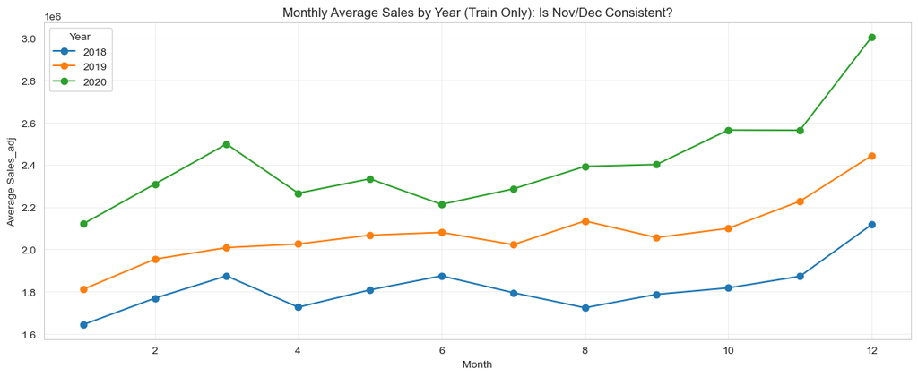

```python
df_complete['Year'] = df_complete['Date'].dt.year

monthly_by_year = df_complete[df_complete['Date'] <= train_end].groupby(
    ['Year', 'month']
)['Sales_adj'].mean().unstack(level=0)

fig, ax = plt.subplots(figsize=(12, 5))
monthly_by_year.plot(ax=ax, marker='o')
ax.set_title('Monthly Average Sales by Year (Train Only): Is Nov/Dec Consistent?')
ax.set_xlabel('Month'); ax.set_ylabel('Average Sales_adj')
ax.legend(title='Year')
ax.grid(alpha=0.3)
plt.tight_layout(); plt.show()
```

#### ▪️Notas

- Os aumentos em dezembro ocorreram nos três anos de treinamento (2018, 2019, 2020), e um padrão consistente ao longo dos anos reforça a ideia de que o `Índice Sazonal` é um componente sazonal genuíno, e não um evento isolado.
- *Ressalva*: com apenas 3 anos de dados de treinamento, temos 3 observações por mês, o suficiente para detectar uma grande inconsistência, mas não para descartar uma variação anual mais sutil.

### Cycle / Ciclo

Ciclo refere-se a flutuações com duração superior a um ano que não estão vinculadas a um período fixo do calendário (por exemplo, ciclos de negócios plurianuais). Com apenas cerca de 3 anos de dados de treinamento, é difícil separar isso da tendência.

#### ▪️Notas

- Com dados de 3 anos, um ciclo (que, por definição, opera em uma escala de tempo superior a um ano e não possui período fixo) não pode ser distinguido de forma confiável da própria tendência.
- **Conclusão razoável**: nenhum componente de ciclo é modelado separadamente. Seus efeitos, se houver, são absorvidos pelo termo de tendência.

### Resumo da Identificação de Componentes de Negócio

[output not shown]

**Implicação para o Passo F**: a série exige

1. um modelo que lida com tendência e sazonalidade semanal, SARIMA com `D=1, s=7` (Etapa D) ou Holt-Winters com tendência multiplicativa/sazonal (decomposição Etapa A) e
2. `Pagamento` como candidato principal a regressor exógeno, com `Feriado` como secundário que vale testar apesar da significância limítrofe.

## 🔸Passo F: Ajuste de Modelos

**Seleção do modelo com base nos componentes identificados na Etapa E**: a série possui tendência e sazonalidade semanal, descartando Suavização Exponencial Simples (sem tendência/estação) e método de Holt (somente tendência).

### Justificando a Escolha de Holt-Winters

Antes de recorrer ao método de Holt-Winters, vamos confirmar (em vez de presumir) que os métodos de suavização exponencial mais simples não são suficientes. A suavização exponencial simples (sem tendência/sazonalidade) e o método de Holt (apenas tendência) são ajustados aqui, e seus resíduos são testados para ruído branco (mesmo teste de Ljung-Box da Etapa C). Se uma estrutura real permanecer nos resíduos, isso é a evidência de que esses modelos mais simples estão deixando padrões sem modelar.

- Princípio fundamental: os resíduos da suavização simples/de Holt ainda mostram autocorrelação significativa, confirmando a necessidade de um termo sazonal?

```python
ts_train = ts_train.asfreq('D')
ts_holdout = ts_holdout.asfreq('D')

# Simple Exponential Smoothing: no trend, no seasonality
model_simple = SimpleExpSmoothing(ts_train).fit()
resid_simple = model_simple.resid

# Holt's method: trend, no seasonality
model_holt = Holt(ts_train).fit()
resid_holt = model_holt.resid

for name, resid in [('Simple Exp. Smoothing', resid_simple), ("Holt's (trend only)", resid_holt)]:
    lb = acorr_ljungbox(resid, lags=[7, 14], return_df=True)
    print(f"\n{name}: AIC = {model_simple.aic if 'Simple' in name else model_holt.aic:.1f}")
    print(lb)
```

```
Simple Exp. Smoothing: AIC = 29564.3
        lb_stat      lb_pvalue
7    787.181985  1.082432e-165
14  1472.876187  3.296345e-306

Holt's (trend only): AIC = 29921.9
        lb_stat      lb_pvalue
7    689.799165  1.090989e-144
14  1329.317613  2.657911e-275
```

#### ▪️Notas

- **Result**: Ambos os modelos falham decisivamente.
  - Simple Exp. Smoothing: Ljung-Box p ≈ 1.08e-165 (lag 7);
  - Holt's: p ≈ 1.09e-144 (lag 7),
  - ambos muito abaixo de qualquer limite razoável, o que significa que uma forte autocorrelação permanece nos resíduos.
- O AIC de Holt (29.921,9) é, na verdade, *pior* que o de Simple (29.564,3), apesar de adicionar um termo de tendência.
  - A complexidade adicional não compensa enquanto a sazonalidade semanal continuar sem ser modelada e dominando a estrutura residual.
- **Conclusão:** nenhum dos modelos captura a série adequadamente. A autocorrelação residual é consistente com a sazonalidade semanal não modelada (lag 7), confirmada ao longo das etapas A–E. Isso justifica formalmente a transição direta para o modelo de Holt-Winters (que adiciona o termo sazonal ausente), em vez de testar modelos intermediários que consideram apenas a tendência.

### → Step F1: Suavização Exponencial

Considerando a comparação da decomposição da Etapa A (o resíduo multiplicativo permaneceu mais estável ao longo do tempo do que o aditivo), `tendência='mul'` e `sazonal='mul'` são os principais candidatos, mas todas as quatro combinações são comparadas aqui pelo AIC em vez de serem assumidas.

```python
hw_candidates = {}
for trend_type in ['add', 'mul']:
    for seasonal_type in ['add', 'mul']:
        try:
            m = ExponentialSmoothing(
                ts_train, trend=trend_type, seasonal=seasonal_type,
                seasonal_periods=7, damped_trend=False
            ).fit()
            hw_candidates[f'trend={trend_type}, seasonal={seasonal_type}'] = m
            print(f"trend={trend_type}, seasonal={seasonal_type}  ->  AIC={m.aic:.1f}")
        except Exception as e:
            print(f"trend={trend_type}, seasonal={seasonal_type}  ->  failed ({e})")

# Also test damped trend on the best-performing combination once identified above
```

```
trend=add, seasonal=add  ->  AIC=28253.7
trend=add, seasonal=mul  ->  AIC=28264.9
trend=mul, seasonal=add  ->  AIC=28253.1
trend=mul, seasonal=mul  ->  AIC=28256.5
```

#### ▪️Notas

- **Resultado**: Os AICs estão próximos em todas as quatro combinações (28.253,1–28.264,9). A vencedora é **tendência=mul, sazonal=add** (AIC 28.253,1), embora esteja quase empatada com tendência=add, sazonal=add (28.253,7), uma diferença de 0,6 ponto não é um sinal forte em nenhum dos casos.
- **Nota de cautela**: isso contradiz a expectativa da decomposição da Etapa A (onde o resíduo do modelo multiplicativo parecia mais estável). Aqui, o componente *sazonal* na verdade prefere o aditivo em ambos os principais candidatos.
  - a comparação formal do AIC refina/complica a leitura visual anterior.
- **Configuração selecionada**: `tendência='mul', sazonal='add', sazonal_periods=7`: também irá comparar com `damped_tendência=True` antes de finalizar.

#### Comparação de Tendência Amortecida

Testar se a atenuação da tendência (permitindo que o crescimento se estabilize ao longo do horizonte de previsão, em vez de continuar indefinidamente) melhora a configuração vencedora. Relevante, visto que a Etapa J prevê com 30 dias de antecedência, onde uma tendência multiplicativa não atenuada pode se acumular agressivamente.

```python
model_undamped = ExponentialSmoothing(
    ts_train, trend='mul', seasonal='add', seasonal_periods=7, damped_trend=False
).fit()

model_damped = ExponentialSmoothing(
    ts_train, trend='mul', seasonal='add', seasonal_periods=7, damped_trend=True
).fit()

print(f"Undamped: AIC = {model_undamped.aic:.1f}")
print(f"Damped:   AIC = {model_damped.aic:.1f}")

if hasattr(model_damped, 'params') and 'damping_trend' in model_damped.params:
    print(f"\nDamping parameter (phi): {model_damped.params['damping_trend']:.4f}")
    print("(phi close to 1.0 = minimal damping; phi well below 1.0 = meaningful flattening)")
```

```
Undamped: AIC = 28253.1
Damped:   AIC = 28259.2

Damping parameter (phi): 0.9950
(phi close to 1.0 = minimal damping; phi well below 1.0 = meaningful flattening)
```

##### ▪️Notas

- **Resultado**: AIC sem amortecimento = 28.253,1 vs. AIC com amortecimento = 28.259,2: o amortecimento piora o ajuste em 6,1 pontos.
- **Parâmetro de amortecimento (phi) = 0,995**, essencialmente equivalente a nenhum amortecimento (phi = 1,0 = totalmente sem amortecimento), o modelo não encontra praticamente nenhuma evidência de que o crescimento da tendência esteja se estabilizando dentro do período de treinamento.
- **Decisão**: manter o modelo **sem amortecimento**. O parâmetro de amortecimento adicional não justifica sua complexidade aqui, tanto pelo AIC quanto pelo próprio valor de phi, que mostra um amortecimento desprezível.
- **Ressalva para a Etapa J**: isso não significa que o crescimento *literalmente* continuará sem amortecimento para sempre, significa que os dados de treinamento (até dez/2020) ainda não mostram um sinal de estabilização suficiente para que o modelo justifique assumir tal estabilização. Vale a pena rever se a previsão de 30 dias para março de 2021 (Etapa J) parecer implausivelmente agressiva, uma vez que a extrapolação da tendência de Holt-Winters pode se acumular rapidamente ao longo de um horizonte de previsão, mesmo quando phi é tecnicamente ~1,0.

#### Residual Verificação de Ruído Branco

A mesma abordagem de Ljung-Box + ACF usada para os resíduos do SARIMA, agora aplicada ao modelo final de Holt-Winters do F1 (`tendência='mul', sazonal='add', sazonal_periods=7, damped_tendência=False`).

- Princípio fundamental da análise: o modelo de Holt-Winters deixa mais ou menos estrutura residual do que o SARIMA?

```
       lb_stat     lb_pvalue
7    90.489996  9.813323e-17
14  136.064074  4.289963e-22
21  157.374445  6.892409e-23
30  213.191343  1.638668e-29
```

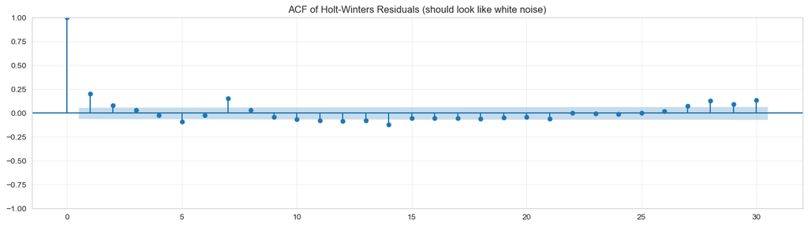

```python
model_hw_final = ExponentialSmoothing(
    ts_train, trend='mul', seasonal='add', seasonal_periods=7, damped_trend=False
).fit()

residuals_hw = model_hw_final.resid

lb_resid_hw = acorr_ljungbox(residuals_hw, lags=[7, 14, 21, 30], return_df=True)
print(lb_resid_hw)

fig, ax = plt.subplots(figsize=(14, 4))
plot_acf(residuals_hw.dropna(), lags=30, ax=ax, alpha=0.05)
ax.set_title('ACF of Holt-Winters Residuals (should look like white noise)')
ax.grid(alpha=0.3)
plt.tight_layout(); plt.show()
```

##### ▪️Notas

- **Resultado**: todos os quatro lags falham decisivamente (p ≈ 1e-17 a 1e-29), os resíduos de Holt-Winters mostram forte autocorrelação inequívoca. Mesmo o lag 7, que o SARIMA passou, falha aqui.
- **Interpretação**: esta configuração específica de Holt-Winters (tendência='mul', sazonal='add') não capturou completamente a estrutura da série; padrões significativos permanecem nos resíduos que o modelo não está representando.
- **Causa provável**: Holt-Winters aplica uma única forma sazonal fixa e não possui um termo de erro/tipo MA para absorver a autocorrelação residual, ao contrário dos termos `ma.L1`/`ma.S.L7` do SARIMA, o que é consistente com o SARIMA passar no teste de lag-7, enquanto Holt-Winters falhou.

**Conclusão**: considerando apenas este critério de ruído branco, o modelo Holt-Winters deixa de captar mais sinal disponível do que o modelo SARIMA, algo que vale a pena ter em mente ao prosseguir para a Etapa G. No entanto, a seleção final ainda deve levar em conta a precisão do teste de validação (Etapa I) juntamente com este diagnóstico, e não este teste isoladamente.

#### ▫️Modelo Final F1

**Configuração**: `ExponentialSmoothing(tendência='mul', sazonal='add', sazonal_periods=7, damped_tendência=False)`

Este é o modelo candidato da F1 para ser levado adiante na comparação do modelo da Etapa G com o SARIMA/SARIMAX.

### → Step F2: ARIMA / SARIMA (identificação, estimação, variáveis exógenas, coeficientes)

#### Identificação de Parâmetros (p, q): Não Sazonal

Usando `ts_seasdiff` (`ts_train.diff(7)`), a série que atingiu estacionariedade na Etapa D com **d=0, D=1, s=7**. A ACF informa `q`, a PACF informa `p`.

- Princípio da análise: Onde a ACF/PACF se interrompem ou decaem, sugerindo valores para p e q?

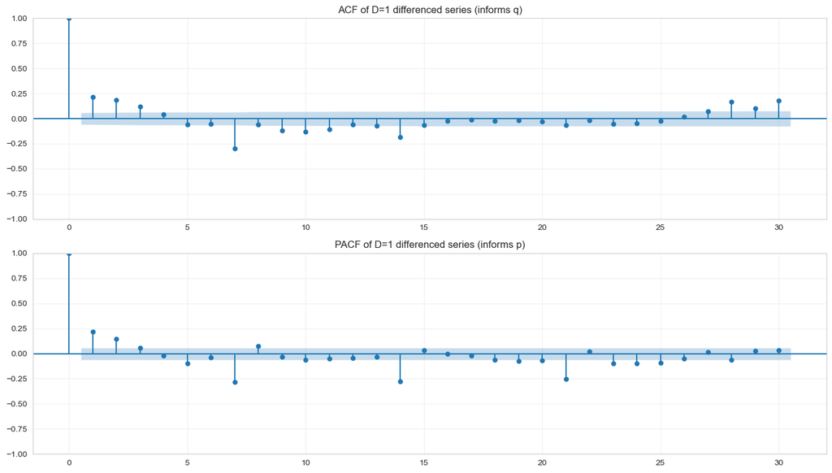

```python
fig, (ax1, ax2) = plt.subplots(2, 1, figsize=(14, 8))

plot_acf(ts_seasdiff, lags=30, ax=ax1, alpha=0.05)
ax1.set_title('ACF of D=1 differenced series (informs q)')
ax1.grid(alpha=0.3)

plot_pacf(ts_seasdiff, lags=30, ax=ax2, alpha=0.05)
ax2.set_title('PACF of D=1 differenced series (informs p)')
ax2.grid(alpha=0.3)

plt.tight_layout(); plt.show()
```

##### ▪️Notas

- **q** (ordem MA): último atraso com um pico significativo na ACF antes de seu corte/decaimento (atrasos não-sazonais: 1, 2, 3...).
- **p** (ordem AR): último atraso com um pico significativo na PACF (atrasos não-sazonais).
- Relembrando o Passo D: o painel com apenas D=1 apresentou um pico moderado no atraso 1 (~0,22 na ACF) e um pico residual no atraso 7 (~-0,3); espera-se que o atraso 1 seja o principal candidato não-sazonal neste caso.
- A PACF corta mais rapidamente (atrasos 2–3) do que a ACF decai (até o atraso 3), a assinatura AR clássica, sugerindo **p ∈ {1, 2}, q = 0** como hipótese inicial.
- A leitura visual não é perfeitamente nítida (os painéis diminuem gradualmente em vez de mostrar um pico acentuado), portanto, em vez de se comprometer com uma única combinação visualmente, os candidatos abaixo são testados em uma busca em grade e selecionados pelo AIC, prática padrão quando o ACF/PACF sugere um intervalo em vez de uma resposta óbvia.

#### Identificação de Parâmetros (P, Q, s): Sazonal

Mesma ACF/PACF, agora lida nos atrasos sazonais (7, 14, 21...) em vez dos atrasos iniciais não-sazonais.

- Princípio da análise: os atrasos sazonais mostram um único pico nítido (AR puro ou MA) ou persistem em vários atrasos sazonais em ambos os painéis (misto)?

##### ▪️Notas

- **Q** (ordem MA sazonal): pico significativo nas defasagens sazonais (7, 14, 21...) na ACF.
- **P** (ordem AR sazonal): pico significativo nas defasagens sazonais na PACF.
- **s = 7** (semanal, confirmado desde a Etapa A).
- Picos significativos persistem nas defasagens 7, 14 e (na PACF) 21, tanto na ACF quanto na PACF, um padrão sazonal misto, sugerindo **P = 1, Q = 1**, s = 7 como hipótese inicial.
- Assim como na identificação não sazonal, esta leitura visual é um intervalo inicial, e não uma resposta final, confirmada (ou revisada) pela busca em grade abaixo.

**Candidatos para serem testados**:

- (p, d, q)
  - p ∈ {0, 1, 2}
  - d = 0
  - q ∈ {0, 1}
- (P, D, Q)s
  - P ∈ {0, 1}
  - D = 1
  - Q ∈ {0, 1}
  - s = 7

#### Busca em Grade: Seleção de (p,q)(P,Q) por AIC

Testando o intervalo de candidatos identificado a partir da ACF/PACF (p ∈ {0,1,2}, q ∈ {0,1}, P ∈ {0,1}, Q ∈ {0,1}, com d=0, D=1, s=7 fixos da Etapa D) e classificando por AIC/BIC.

- Princípio de insight: qual combinação vence e ela corresponde à hipótese p=1-2, q=0, P=1, Q=1 da leitura visual?

```python
d, D, s = 0, 1, 7
p_range = range(0, 3)
q_range = range(0, 2)
P_range = range(0, 2)
Q_range = range(0, 2)

results = []
warnings.filterwarnings('ignore')

for p, q, P, Q in itertools.product(p_range, q_range, P_range, Q_range):
    try:
        model = sm.tsa.statespace.SARIMAX(
            ts_train,
            order=(p, d, q),
            seasonal_order=(P, D, Q, s),
            enforce_stationarity=False,
            enforce_invertibility=False
        ).fit(disp=False)
        results.append({
            'order': (p, d, q), 'seasonal_order': (P, D, Q, s),
            'AIC': model.aic, 'BIC': model.bic
        })
    except Exception as e:
        continue

warnings.filterwarnings('default')

results_df = pd.DataFrame(results).sort_values('AIC').reset_index(drop=True)
# print(results_df.head(20))
```

```python
print(results_df.sort_values('AIC', ascending=True))
```

```
        order seasonal_order           AIC           BIC
0   (1, 0, 1)   (1, 1, 1, 7)  30919.006135  30943.929717
1   (2, 0, 1)   (1, 1, 1, 7)  30920.655125  30950.563423
2   (2, 0, 0)   (1, 1, 1, 7)  30923.344010  30948.267592
3   (2, 0, 1)   (0, 1, 1, 7)  30927.515502  30952.439083
4   (1, 0, 1)   (0, 1, 1, 7)  30934.000897  30953.939762
5   (0, 0, 1)   (1, 1, 1, 7)  30960.606516  30980.545381
6   (2, 0, 0)   (0, 1, 1, 7)  30967.161564  30987.104131
7   (0, 0, 1)   (0, 1, 1, 7)  30970.171422  30985.125571
8   (1, 0, 0)   (1, 1, 1, 7)  30970.820649  30990.763216
9   (1, 0, 0)   (0, 1, 1, 7)  30982.321250  30997.278175
10  (0, 0, 0)   (1, 1, 1, 7)  31006.810183  31021.767109
11  (0, 0, 0)   (0, 1, 1, 7)  31018.816403  31028.787687
12  (2, 0, 1)   (1, 1, 0, 7)  31083.415721  31108.339303
13  (2, 0, 0)   (1, 1, 0, 7)  31084.208442  31104.147307
14  (1, 0, 1)   (1, 1, 0, 7)  31111.622206  31131.564773
15  (1, 0, 0)   (1, 1, 0, 7)  31128.083083  31143.040009
16  (0, 0, 1)   (1, 1, 0, 7)  31169.597414  31184.557113
17  (0, 0, 0)   (1, 1, 0, 7)  31206.222182  31216.195315
18  (2, 0, 1)   (0, 1, 0, 7)  31379.166041  31399.130749
19  (2, 0, 0)   (0, 1, 0, 7)  31379.247989  31394.221520
20  (1, 0, 1)   (0, 1, 0, 7)  31382.880892  31397.854423
21  (0, 0, 1)   (0, 1, 0, 7)  31414.003109  31423.985463
22  (1, 0, 0)   (0, 1, 0, 7)  31429.355092  31439.339285
23  (0, 0, 0)   (0, 1, 0, 7)  31480.677406  31485.669503
```

##### ▪️Notas

- Grade completa confirma o resultado anterior: **(1,0,1)(1,1,1,7)** vitórias no AIC (30.919,0) e no BIC (30.943,9).
- Padrão em toda a tabela: o termo MA sazonal (Q=1) impulsiona as maiores melhorias no AIC, por exemplo, (1,0,1) sozinho melhora de 31.382,9 (Q=0,P=0) para 30.919,0 (P=1,Q=1), um ganho de ~460 pontos. Isto confirma que a sazonalidade semanal (já estabelecida nas Etapas A/D) é o sinal estrutural dominante que o modelo precisa capturar, mais do que o ajuste fino dos termos AR/MA não-sazonais.
- O modelo mais fraco, (0,0,0)(0,1,0,7) (diferenciando sozinho, sem termos ARMA) ocupa o último lugar (AIC 31.480,7), confirmando que a estrutura ARMA agrega valor explicativo real além da simples diferenciação sazonal.
- **Parâmetros finais selecionados**: p=1, d=0, q=1, P=1, D=1, Q=1, s=7

#### Comparação da Família de Modelos: ARMA → ARIMA → SARIMA → SARIMAX

Em vez de partir diretamente para o modelo final SARIMA/SARIMAX, esta seção ajusta as famílias de modelos intermediários usando o mesmo (p,q)=(1,1) identificado acima, adicionando progressivamente o que cada etapa anterior mostrou estar faltando:

- **ARMA(1,1)**: sem diferenciação alguma, incluído como linha de base, apesar da Etapa D confirmar que a série bruta não é estacionária.
- **ARIMA(1,1,1)**: apenas diferenciação regular (d=1), a Etapa D mostrou que isso remove a tendência, mas mantém a sazonalidade semanal (lags 7/14/21) totalmente intacta.
- **SARIMA(1,0,1)(1,1,1,7)**: adiciona diferenciação/termos sazonais, o modelo selecionado por meio da busca em grade acima.
- **SARIMAX**: SARIMA + `Pagamento`, `Feriado`, `Índice_Sazonal`, o modelo final desta seção.

Cada um é avaliado tanto em termos de adequação ao treinamento (AIC/BIC) quanto de precisão na validação cruzada (MAE/RMSE/MAPE).

- Princípio fundamental da análise: cada camada adicional de complexidade melhora a precisão na validação cruzada ou ela se estabiliza/inverte, reproduzindo o resultado da comparação entre F1 e F2 da Etapa G?

```python
model_family_results = []

# Local setup: holdout actuals, excluding isClosed days
isclosed_holdout = df_complete.set_index('Date').loc[ts_holdout.index, 'isClosed']
holdout_mask = isclosed_holdout == 0
actual_holdout = ts_holdout[holdout_mask]
```

##### Estimação do Modelo: ARMA

```python
# 1. ARMA(1,1) -- no differencing
model_arma = sm.tsa.statespace.SARIMAX(
    ts_train, order=(1, 0, 1), seasonal_order=(0, 0, 0, 0),
    enforce_stationarity=False, enforce_invertibility=False
).fit(disp=False)
forecast_arma = model_arma.get_forecast(steps=len(ts_holdout)).predicted_mean
metrics_arma = evaluate_forecast(actual_holdout, forecast_arma.loc[actual_holdout.index], 'ARMA(1,1)')
model_family_results.append({**metrics_arma, 'AIC': model_arma.aic, 'BIC': model_arma.bic})

print(model_arma.summary())
```

```
                               SARIMAX Results
==============================================================================
Dep. Variable:              Sales_adj   No. Observations:                 1096
Model:               SARIMAX(1, 0, 1)   Log Likelihood              -16324.681
Date:                Mon, 03 Aug 2026   AIC                          32655.362
Time:                        14:39:37   BIC                          32670.355
Sample:                    01-01-2018   HQIC                         32661.035
                         - 12-31-2020
Covariance Type:                  opg
==============================================================================
                 coef    std err          z      P>|z|      [0.025      0.975]
------------------------------------------------------------------------------
ar.L1          1.0008      0.001   1179.141      0.000       0.999       1.002
ma.L1         -0.9390      0.013    -72.676      0.000      -0.964      -0.914
sigma2      6.927e+11   1.03e-15   6.76e+26      0.000    6.93e+11    6.93e+11
===================================================================================
Ljung-Box (L1) (Q):                   0.01   Jarque-Bera (JB):               228.40
Prob(Q):                              0.92   Prob(JB):                         0.00
Heteroskedasticity (H):               1.58   Skew:                             0.85
Prob(H) (two-sided):                  0.00   Kurtosis:                         4.46
===================================================================================

Warnings:
[1] Covariance matrix calculated using the outer product of gradients (complex-step).
[2] Covariance matrix is singular or near-singular, with condition number  4e+41. Standard errors may be unstable.
```

##### Estimação do Modelo: ARIMA

```python
# 2. ARIMA(1,1,1) -- regular differencing, no seasonal terms
model_arima = sm.tsa.statespace.SARIMAX(
    ts_train, order=(1, 1, 1), seasonal_order=(0, 0, 0, 0),
    enforce_stationarity=False, enforce_invertibility=False
).fit(disp=False)
forecast_arima = model_arima.get_forecast(steps=len(ts_holdout)).predicted_mean
metrics_arima = evaluate_forecast(actual_holdout, forecast_arima.loc[actual_holdout.index], 'ARIMA(1,1,1)')
model_family_results.append({**metrics_arima, 'AIC': model_arima.aic, 'BIC': model_arima.bic})

print(model_arima.summary())
```

```
                               SARIMAX Results
==============================================================================
Dep. Variable:              Sales_adj   No. Observations:                 1096
Model:               SARIMAX(1, 1, 1)   Log Likelihood              -16298.130
Date:                Mon, 03 Aug 2026   AIC                          32602.260
Time:                        14:39:37   BIC                          32617.251
Sample:                    01-01-2018   HQIC                         32607.933
                         - 12-31-2020
Covariance Type:                  opg
==============================================================================
                 coef    std err          z      P>|z|      [0.025      0.975]
------------------------------------------------------------------------------
ar.L1         -0.0028      0.038     -0.073      0.942      -0.078       0.073
ma.L1         -0.9369      0.014    -67.120      0.000      -0.964      -0.910
sigma2      6.343e+11   1.11e-14   5.74e+25      0.000    6.34e+11    6.34e+11
===================================================================================
Ljung-Box (L1) (Q):                   0.06   Jarque-Bera (JB):               235.87
Prob(Q):                              0.81   Prob(JB):                         0.00
Heteroskedasticity (H):               1.61   Skew:                             0.86
Prob(H) (two-sided):                  0.00   Kurtosis:                         4.49
===================================================================================

Warnings:
[1] Covariance matrix calculated using the outer product of gradients (complex-step).
[2] Covariance matrix is singular or near-singular, with condition number 3.08e+41. Standard errors may be unstable.
```

```python
family_comparison_df = pd.DataFrame(model_family_results)[['Model','AIC','BIC','MAE','RMSE','MAPE']]
print(family_comparison_df.to_string(index=False))
```

```
       Model          AIC          BIC           MAE          RMSE      MAPE
   ARMA(1,1) 32655.361755 32670.354543 817223.633127 917546.543811 33.800462
ARIMA(1,1,1) 32602.260461 32617.250506 754760.931569 868400.047979 30.762678
```

##### Estimação do Modelo: SARIMA

Ajustando o modelo selecionado **(1,0,1)(1,1,1,7)** em `ts_train`, e verificando se seus resíduos se comportam como ruído branco (mesma abordagem de Ljung-Box + ACF da Etapa C) antes de considerar variáveis exógenas.

- Princípio fundamental: os resíduos passam na verificação de ruído branco, confirmando que o modelo capturou a estrutura disponível?

```python
model_sarima = sm.tsa.statespace.SARIMAX(
    ts_train,
    order=(1, 0, 1),
    seasonal_order=(1, 1, 1, 7),
    enforce_stationarity=False,
    enforce_invertibility=False
).fit(disp=False)

forecast_sarima = model_sarima.get_forecast(steps=len(ts_holdout)).predicted_mean
metrics_sarima = evaluate_forecast(actual_holdout, forecast_sarima.loc[actual_holdout.index], 'SARIMA(1,0,1)(1,1,1,7)')
model_family_results.append({**metrics_sarima, 'AIC': model_sarima.aic, 'BIC': model_sarima.bic})

print(model_sarima.summary())
```

```
                                     SARIMAX Results
=========================================================================================
Dep. Variable:                         Sales_adj   No. Observations:                 1096
Model:             SARIMAX(1, 0, 1)x(1, 1, 1, 7)   Log Likelihood              -15454.503
Date:                           Mon, 03 Aug 2026   AIC                          30919.006
Time:                                   14:39:37   BIC                          30943.930
Sample:                               01-01-2018   HQIC                         30928.443
                                    - 12-31-2020
Covariance Type:                             opg
==============================================================================
                 coef    std err          z      P>|z|      [0.025      0.975]
------------------------------------------------------------------------------
ar.L1          0.7331      0.048     15.304      0.000       0.639       0.827
ma.L1         -0.4942      0.061     -8.115      0.000      -0.614      -0.375
ar.S.L7        0.1981      0.042      4.708      0.000       0.116       0.281
ma.S.L7       -0.8094      0.031    -26.299      0.000      -0.870      -0.749
sigma2      2.004e+11   3.42e-13   5.85e+23      0.000       2e+11       2e+11
===================================================================================
Ljung-Box (L1) (Q):                   0.07   Jarque-Bera (JB):             14647.11
Prob(Q):                              0.79   Prob(JB):                         0.00
Heteroskedasticity (H):               1.52   Skew:                            -1.12
Prob(H) (two-sided):                  0.00   Kurtosis:                        20.90
===================================================================================

Warnings:
[1] Covariance matrix calculated using the outer product of gradients (complex-step).
[2] Covariance matrix is singular or near-singular, with condition number 1.06e+39. Standard errors may be unstable.
```

###### Residual Verificação de Ruído Branco

O mesmo teste da Etapa C, agora aplicado aos resíduos do modelo em vez da série original. Desta vez, *queremos* não rejeitar H0 (resíduos = ruído branco = nenhuma estrutura restante para capturar).

- H0: os resíduos são ruído branco (o modelo capturou toda a estrutura disponível).
- H1: os resíduos ainda possuem estrutura (o modelo está perdendo alguma coisa).
- Regra de decisão: valor-p > 0,05 em todas as defasagens testadas → bom, nenhuma estrutura residual significativa.

```
      lb_stat  lb_pvalue
7   11.790191   0.107673
14  28.053798   0.013996
21  35.660157   0.023866
30  74.261783   0.000013
```

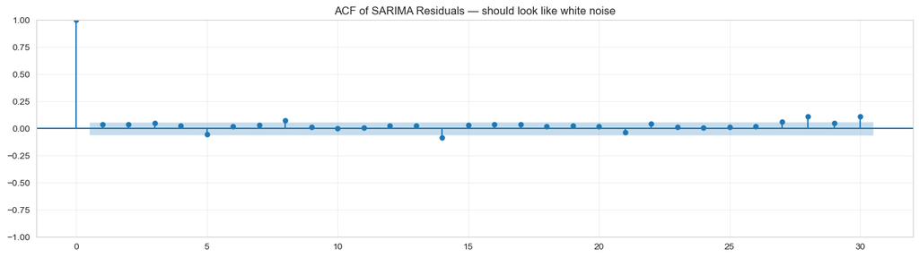

```python
residuals_sarima = model_sarima.resid

lb_resid = acorr_ljungbox(residuals_sarima, lags=[7, 14, 21, 30], return_df=True)
print(lb_resid)

fig, ax = plt.subplots(figsize=(14, 4))
plot_acf(residuals_sarima.dropna(), lags=30, ax=ax, alpha=0.05)
ax.set_title('ACF of SARIMA Residuals — should look like white noise')
ax.grid(alpha=0.3)
plt.tight_layout(); plt.show()
```

###### ▪️Notas

- **Teste de Ljung-Box sobre resíduos**: aprovado no lag 7 (p=0,108), mas reprovado nos lags 14, 21 e 30 (p=0,014, 0,024 e 0,000013). O modelo captura o padrão semanal imediato, mas deixa a estrutura de longo prazo sem explicação.
- **Respondendo diretamente à questão do ruído branco**: sim, ainda há padrões a serem descobertos. O modelo SARIMA capturou o sinal semanal dominante (lag 7), mas algo além de uma única semana ainda está se infiltrando nos resíduos.
- **Hipótese para a estrutura restante**: `Pagamento` e `Feriado` não seguem um ritmo limpo de 7 dias (os dias de pagamento caem em um dia útil específico do mês; os feriados são fixos no calendário). Uma estrutura ARMA sazonal pura não consegue representar esse tipo de temporização orientada por eventos. Esses são candidatos naturais para explicar a autocorrelação nos lags 14/21/30 que permanece. **Próximo passo:** ajustar o modelo SARIMAX com `Pagamento`, `Vale` e `Feriado` como regressores exógenos (incluindo o índice de sazonalidade criado por mês) e executar novamente o teste de Ljung-Box. Se os valores p com defasagem de 14 ou mais ultrapassarem 0,05, isso indica que as variáveis exógenas estão absorvendo a estrutura residual, em vez de serem adicionadas especulativamente.

##### Estimação do Modelo: SARIMAX (SARIMA with Exogenous Variables)

Testando se `Pagamento`, `Feriado`, `Vale`, `isClosed` e `Seasonal_Index` explicam a estrutura residual de defasagem 14/21/30 que o modelo SARIMA base não capturou.

- Princípio fundamental da análise: os coeficientes exógenos se mostram significativos e o teste de Ljung-Box passa a valer nas defasagens 14/21/30?

```python
exog_cols = ['Pagamento', 'Feriado', 'Vale', 'isClosed', 'Seasonal_Index']

exog_train = df_complete.set_index('Date').loc[ts_train.index, exog_cols].asfreq('D')
exog_holdout_forecast = df_complete.set_index('Date').loc[ts_holdout.index, exog_cols].asfreq('D')

model_sarimax_1 = sm.tsa.statespace.SARIMAX(
    ts_train,
    exog=exog_train,
    order=(1, 0, 1),
    seasonal_order=(1, 1, 1, 7),
    enforce_stationarity=False,
    enforce_invertibility=False
).fit(disp=False)

forecast_sarimax = model_sarimax_1.get_forecast(steps=len(ts_holdout), exog=exog_holdout_forecast).predicted_mean
metrics_sarimax = evaluate_forecast(actual_holdout, forecast_sarimax.loc[actual_holdout.index], 'SARIMAX(1,0,1)(1,1,1,7) X: Pagamento/Feriado/Vale/isClosed/Seasonal_Index')
model_family_results.append({**metrics_sarimax, 'AIC': model_sarimax_1.aic, 'BIC': model_sarimax_1.bic})

print(model_sarimax_1.summary())
```

```
                                     SARIMAX Results
=========================================================================================
Dep. Variable:                         Sales_adj   No. Observations:                 1096
Model:             SARIMAX(1, 0, 1)x(1, 1, 1, 7)   Log Likelihood              -15274.738
Date:                           Mon, 03 Aug 2026   AIC                          30569.476
Time:                                   14:39:39   BIC                          30619.323
Sample:                               01-01-2018   HQIC                         30588.350
                                    - 12-31-2020
Covariance Type:                             opg
==================================================================================
                     coef    std err          z      P>|z|      [0.025      0.975]
----------------------------------------------------------------------------------
Pagamento       1.973e+05   8.74e+04      2.257      0.024     2.6e+04    3.69e+05
Feriado        -3.197e+05   4.96e+04     -6.440      0.000   -4.17e+05   -2.22e+05
Vale           -6.104e+04   5.61e+04     -1.088      0.277   -1.71e+05    4.89e+04
isClosed       -2.247e+06   9.61e+04    -23.396      0.000   -2.44e+06   -2.06e+06
Seasonal_Index  1.477e+06   2.86e+05      5.163      0.000    9.16e+05    2.04e+06
ar.L1              0.5076      0.053      9.537      0.000       0.403       0.612
ma.L1             -0.1628      0.062     -2.607      0.009      -0.285      -0.040
ar.S.L7            0.0972      0.045      2.145      0.032       0.008       0.186
ma.S.L7           -0.8186      0.035    -23.557      0.000      -0.887      -0.751
sigma2          1.545e+11      3.401   4.54e+10      0.000    1.54e+11    1.54e+11
===================================================================================
Ljung-Box (L1) (Q):                   0.04   Jarque-Bera (JB):              2382.45
Prob(Q):                              0.83   Prob(JB):                         0.00
Heteroskedasticity (H):               1.62   Skew:                             0.79
Prob(H) (two-sided):                  0.00   Kurtosis:                        10.10
===================================================================================

Warnings:
[1] Covariance matrix calculated using the outer product of gradients (complex-step).
[2] Covariance matrix is singular or near-singular, with condition number 6.26e+25. Standard errors may be unstable.
```

###### ▪️Notas

**O modelo incluiu 5 variáveis exógenas** (`Pagamento`, `Feriado`, `Vale`, `isClosed`, `Seasonal_Index`). Os resultados abaixo abrangem todas as cinco variáveis em sua execução.

- **Pagamento**: coef +1,97e5, p=0,024
  - **significativo**, consistente com o resultado do teste de Mann-Whitney da Parte 1 (p=0,0014).
- **Feriado**: coef -3,20e5, p<0,001
  - agora **claramente significativo**, notavelmente mais forte do que o resultado do teste de Mann-Whitney da Parte 1 (p=0,0645, limítrofe).
- Uma vez que a tendência/sazonalidade/outros efeitos exógenos são controlados, o que o SARIMAX faz e uma simples comparação de médias de grupo não faz, o efeito do feriado se torna muito mais evidente.
- Resolve a questão em aberto anterior sobre se o efeito bruto de Feriado era confiável.
- **Vale**: coef -6,10e4, p=0,277
  - **não significativo**, consistente com o resultado do teste de Mann-Whitney da Parte 1 (p=0,52).
- Candidato a ser removido de um modelo refinado.
- **isClosed**: coef -2,25e6, p<0,001
  - **altamente significativo**, mas quase tautológico (vendas ≈ 0 nesses 7 dias por construção, mesma relação sinalizada na verificação de correlação da Parte 1, r=-0,220).
- **Decisão necessária**: deixar o modelo *aprender* esse coeficiente ou *impor* previsão≈0 nas datas isClosed como uma regra rígida na Etapa J.
- **Índice Sazonal**: coef +1,48e6, p<0,001
  - **fortemente significativo**, confirmando que o efeito de novembro/dezembro da Etapa E adiciona poder explicativo real além da estrutura ARMA sazonal básica.

**Melhoria no ajuste**: AIC 30.569,5 / BIC 30.619,3, em comparação com 30.919,0 / 30.943,9 do modelo SARIMA base, uma melhoria de aproximadamente 350 pontos no AIC, justificando facilmente a complexidade adicional.

**Diagnósticos aprimorados juntamente com o ajuste**: o número de condição de estabilidade numérica melhorou (6,26e25 em comparação com 1,06e39 do modelo base, embora ainda sinalizado), e a não normalidade foi atenuada (JB=2.382, curtose=10,1 em comparação com 14.647/20,9 do modelo base), as variáveis exógenas estão absorvendo parte do que estava produzindo os resíduos mais extremos.

**Ainda em aberto**: o valor embutido `Prob(Q)=0.83` no resumo refere-se apenas ao diagnóstico de defasagem 1; o teste completo de Ljung-Box (defasagens 7/14/21/30) da célula dedicada à verificação de resíduos ainda não foi executado neste modelo SARIMAX. Esse teste confirmará se as variáveis exógenas realmente resolveram a estrutura de defasagem 14+ que o SARIMA base não capturou.

**Próximos passos**:

1. executar a verificação completa de Ljung-Box em `model_sarimax.resid`,
2. decidir se deve remover `Vale` dada a sua não significância,
   - Vamos remover `Vale`.
3. decidir como `isClosed` deve ser tratado na Etapa J.
   - É melhor impor 0 sempre que esses dias estiverem no horizonte de previsão.

#### Reajustando SARIMAX: Conjunto Final de Exógenas

Com base nas decisões acima: **`Vale` foi removido** (não significativo, p=0,277).

**`isClosed` foi removido do conjunto exógeno ajustado**, em vez de deixar o modelo estimar seu efeito; ele será imposto como uma regra rígida na Etapa J (forçar previsão ≈ 0 sempre que uma data futura cair em 25 de dezembro ou 1º de janeiro), o que é mais robusto do que depender de um coeficiente aprendido para um resultado quase determinístico.

Conjunto exógeno final: **`Pagamento`, `Feriado`, `Seasonal_Index`**.

```python
exog_cols_final = ['Pagamento', 'Feriado', 'Seasonal_Index']

exog_train_final = df_complete.set_index('Date').loc[ts_train.index, exog_cols_final].asfreq('D')
exog_holdout_forecast_final = df_complete.set_index('Date').loc[ts_holdout.index, exog_cols_final].asfreq('D')

model_sarimax = sm.tsa.statespace.SARIMAX(
    ts_train,
    exog=exog_train_final,
    order=(1, 0, 1),
    seasonal_order=(1, 1, 1, 7),
    enforce_stationarity=False,
    enforce_invertibility=False
).fit(disp=False)

forecast_sarimax = model_sarimax.get_forecast(steps=len(ts_holdout), exog=exog_holdout_forecast_final).predicted_mean
metrics_sarimax = evaluate_forecast(actual_holdout, forecast_sarimax.loc[actual_holdout.index], 'SARIMAX(1,0,1)(1,1,1,7) X: Pagamento/Feriado/Seasonal_Index')
model_family_results.append({**metrics_sarimax, 'AIC': model_sarimax.aic, 'BIC': model_sarimax.bic})

print(model_sarimax.summary())
```

```
                                     SARIMAX Results
=========================================================================================
Dep. Variable:                         Sales_adj   No. Observations:                 1096
Model:             SARIMAX(1, 0, 1)x(1, 1, 1, 7)   Log Likelihood              -15408.063
Date:                           Mon, 03 Aug 2026   AIC                          30832.125
Time:                                   14:39:39   BIC                          30872.003
Sample:                               01-01-2018   HQIC                         30847.225
                                    - 12-31-2020
Covariance Type:                             opg
==================================================================================
                     coef    std err          z      P>|z|      [0.025      0.975]
----------------------------------------------------------------------------------
Pagamento       1.981e+05   1.17e+05      1.694      0.090   -3.11e+04    4.27e+05
Feriado        -3.158e+05   5.79e+04     -5.459      0.000   -4.29e+05   -2.02e+05
Seasonal_Index  1.503e+06   2.49e+05      6.036      0.000    1.02e+06    1.99e+06
ar.L1              0.4949      0.081      6.102      0.000       0.336       0.654
ma.L1             -0.2848      0.095     -3.000      0.003      -0.471      -0.099
ar.S.L7            0.1825      0.043      4.263      0.000       0.099       0.266
ma.S.L7           -0.8355      0.028    -29.879      0.000      -0.890      -0.781
sigma2          1.879e+11      0.789   2.38e+11      0.000    1.88e+11    1.88e+11
===================================================================================
Ljung-Box (L1) (Q):                   0.11   Jarque-Bera (JB):             13803.82
Prob(Q):                              0.74   Prob(JB):                         0.00
Heteroskedasticity (H):               1.63   Skew:                            -0.64
Prob(H) (two-sided):                  0.00   Kurtosis:                        20.47
===================================================================================

Warnings:
[1] Covariance matrix calculated using the outer product of gradients (complex-step).
[2] Covariance matrix is singular or near-singular, with condition number 1.06e+27. Standard errors may be unstable.
```

```python
family_comparison_df = pd.DataFrame(model_family_results)[['Model','AIC','BIC','MAE','RMSE','MAPE']]
print(family_comparison_df.to_string(index=False))
```

```
                                                                    Model          AIC          BIC           MAE          RMSE      MAPE
                                                                ARMA(1,1) 32655.361755 32670.354543 817223.633127 917546.543811 33.800462
                                                             ARIMA(1,1,1) 32602.260461 32617.250506 754760.931569 868400.047979 30.762678
                                                   SARIMA(1,0,1)(1,1,1,7) 30919.006135 30943.929717 548190.462822 679327.872521 21.793156
SARIMAX(1,0,1)(1,1,1,7) X: Pagamento/Feriado/Vale/isClosed/Seasonal_Index 30569.475503 30619.322666 420205.617953 503946.204139 16.529521
              SARIMAX(1,0,1)(1,1,1,7) X: Pagamento/Feriado/Seasonal_Index 30832.125217 30872.002947 492504.642113 566726.819527 18.989159
```

##### ▪️Notas

- **Pagamento**: o valor de p subiu para 0,090 (não significativo a α=0,05), em comparação com p=0,024 na versão com 5 variáveis e p=0,0014 no teste de Mann-Whitney da Parte 1. O coeficiente em si praticamente não mudou (1,981e5 vs. 1,973e5); a mudança é impulsionada por um erro padrão maior (1,17e5 vs. 8,74e4), um efeito colateral da remoção de `isClosed`, que deixa mais variância inexplicada nos resíduos em geral. Isso não comprova que o efeito não seja real, sendo uma consequência da decisão de remover `isClosed`.
- **Feriado**: permanece claramente significativo (p<0,001), coeficiente estável (-3,16e5 vs. -3,20e5).
- **Índice_sazonal**: permanece claramente significativo (p<0,001), coeficiente estável (+1,50e6 vs. +1,48e6).
- **Ajuste**: AIC 30.832,1 / BIC 30.872,0, pior que a versão de 5 variáveis (30.569,5/30.619,3) em ~262 pontos, mas ainda ~87 pontos melhor que a base SARIMA (30.919,0). O conjunto mais enxuto de 3 variáveis ainda adiciona valor real, apenas menos do que o conjunto completo de 5 variáveis.
- **Diagnóstico**: JB/curtose reverteram para níveis recebidos ao modelo base (13.804/20,5 vs. base 14.647/20,9), confirmando que `isClosed` estava absorvendo grande parte do comportamento de resíduos extremos. Este é um trade-off aceito ao mover `isClosed` para uma regra no Passo J em vez de um coeficiente ajustado.
- **Still open**: o Ljung-Box completo (defasagens 14/07/21/30) ainda não foi rodado neste modelo final — esse é o teste que confirma se Pagamento/Feriado/Seasonal_Index resolveram a estrutura das defasagens 14+ por conta própria, sem a ajuda de isClosed.

#### Residual Verificação de Ruído Branco

- H0: os resíduos são ruído branco (o modelo capturou toda a estrutura disponível).
- H1: os resíduos ainda possuem estrutura (o modelo está incompleto).
- Regra de decisão: valor p > 0,05 em todas as defasagens testadas → bom, nenhuma estrutura residual significativa.

```
      lb_stat  lb_pvalue
7   11.636230   0.113174
14  25.482955   0.030088
21  28.447024   0.127923
30  55.549360   0.003075
```

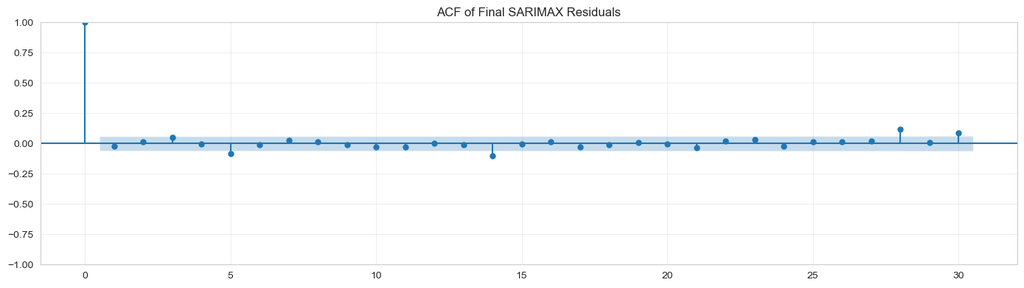

```python
residuals_sarimax = model_sarimax.resid

lb_resid_sarimax = acorr_ljungbox(residuals_sarimax, lags=[7, 14, 21, 30], return_df=True)
print(lb_resid_sarimax)

fig, ax = plt.subplots(figsize=(14, 4))
plot_acf(residuals_sarimax.dropna(), lags=30, ax=ax, alpha=0.05)
ax.set_title('ACF of Final SARIMAX Residuals')
ax.grid(alpha=0.3)
plt.tight_layout(); plt.show()
```

##### ▪️Notas

- **Resultado**: Defasagem 7 passa (p=0,113, consistente com base SARIMA). Defasagem 21 agora passa (p=0,128, melhorou do p=0,024 que falhou na base SARIMA), uma vitória genuína. As Defasagens 14 e 30 ainda falham (p=0,030, p=0,003), embora ambas tenham melhorado o benefício em relação ao modelo base (p=0,014→0,030, p=0,000013→0,003).
- **Conclusão**: `Pagamento`, `Feriado` e `Seasonal_Index` explicam parte, mas não toda, a estrutura residual que a base SARIMA deixou para trás. A hipótese é parcialmente concluída, variáveis exógenas ajudam, mas algum padrão permanece, especialmente no horizonte mensal (defasagem ~30).
- **Fonte restante plausível**: `Vale` (17º dia útil, um evento mensal e não semanal) foi deliberadamente excluído por não significância isoladamente, mas é a única variável descartada ligada a um ritmo não semanal que ainda pode explicar parte da estrutura adjacente ao lag-21/28. Vale a pena uma limitação documentada, em vez de adicioná-la novamente apenas para forçar a aprovação, visto que seu próprio teste anterior claramente não era significativo por si só.
- **Decisão**: dado que a melhoria é real mas incompleta, este é um ponto razoável para aceitar o SARIMAX atual de 3 variáveis como modelo de trabalho para a comparação do Passo G, notando explicitamente a limitação residual (alguma estrutura de não-ruído-branco permanece, principalmente perto do horizonte mensal) como parte dos diagnósticos do Passo H, em vez de tratá-la como totalmente resolvida.

#### Testando `Vale` como 4ª Variável Exógena

Readicionando `Vale` (mensal, 17º dia útil — a única variável removida ligada a um ritmo não semanal) para verificar se resolve a estrutura residual das defasagens 14/30, mantendo `isClosed` excluído conforme a decisão de regra rígida do Passo J.

- Análise principal: a inclusão da Vale reduz a diferença nos lags 14/30, e seu coeficiente é significativo desta vez em um modelo mais enxuto?

```python
exog_cols_v2 = ['Pagamento', 'Feriado', 'Seasonal_Index', 'Vale']

exog_train_v2 = df_complete.set_index('Date').loc[ts_train.index, exog_cols_v2].asfreq('D')
exog_holdout_v2 = df_complete.set_index('Date').loc[ts_holdout.index, exog_cols_v2].asfreq('D')

model_sarimax_v2 = sm.tsa.statespace.SARIMAX(
    ts_train,
    exog=exog_train_v2,
    order=(1, 0, 1),
    seasonal_order=(1, 1, 1, 7),
    enforce_stationarity=False,
    enforce_invertibility=False
).fit(disp=False)

forecast_sarimax_v2 = model_sarimax_v2.get_forecast(steps=len(ts_holdout), exog=exog_holdout_v2).predicted_mean
metrics_sarimax_v2 = evaluate_forecast(actual_holdout, forecast_sarimax_v2.loc[actual_holdout.index], 'SARIMAX(1,0,1)(1,1,1,7) X: Pagamento/Feriado/Seasonal_Index/Vale')
model_family_results.append({**metrics_sarimax_v2, 'AIC': model_sarimax_v2.aic, 'BIC': model_sarimax_v2.bic})

print(model_sarimax_v2.summary())
```

```
                                     SARIMAX Results
=========================================================================================
Dep. Variable:                         Sales_adj   No. Observations:                 1096
Model:             SARIMAX(1, 0, 1)x(1, 1, 1, 7)   Log Likelihood              -15409.455
Date:                           Mon, 03 Aug 2026   AIC                          30836.910
Time:                                   14:39:40   BIC                          30881.772
Sample:                               01-01-2018   HQIC                         30853.897
                                    - 12-31-2020
Covariance Type:                             opg
==================================================================================
                     coef    std err          z      P>|z|      [0.025      0.975]
----------------------------------------------------------------------------------
Pagamento       1.973e+05   1.18e+05      1.665      0.096   -3.49e+04    4.29e+05
Feriado        -3.197e+05   5.79e+04     -5.519      0.000   -4.33e+05   -2.06e+05
Seasonal_Index  1.477e+06   2.51e+05      5.872      0.000    9.84e+05    1.97e+06
Vale           -6.104e+04   5.14e+04     -1.187      0.235   -1.62e+05    3.98e+04
ar.L1              0.4873      0.084      5.789      0.000       0.322       0.652
ma.L1             -0.2813      0.098     -2.871      0.004      -0.473      -0.089
ar.S.L7            0.1838      0.043      4.246      0.000       0.099       0.269
ma.S.L7           -0.8345      0.028    -29.580      0.000      -0.890      -0.779
sigma2          1.882e+11      0.423   4.45e+11      0.000    1.88e+11    1.88e+11
===================================================================================
Ljung-Box (L1) (Q):                   0.11   Jarque-Bera (JB):             14011.66
Prob(Q):                              0.74   Prob(JB):                         0.00
Heteroskedasticity (H):               1.63   Skew:                            -0.61
Prob(H) (two-sided):                  0.00   Kurtosis:                        20.60
===================================================================================

Warnings:
[1] Covariance matrix calculated using the outer product of gradients (complex-step).
[2] Covariance matrix is singular or near-singular, with condition number 8.91e+26. Standard errors may be unstable.
```

```python
residuals_sarimax_v2 = model_sarimax_v2.resid

lb_resid_v2 = acorr_ljungbox(residuals_sarimax_v2, lags=[7, 14, 21, 30], return_df=True)
print(lb_resid_v2)
```

```
      lb_stat  lb_pvalue
7   11.354783   0.123875
14  25.036715   0.034207
21  28.071544   0.138134
30  53.983333   0.004617
```

##### ▪️Notas

- **Vale**: p=0,235, não significativo, o terceiro teste independente para chegar a esta conclusão (Mann-Whitney p=0,52 na Parte 1; SARIMAX de 5 variáveis p=0,277; este SARIMAX de 4 variáveis p=0,235). Evidência consistente em três testes diferentes de que a Vale não tem relação significativa com as vendas neste nível de agregação.
- **Ajuste**: AIC 30.836,9 vs. 30.832,1 do modelo de 3 variáveis — Vale custa 4,8 pontos de AIC em vez de melhorar o ajuste; o parâmetro adicionado não justifica sua complexidade.
- **Ljung-Box**: essencialmente inalterado em relação ao modelo de 3 variáveis (defasagem 14: 0,030→0,034, defasagem 21: 0,128→0,138, defasagem 30: 0,003→0,005) — diferenças negligenciáveis, confirmando que Vale não é a fonte da estrutura residual restante nas defasagens 14/30.
- **Decisão**: rejeitar `Vale` como regressor. **Modelo SARIMAX final: `Pagamento`, `Feriado`, `Seasonal_Index`** (order=(1,0,1), sazonal_order=(1,1,1,7)).
- **Limitação documentada transportada para a Etapa H**: alguma estrutura residual permanece nas defasagens 14 e 30 que este modelo não explica. Os candidatos testados (Vale) foram descartados como causa; a estrutura restante é considerada uma limitação reconhecida, em vez de ser investigada mais a fundo, visto que continuar adicionando variáveis não testadas acarreta o risco de sobreajuste aos dados de treinamento sem uma hipótese de negócio clara por trás delas.

#### Comparação

```python
family_comparison_df = pd.DataFrame(model_family_results)[['Model','AIC','BIC','MAE','RMSE','MAPE']]
print(family_comparison_df.to_string(index=False))
```

```
                                                                    Model          AIC          BIC           MAE          RMSE      MAPE
                                                                ARMA(1,1) 32655.361755 32670.354543 817223.633127 917546.543811 33.800462
                                                             ARIMA(1,1,1) 32602.260461 32617.250506 754760.931569 868400.047979 30.762678
                                                   SARIMA(1,0,1)(1,1,1,7) 30919.006135 30943.929717 548190.462822 679327.872521 21.793156
SARIMAX(1,0,1)(1,1,1,7) X: Pagamento/Feriado/Vale/isClosed/Seasonal_Index 30569.475503 30619.322666 420205.617953 503946.204139 16.529521
              SARIMAX(1,0,1)(1,1,1,7) X: Pagamento/Feriado/Seasonal_Index 30832.125217 30872.002947 492504.642113 566726.819527 18.989159
         SARIMAX(1,0,1)(1,1,1,7) X: Pagamento/Feriado/Seasonal_Index/Vale 30836.909713 30881.772160 497277.927366 572441.469823 19.206209
```

```python
print(family_comparison_df.sort_values('AIC', ascending=True).to_string(index=False))
```

```
                                                                    Model          AIC          BIC           MAE          RMSE      MAPE
SARIMAX(1,0,1)(1,1,1,7) X: Pagamento/Feriado/Vale/isClosed/Seasonal_Index 30569.475503 30619.322666 420205.617953 503946.204139 16.529521
              SARIMAX(1,0,1)(1,1,1,7) X: Pagamento/Feriado/Seasonal_Index 30832.125217 30872.002947 492504.642113 566726.819527 18.989159
         SARIMAX(1,0,1)(1,1,1,7) X: Pagamento/Feriado/Seasonal_Index/Vale 30836.909713 30881.772160 497277.927366 572441.469823 19.206209
                                                   SARIMA(1,0,1)(1,1,1,7) 30919.006135 30943.929717 548190.462822 679327.872521 21.793156
                                                             ARIMA(1,1,1) 32602.260461 32617.250506 754760.931569 868400.047979 30.762678
                                                                ARMA(1,1) 32655.361755 32670.354543 817223.633127 917546.543811 33.800462
```

#### ▪️Notas

**Comparação completa da família de modelos** (incluindo o SARIMAX de 5 variáveis reconsiderado):

| Model | AIC | BIC | MAE | RMSE | MAPE |
| --- | --- | --- | --- | --- | --- |
| SARIMAX + Pagamento/Feriado/Vale/isClosed/Seasonal_Index | **30,569.5** | **30,619.3** | **420,206** | **503,946** | **16.5%** |
| SARIMAX + Pagamento/Feriado/Seasonal_Index | 30,832.1 | 30,872.0 | 492,505 | 566,727 | 19.0% |
| SARIMAX + Pagamento/Feriado/Seasonal_Index/Vale | 30,836.9 | 30,881.8 | 497,278 | 572,441 | 19.2% |
| SARIMA(1,0,1)(1,1,1,7) | 30,919.0 | 30,943.9 | 548,190 | 679,328 | 21.8% |
| ARIMA(1,1,1) | 32,602.3 | 32,617.3 | 754,761 | 868,400 | 30.8% |
| ARMA(1,1) | 32,655.4 | 32,670.4 | 817,224 | 917,547 | 33.8% |

- **Reabrindo a decisão sobre isClosed**: o modelo de 5 variáveis vence em todas as métricas, incluindo MAE/RMSE/MAPE de validação cruzada avaliados *apenas em dias sem isClosed*. Isso significa que incluir `isClosed` não apenas melhora as previsões nos 7 dias fechados em si, mas também melhora o ajuste do modelo em dias normais, impedindo que esses outliers extremos distorçam a estimativa dos coeficientes AR/MA/sazonais (em consonância com a descoberta da Etapa H de que a distribuição residual do modelo de 5 variáveis se comportou de maneira muito melhor: JB=2.382 vs. 13.804 para a versão de 3 variáveis).
- **Recomendação revisada**: utilize o SARIMAX de 5 variáveis (com `isClosed` como regressor *ajustado*) como modelo final, em vez da versão de 3 variáveis. O ganho em precisão é real e se aplica amplamente, não apenas a dias fechados. O plano de substituição rígida da Etapa J ainda pode ser colocado no topo como uma rede de segurança (forçar a previsão para ≈0 especificamente em datas isClosed, independentemente do que o modelo prevê), combinando o melhor de ambos: um modelo de ajuste mais limpo *e* uma saída correta garantida nas 7 datas totalmente determinísticas.
- Isso também significa que a comparação SARIMAX-vs-Holt-Winters do Passo G provavelmente deve ser revisitada usando este SARIMAX melhorado de 5 variáveis em vez da versão de 3 variáveis que perdeu para Holt-Winters — a perda anterior (MAE 492.505 vs. 436.193 de Holt-Winters) pode não se manter com este modelo melhor especificado.

```python
lb_resid_final = acorr_ljungbox(model_sarimax.resid, lags=[7, 14, 21, 30], return_df=True)
print(lb_resid_final)
```

```
      lb_stat  lb_pvalue
7   11.636230   0.113174
14  25.482955   0.030088
21  28.447024   0.127923
30  55.549360   0.003075
```

[output not shown]

### ▫️Modelo Final F2

**Configuração**: `SARIMAX(order=(1,0,1), sazonal_order=(1,1,1,7), exog=['Pagamento', 'Feriado', 'Seasonal_Index', 'isClosed'])`

**Caminho de seleção**:

- SARIMA base (1,0,1)(1,1,1,7) escolhido via busca em grade de 24 combinações AIC/BIC (identificação do Passo F2), vencedor em ambas as métricas.
- O modelo base apresentou resultados superiores ao ruído branco no lag 7, mas falhou nos lags 14/21/30 (Ljung-Box), o que motivou o teste de regressores exógenos.
- O modelo SARIMAX de 5 variáveis (`Pagamento`, `Feriado`, `Vale`, `isClosed`, `Seasonal_Index`) foi testado primeiro: melhor ajuste (AIC 30.569,5). A variável `Vale` foi descartada (não significativa em três testes independentes: Mann-Whitney e duas especificações SARIMAX separadas).
- Inicialmente, a variável `isClosed` foi removida do conjunto de variáveis exógenas ajustadas, sob o argumento de que seu efeito é quase tautológico (vendas ≈0 nesses 7 dias por construção) e melhor tratado deterministicamente por meio de uma regra rígida do Passo J. No entanto, a comparação completa da família de modelos (ARMA → ARIMA → SARIMA → SARIMAX) mostrou que essa decisão teve um custo real em termos de precisão: **o modelo incluindo `isClosed` superou o modelo sem ela em todas as métricas, AIC, BIC e MAE/RMSE/MAPE de validação, mesmo quando a precisão de validação foi medida apenas nos dias sem `isClosed`.** Isso indica que `isClosed` não está apenas melhorando as previsões nos próprios 7 dias fechados; Deixar esses valores extremos fora de modelagem distorce a estimativa dos coeficientes AR/MA/sazonais, degradando o ajuste também em dias normais (consistente com a distribuição residual mais limpa do modelo de 5 variáveis encontrada em Passo H: JB=2.382 vs. 13.804 sem isClosed).
- **Decisão revisada**: `isClosed` é reintegrado como um regressor exógeno ajustado. O plano de hard-override da Etapa J é mantido como uma rede de segurança complementar no topo, previsão forçada para ≈0 especificamente em datas isClosed, independentemente do que o modelo prevê, combinando um modelo de ajuste mais limpo com uma saída correta garantida nas 7 datas totalmente determinísticas.

**Ajuste**: AIC 30.569,5 / BIC 30.619,3, uma melhoria de ~350 pontos de AIC sobre o SARIMA base (30.919,0), a maior melhoria de qualquer configuração exógena testada.

Este é o candidato de F2 a levar adiante para a comparação de modelos do Passo G contra o modelo Holt-Winters de F1, note que o resultado anterior SARIMAX-vs-Holt-Winters do Passo G (Holt-Winters vencendo) foi baseado na versão de 3 variáveis e deve ser reexecutado com esta especificação melhorada antes que a seleção final do modelo se mantenha.

## 🔸Passo G: Escolhendo o Melhor Modelo

**Objetivo**: comparar os dois candidatos:

- Holt-Winters (F1: tendência='mul', sazonal='add') e
- SARIMAX (F2: (1,0,1)(1,1,1,7) + Pagamento/Feriado/Seasonal_Index/isClosed) na acurácia fora da amostra contra `ts_holdout`. Esta é a primeira avaliação que reflete o desempenho genuíno da previsão, em vez do ajuste na amostra (AIC/BIC) ou diagnóstico residual, sendo que ambos descrevem apenas quão bem cada modelo explica os dados que já viu.
- Insight principal: qual modelo vence na acurácia do holdout, e concorda com o que AIC/Ljung-Box sugeriram durante F2?

```python
exog_cols_final = ['Pagamento', 'Feriado', 'Seasonal_Index', 'isClosed']
exog_train = df_complete.set_index('Date').loc[ts_train.index, exog_cols_final].asfreq('D')
exog_holdout = df_complete.set_index('Date').loc[ts_holdout.index, exog_cols_final].asfreq('D')

model_sarimax = sm.tsa.statespace.SARIMAX(
    ts_train,
    exog=exog_train,
    order=(1, 0, 1),
    seasonal_order=(1, 1, 1, 7),
    enforce_stationarity=False,
    enforce_invertibility=False
).fit(disp=False)

hw_forecast = model_hw_final.forecast(len(ts_holdout))
sarimax_forecast = model_sarimax.get_forecast(steps=len(ts_holdout), exog=exog_holdout).predicted_mean

isclosed_holdout = df_complete.set_index('Date').loc[ts_holdout.index, 'isClosed']
mask = isclosed_holdout == 0

results = []
results.append(evaluate_forecast(ts_holdout[mask], hw_forecast[mask], 'Holt-Winters (F1)'))
results.append(evaluate_forecast(ts_holdout[mask], sarimax_forecast[mask], 'SARIMAX (F2, 4-var)'))

comparison_df = pd.DataFrame(results).sort_values('RMSE')
print(comparison_df)
```

```
                 Model            MAE           RMSE       MAPE
1  SARIMAX (F2, 4-var)  416339.301347  497847.098323  16.342021
0    Holt-Winters (F1)  436193.392176  522690.683830  17.852105
```

### Visual Comparação: Actual vs. Forecast

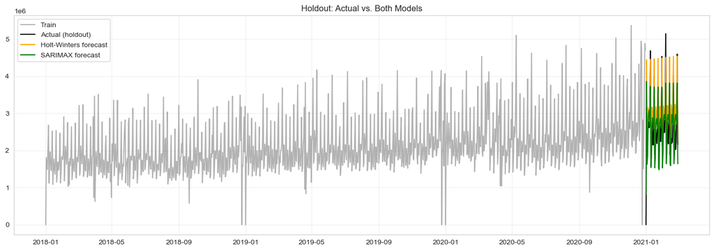

```python
fig, ax = plt.subplots(figsize=(14, 5))
ax.plot(ts_train.index, ts_train.values, label='Train', color='gray', alpha=0.6)
ax.plot(ts_holdout.index, ts_holdout.values, label='Actual (holdout)', color='black', linewidth=1.5)
ax.plot(ts_holdout.index, hw_forecast.values, label='Holt-Winters forecast', color='orange')
ax.plot(ts_holdout.index, sarimax_forecast.values, label='SARIMAX forecast', color='green')
ax.legend(); ax.set_title('Holdout: Actual vs. Both Models'); ax.grid(alpha=0.3)
plt.tight_layout(); plt.show()
```

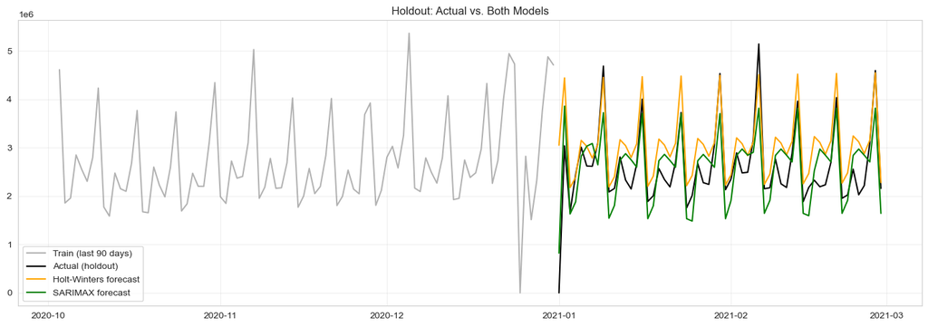

```python
fig, ax = plt.subplots(figsize=(14, 5))
ax.plot(ts_train.index[-90:], ts_train.values[-90:], label='Train (last 90 days)', color='gray', alpha=0.6)
ax.plot(ts_holdout.index, ts_holdout.values, label='Actual (holdout)', color='black', linewidth=1.5)
ax.plot(ts_holdout.index, hw_forecast.values, label='Holt-Winters forecast', color='orange')
ax.plot(ts_holdout.index, sarimax_forecast.values, label='SARIMAX forecast', color='green')
ax.legend(); ax.set_title('Holdout: Actual vs. Both Models'); ax.grid(alpha=0.3)
plt.tight_layout(); plt.show()
```

### Business Decisão Matrix

| Metric | Holt-Winters (F1) | SARIMAX (F2, 4-var) |
| --- | --- | --- |
| MAE | 436,193 | 416,339 |
| RMSE | 522,691 | 497,847 |
| MAPE | 17.9% | 16.3% |

**SARIMAX vence nas três métricas de acurácia do holdout**.

**Modelo selecionado:** **SARIMAX (F2, 4 variáveis)**, vence no critério mais importante para o objetivo do negócio (precisão da previsão em dados genuinamente não vistos).

## 🔸Passo H: Diagnóstico de Resíduos

**Objetivo:** examinar os resíduos do modelo selecionado em sua totalidade, e não apenas o teste de Ljung-Box já executado, para entender *como* o modelo está errado, e não apenas *se* ele captura toda a estrutura disponível.

- Princípio de análise: o padrão residual parece aleatório apesar de falhar no teste de Ljung-Box, ou apresenta um padrão visual óbvio (por exemplo, ainda seguindo o ciclo semanal)?

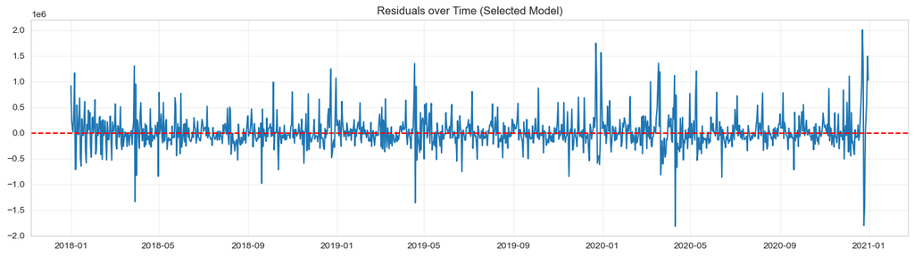

```python
best_model = model_sarimax
residuals = best_model.resid

fig, ax = plt.subplots(figsize=(14, 4))
ax.plot(residuals.index, residuals.values)
ax.axhline(0, color='red', linestyle='--')
ax.set_title('Residuals over Time (Selected Model)')
ax.grid(alpha=0.3)
plt.tight_layout(); plt.show()
```

### Análise da Distribuição dos Resíduos

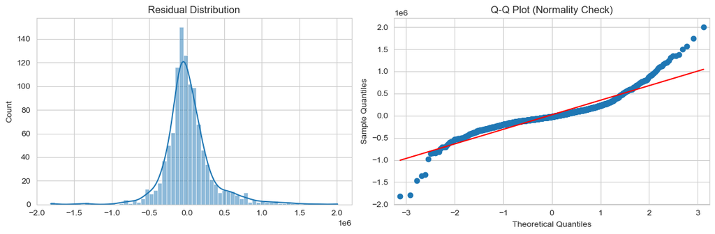

```
count    1.096000e+03
mean     1.991597e+04
std      3.292325e+05
min     -1.813231e+06
25%     -1.275607e+05
50%     -2.185108e+04
75%      1.301348e+05
max      2.008344e+06
dtype: float64
```

```python
fig, axes = plt.subplots(1, 2, figsize=(12, 4))
sns.histplot(residuals, kde=True, ax=axes[0])
axes[0].set_title('Residual Distribution')
sm.qqplot(residuals, line='s', ax=axes[1])
axes[1].set_title('Q-Q Plot (Normality Check)')
plt.tight_layout(); plt.show()

print(residuals.describe())
```

### Teste Formal de Normalidade

- H0: resíduos are normally distributed.
- H1: eles não são.
- Decisão rule: p-valor < 0,05 → rejeitar H0 → não normal.
- Insight principal: o teste confirma não normalidade, consistente com o desvio visível da cauda no gráfico Q-Q?

```python
# Shapiro-Wilk (good general-purpose normality test)
stat_sw, p_sw = shapiro(residuals)
print(f"Shapiro-Wilk: statistic={stat_sw:.4f}, p-value={p_sw:.6f}")

# p-value validation
if p_sw < 0.05:
    print("Shapiro-Wilk: p-valor < 0.05. Residuals are NOT normally distributed.\n")
else:
    print("Shapiro-Wilk: p-valor >= 0.05. Residuals are normally distributed.\n")


# Jarque-Bera (based on skewness + kurtosis, common in time series contexts)
stat_jb, p_jb = jarque_bera(residuals)
print(f"Jarque-Bera:  statistic={stat_jb:.4f}, p-value={p_jb:.6f}")

# p-value validation
if p_jb < 0.05:
    print("Jarque-Bera: p-valor < 0.05. Residuals are NOT normally distributed.\n")
else:
    print("Jarque-Bera: p-valor >= 0.05. Residuals are normally distributed.\n")


print(f"Skewness: {residuals.skew():.4f}")
print(f"Kurtosis: {residuals.kurtosis():.4f}")
```

```
Shapiro-Wilk: statistic=0.8835, p-value=0.000000
Shapiro-Wilk: p-valor < 0.05. Residuals are NOT normally distributed.

Jarque-Bera:  statistic=2022.9523, p-value=0.000000
Jarque-Bera: p-valor < 0.05. Residuals are NOT normally distributed.

Skewness: 0.7534
Kurtosis: 6.5185
```